# Wrangle and Analyze WeRateDogs Twitter Data

Data Wrangling Consists of three steps:

1 - Gathering Data

2 - Assessing Data

3 - Cleaning Data

## Importing all required libraries

```python
import pandas as pd
import numpy as np
import requests
import tweepy
import json
import re
import os
import datetime
import matplotlib.pyplot as plt
import seaborn as sns
```

## Gathering of Data

```python
# Loading the dataset into dataframe (Twitter Archive Data)

df_twitter_archive = pd.read_csv('twitter-archive-enhanced.csv', sep = ',')

# Visualizing first few rows of data in the twitter_archive dataframe

df_twitter_archive.head()
```

|  | tweet_id | in_reply_to_status_id | in_reply_to_user_id | timestamp | source | text | retweeted_status_id | retweeted_status_user_id | retweeted_status_timestamp | expanded_urls | rating_numerator | rating_denominator | name | doggo | floofer | pupper | puppo |
| --- | --- | --- | --- | --- | --- | --- | --- | --- | --- | --- | --- | --- | --- | --- | --- | --- | --- |
| 0 | 892420643555336193 | NaN | NaN | 2017-08-01 16:23:56 +0000 | <a href="http://twitter.com/download/iphone" r... | This is Phineas. He's a mystical boy. Only eve... | NaN | NaN | NaN | https://twitter.com/dog_rates/status/892420643... | 13 | 10 | Phineas | None | None | None | None |
| 1 | 892177421306343426 | NaN | NaN | 2017-08-01 00:17:27 +0000 | <a href="http://twitter.com/download/iphone" r... | This is Tilly. She's just checking pup on you.... | NaN | NaN | NaN | https://twitter.com/dog_rates/status/892177421... | 13 | 10 | Tilly | None | None | None | None |
| 2 | 891815181378084864 | NaN | NaN | 2017-07-31 00:18:03 +0000 | <a href="http://twitter.com/download/iphone" r... | This is Archie. He is a rare Norwegian Pouncin... | NaN | NaN | NaN | https://twitter.com/dog_rates/status/891815181... | 12 | 10 | Archie | None | None | None | None |
| 3 | 891689557279858688 | NaN | NaN | 2017-07-30 15:58:51 +0000 | <a href="http://twitter.com/download/iphone" r... | This is Darla. She commenced a snooze mid meal... | NaN | NaN | NaN | https://twitter.com/dog_rates/status/891689557... | 13 | 10 | Darla | None | None | None | None |
| 4 | 891327558926688256 | NaN | NaN | 2017-07-29 16:00:24 +0000 | <a href="http://twitter.com/download/iphone" r... | This is Franklin. He would like you to stop ca... | NaN | NaN | NaN | https://twitter.com/dog_rates/status/891327558... | 12 | 10 | Franklin | None | None | None | None |

```python
# Loading the tweet image predictions data into the dataframe

specified_url = 'https://d17h27t6h515a5.cloudfront.net/topher/2017/August/599fd2ad_image-predictions/image-predictions.tsv'

# Using requests library downloading the data from the specified url

response = requests.get(specified_url)

with open('image_predictions.tsv','wb') as f:
    f.write(response.content)

df_image_predictions = pd.read_csv('image_predictions.tsv', sep='\t')
```

```python
# Visualizing few rows of data in image_predictions dataframe

df_image_predictions.head()
```

|  | tweet_id | jpg_url | img_num | p1 | p1_conf | p1_dog | p2 | p2_conf | p2_dog | p3 | p3_conf | p3_dog |
| --- | --- | --- | --- | --- | --- | --- | --- | --- | --- | --- | --- | --- |
| 0 | 666020888022790149 | https://pbs.twimg.com/media/CT4udn0WwAA0aMy.jpg | 1 | Welsh_springer_spaniel | 0.465074 | True | collie | 0.156665 | True | Shetland_sheepdog | 0.061428 | True |
| 1 | 666029285002620928 | https://pbs.twimg.com/media/CT42GRgUYAA5iDo.jpg | 1 | redbone | 0.506826 | True | miniature_pinscher | 0.074192 | True | Rhodesian_ridgeback | 0.072010 | True |
| 2 | 666033412701032449 | https://pbs.twimg.com/media/CT4521TWwAEvMyu.jpg | 1 | German_shepherd | 0.596461 | True | malinois | 0.138584 | True | bloodhound | 0.116197 | True |
| 3 | 666044226329800704 | https://pbs.twimg.com/media/CT5Dr8HUEAA-lEu.jpg | 1 | Rhodesian_ridgeback | 0.408143 | True | redbone | 0.360687 | True | miniature_pinscher | 0.222752 | True |
| 4 | 666049248165822465 | https://pbs.twimg.com/media/CT5IQmsXIAAKY4A.jpg | 1 | miniature_pinscher | 0.560311 | True | Rottweiler | 0.243682 | True | Doberman | 0.154629 | True |

```python
# Loading the data from the Twitter API

consumer_key = '14sgZeJMrXaV60Zec1GDqUk16'
consumer_secret = 'shoOIPd4uvxmAwNJkJXU9hjfrgiGOLWmXasQe7lGaxqNvbSgCY'
access_token = '895065053950427136-ECi9lEB1tf62DpxtjcY7jn6KF1k0HXz'
access_secret = 'Xik7uz1fPjbwInMD1TJI8LUdEcxlNSK5kwf3zJVdWA2ro'

auth = tweepy.OAuthHandler(consumer_key, consumer_secret)

auth.set_access_token(access_token, access_secret)

api = tweepy.API(auth)
```

```python
# Dictinory to store tweet data for succesfull api status

twitter_data = {}

# List to store error id's while downloading using api status

error_data = []

count = 0

# Downloading tweet data using tweet id in twitter_archive dataframe

for tweet in df_twitter_archive['tweet_id']:
    count = count + 1
    print("Tweet:" + str(count))
    try:
        api_status = api.get_status(tweet, tweet_mode='extended')._json
        twitter_data[str(tweet)] = api_status
    except Exception as e:
        print("Error for tweet id: " + str(e) + " " + str(tweet))
        error_data.append(tweet)
```

[output not shown]

[output cut: 2315 more lines]

[output not shown]

```python
# Writing Json format data to a text file

with open('tweet_json.txt', 'w', encoding = 'utf-8') as file:
    json.dump(twitter_data, file, indent=4, ensure_ascii=False)
```

```python
# Loding the downloaded text file into an dataframe

df_twitter_data = pd.read_json('tweet_json.txt', orient='index')
```

```python
# Visulaizing few rows of tweets dataset

df_twitter_data.head()
```

|  | contributors | coordinates | created_at | display_text_range | entities | extended_entities | favorite_count | favorited | full_text | geo | ... | quoted_status | quoted_status_id | quoted_status_id_str | quoted_status_permalink | retweet_count | retweeted | retweeted_status | source | truncated | user |
| --- | --- | --- | --- | --- | --- | --- | --- | --- | --- | --- | --- | --- | --- | --- | --- | --- | --- | --- | --- | --- | --- |
| 1998-04-12 22:37:23.555336193 | NaN | NaN | 2017-08-01 16:23:56 | [0, 85] | {'hashtags': [], 'symbols': [], 'user_mentions... | {'media': [{'id': 892420639486877696, 'id_str'... | 38124 | 0 | This is Phineas. He's a mystical boy. Only eve... | NaN | ... | NaN | NaN | NaN | NaN | 8337 | 0 | NaN | <a href="http://twitter.com/download/iphone" r... | 0 | {'id': 4196983835, 'id_str': '4196983835', 'na... |
| 1998-04-10 03:03:41.306343426 | NaN | NaN | 2017-08-01 00:17:27 | [0, 138] | {'hashtags': [], 'symbols': [], 'user_mentions... | {'media': [{'id': 892177413194625024, 'id_str'... | 32703 | 0 | This is Tilly. She's just checking pup on you.... | NaN | ... | NaN | NaN | NaN | NaN | 6162 | 0 | NaN | <a href="http://twitter.com/download/iphone" r... | 0 | {'id': 4196983835, 'id_str': '4196983835', 'na... |
| 1998-04-05 22:26:21.378084864 | NaN | NaN | 2017-07-31 00:18:03 | [0, 121] | {'hashtags': [], 'symbols': [], 'user_mentions... | {'media': [{'id': 891815175371796480, 'id_str'... | 24622 | 0 | This is Archie. He is a rare Norwegian Pouncin... | NaN | ... | NaN | NaN | NaN | NaN | 4078 | 0 | NaN | <a href="http://twitter.com/download/iphone" r... | 0 | {'id': 4196983835, 'id_str': '4196983835', 'na... |
| 1998-04-04 11:32:37.279858688 | NaN | NaN | 2017-07-30 15:58:51 | [0, 79] | {'hashtags': [], 'symbols': [], 'user_mentions... | {'media': [{'id': 891689552724799489, 'id_str'... | 41475 | 0 | This is Darla. She commenced a snooze mid meal... | NaN | ... | NaN | NaN | NaN | NaN | 8484 | 0 | NaN | <a href="http://twitter.com/download/iphone" r... | 0 | {'id': 4196983835, 'id_str': '4196983835', 'na... |
| 1998-03-31 06:59:18.926688256 | NaN | NaN | 2017-07-29 16:00:24 | [0, 138] | {'hashtags': [{'text': 'BarkWeek', 'indices': ... | {'media': [{'id': 891327551943041024, 'id_str'... | 39636 | 0 | This is Franklin. He would like you to stop ca... | NaN | ... | NaN | NaN | NaN | NaN | 9169 | 0 | NaN | <a href="http://twitter.com/download/iphone" r... | 0 | {'id': 4196983835, 'id_str': '4196983835', 'na... |

5 rows × 32 columns

## Summary of Gathering Data

Gathering of required data for our analyis is done in the following pattern.

1 - Loading data into our programming environment using Pandas library (twitter-archive-enchanced.csv file).

2 - Using requests library, downloading an .tsv file from internet and loading it into our programming environment (image-predictions.tsv).

3 - Downloading tweets data, by querying twitter API using Tweepy library and loading it into our programming environment (tweet_json.txt)

# Assessing of Data

Assessing of Data can be performed in two ways.

1 - Visual Assessment

2 - Programatical Assessment

## Visual Assessing of Data

```python
# Printing twitter_archive Dataframe for peforming Visual Assessment

df_twitter_archive
```

|  | tweet_id | in_reply_to_status_id | in_reply_to_user_id | timestamp | source | text | retweeted_status_id | retweeted_status_user_id | retweeted_status_timestamp | expanded_urls | rating_numerator | rating_denominator | name | doggo | floofer | pupper | puppo |
| --- | --- | --- | --- | --- | --- | --- | --- | --- | --- | --- | --- | --- | --- | --- | --- | --- | --- |
| 0 | 892420643555336193 | NaN | NaN | 2017-08-01 16:23:56 +0000 | <a href="http://twitter.com/download/iphone" r... | This is Phineas. He's a mystical boy. Only eve... | NaN | NaN | NaN | https://twitter.com/dog_rates/status/892420643... | 13 | 10 | Phineas | None | None | None | None |
| 1 | 892177421306343426 | NaN | NaN | 2017-08-01 00:17:27 +0000 | <a href="http://twitter.com/download/iphone" r... | This is Tilly. She's just checking pup on you.... | NaN | NaN | NaN | https://twitter.com/dog_rates/status/892177421... | 13 | 10 | Tilly | None | None | None | None |
| 2 | 891815181378084864 | NaN | NaN | 2017-07-31 00:18:03 +0000 | <a href="http://twitter.com/download/iphone" r... | This is Archie. He is a rare Norwegian Pouncin... | NaN | NaN | NaN | https://twitter.com/dog_rates/status/891815181... | 12 | 10 | Archie | None | None | None | None |
| 3 | 891689557279858688 | NaN | NaN | 2017-07-30 15:58:51 +0000 | <a href="http://twitter.com/download/iphone" r... | This is Darla. She commenced a snooze mid meal... | NaN | NaN | NaN | https://twitter.com/dog_rates/status/891689557... | 13 | 10 | Darla | None | None | None | None |
| 4 | 891327558926688256 | NaN | NaN | 2017-07-29 16:00:24 +0000 | <a href="http://twitter.com/download/iphone" r... | This is Franklin. He would like you to stop ca... | NaN | NaN | NaN | https://twitter.com/dog_rates/status/891327558... | 12 | 10 | Franklin | None | None | None | None |
| 5 | 891087950875897856 | NaN | NaN | 2017-07-29 00:08:17 +0000 | <a href="http://twitter.com/download/iphone" r... | Here we have a majestic great white breaching ... | NaN | NaN | NaN | https://twitter.com/dog_rates/status/891087950... | 13 | 10 | None | None | None | None | None |
| 6 | 890971913173991426 | NaN | NaN | 2017-07-28 16:27:12 +0000 | <a href="http://twitter.com/download/iphone" r... | Meet Jax. He enjoys ice cream so much he gets ... | NaN | NaN | NaN | https://gofundme.com/ydvmve-surgery-for-jax,ht... | 13 | 10 | Jax | None | None | None | None |
| 7 | 890729181411237888 | NaN | NaN | 2017-07-28 00:22:40 +0000 | <a href="http://twitter.com/download/iphone" r... | When you watch your owner call another dog a g... | NaN | NaN | NaN | https://twitter.com/dog_rates/status/890729181... | 13 | 10 | None | None | None | None | None |
| 8 | 890609185150312448 | NaN | NaN | 2017-07-27 16:25:51 +0000 | <a href="http://twitter.com/download/iphone" r... | This is Zoey. She doesn't want to be one of th... | NaN | NaN | NaN | https://twitter.com/dog_rates/status/890609185... | 13 | 10 | Zoey | None | None | None | None |
| 9 | 890240255349198849 | NaN | NaN | 2017-07-26 15:59:51 +0000 | <a href="http://twitter.com/download/iphone" r... | This is Cassie. She is a college pup. Studying... | NaN | NaN | NaN | https://twitter.com/dog_rates/status/890240255... | 14 | 10 | Cassie | doggo | None | None | None |
| 10 | 890006608113172480 | NaN | NaN | 2017-07-26 00:31:25 +0000 | <a href="http://twitter.com/download/iphone" r... | This is Koda. He is a South Australian decksha... | NaN | NaN | NaN | https://twitter.com/dog_rates/status/890006608... | 13 | 10 | Koda | None | None | None | None |
| 11 | 889880896479866881 | NaN | NaN | 2017-07-25 16:11:53 +0000 | <a href="http://twitter.com/download/iphone" r... | This is Bruno. He is a service shark. Only get... | NaN | NaN | NaN | https://twitter.com/dog_rates/status/889880896... | 13 | 10 | Bruno | None | None | None | None |
| 12 | 889665388333682689 | NaN | NaN | 2017-07-25 01:55:32 +0000 | <a href="http://twitter.com/download/iphone" r... | Here's a puppo that seems to be on the fence a... | NaN | NaN | NaN | https://twitter.com/dog_rates/status/889665388... | 13 | 10 | None | None | None | None | puppo |
| 13 | 889638837579907072 | NaN | NaN | 2017-07-25 00:10:02 +0000 | <a href="http://twitter.com/download/iphone" r... | This is Ted. He does his best. Sometimes that'... | NaN | NaN | NaN | https://twitter.com/dog_rates/status/889638837... | 12 | 10 | Ted | None | None | None | None |
| 14 | 889531135344209921 | NaN | NaN | 2017-07-24 17:02:04 +0000 | <a href="http://twitter.com/download/iphone" r... | This is Stuart. He's sporting his favorite fan... | NaN | NaN | NaN | https://twitter.com/dog_rates/status/889531135... | 13 | 10 | Stuart | None | None | None | puppo |
| 15 | 889278841981685760 | NaN | NaN | 2017-07-24 00:19:32 +0000 | <a href="http://twitter.com/download/iphone" r... | This is Oliver. You're witnessing one of his m... | NaN | NaN | NaN | https://twitter.com/dog_rates/status/889278841... | 13 | 10 | Oliver | None | None | None | None |
| 16 | 888917238123831296 | NaN | NaN | 2017-07-23 00:22:39 +0000 | <a href="http://twitter.com/download/iphone" r... | This is Jim. He found a fren. Taught him how t... | NaN | NaN | NaN | https://twitter.com/dog_rates/status/888917238... | 12 | 10 | Jim | None | None | None | None |
| 17 | 888804989199671297 | NaN | NaN | 2017-07-22 16:56:37 +0000 | <a href="http://twitter.com/download/iphone" r... | This is Zeke. He has a new stick. Very proud o... | NaN | NaN | NaN | https://twitter.com/dog_rates/status/888804989... | 13 | 10 | Zeke | None | None | None | None |
| 18 | 888554962724278272 | NaN | NaN | 2017-07-22 00:23:06 +0000 | <a href="http://twitter.com/download/iphone" r... | This is Ralphus. He's powering up. Attempting ... | NaN | NaN | NaN | https://twitter.com/dog_rates/status/888554962... | 13 | 10 | Ralphus | None | None | None | None |
| 19 | 888202515573088257 | NaN | NaN | 2017-07-21 01:02:36 +0000 | <a href="http://twitter.com/download/iphone" r... | RT @dog_rates: This is Canela. She attempted s... | 8.874740e+17 | 4.196984e+09 | 2017-07-19 00:47:34 +0000 | https://twitter.com/dog_rates/status/887473957... | 13 | 10 | Canela | None | None | None | None |
| 20 | 888078434458587136 | NaN | NaN | 2017-07-20 16:49:33 +0000 | <a href="http://twitter.com/download/iphone" r... | This is Gerald. He was just told he didn't get... | NaN | NaN | NaN | https://twitter.com/dog_rates/status/888078434... | 12 | 10 | Gerald | None | None | None | None |
| 21 | 887705289381826560 | NaN | NaN | 2017-07-19 16:06:48 +0000 | <a href="http://twitter.com/download/iphone" r... | This is Jeffrey. He has a monopoly on the pool... | NaN | NaN | NaN | https://twitter.com/dog_rates/status/887705289... | 13 | 10 | Jeffrey | None | None | None | None |
| 22 | 887517139158093824 | NaN | NaN | 2017-07-19 03:39:09 +0000 | <a href="http://twitter.com/download/iphone" r... | I've yet to rate a Venezuelan Hover Wiener. Th... | NaN | NaN | NaN | https://twitter.com/dog_rates/status/887517139... | 14 | 10 | such | None | None | None | None |
| 23 | 887473957103951883 | NaN | NaN | 2017-07-19 00:47:34 +0000 | <a href="http://twitter.com/download/iphone" r... | This is Canela. She attempted some fancy porch... | NaN | NaN | NaN | https://twitter.com/dog_rates/status/887473957... | 13 | 10 | Canela | None | None | None | None |
| 24 | 887343217045368832 | NaN | NaN | 2017-07-18 16:08:03 +0000 | <a href="http://twitter.com/download/iphone" r... | You may not have known you needed to see this ... | NaN | NaN | NaN | https://twitter.com/dog_rates/status/887343217... | 13 | 10 | None | None | None | None | None |
| 25 | 887101392804085760 | NaN | NaN | 2017-07-18 00:07:08 +0000 | <a href="http://twitter.com/download/iphone" r... | This... is a Jubilant Antarctic House Bear. We... | NaN | NaN | NaN | https://twitter.com/dog_rates/status/887101392... | 12 | 10 | None | None | None | None | None |
| 26 | 886983233522544640 | NaN | NaN | 2017-07-17 16:17:36 +0000 | <a href="http://twitter.com/download/iphone" r... | This is Maya. She's very shy. Rarely leaves he... | NaN | NaN | NaN | https://twitter.com/dog_rates/status/886983233... | 13 | 10 | Maya | None | None | None | None |
| 27 | 886736880519319552 | NaN | NaN | 2017-07-16 23:58:41 +0000 | <a href="http://twitter.com/download/iphone" r... | This is Mingus. He's a wonderful father to his... | NaN | NaN | NaN | https://www.gofundme.com/mingusneedsus,https:/... | 13 | 10 | Mingus | None | None | None | None |
| 28 | 886680336477933568 | NaN | NaN | 2017-07-16 20:14:00 +0000 | <a href="http://twitter.com/download/iphone" r... | This is Derek. He's late for a dog meeting. 13... | NaN | NaN | NaN | https://twitter.com/dog_rates/status/886680336... | 13 | 10 | Derek | None | None | None | None |
| 29 | 886366144734445568 | NaN | NaN | 2017-07-15 23:25:31 +0000 | <a href="http://twitter.com/download/iphone" r... | This is Roscoe. Another pupper fallen victim t... | NaN | NaN | NaN | https://twitter.com/dog_rates/status/886366144... | 12 | 10 | Roscoe | None | None | pupper | None |
| ... | ... | ... | ... | ... | ... | ... | ... | ... | ... | ... | ... | ... | ... | ... | ... | ... | ... |
| 2326 | 666411507551481857 | NaN | NaN | 2015-11-17 00:24:19 +0000 | <a href="http://twitter.com/download/iphone" r... | This is quite the dog. Gets really excited whe... | NaN | NaN | NaN | https://twitter.com/dog_rates/status/666411507... | 2 | 10 | quite | None | None | None | None |
| 2327 | 666407126856765440 | NaN | NaN | 2015-11-17 00:06:54 +0000 | <a href="http://twitter.com/download/iphone" r... | This is a southern Vesuvius bumblegruff. Can d... | NaN | NaN | NaN | https://twitter.com/dog_rates/status/666407126... | 7 | 10 | a | None | None | None | None |
| 2328 | 666396247373291520 | NaN | NaN | 2015-11-16 23:23:41 +0000 | <a href="http://twitter.com/download/iphone" r... | Oh goodness. A super rare northeast Qdoba kang... | NaN | NaN | NaN | https://twitter.com/dog_rates/status/666396247... | 9 | 10 | None | None | None | None | None |
| 2329 | 666373753744588802 | NaN | NaN | 2015-11-16 21:54:18 +0000 | <a href="http://twitter.com/download/iphone" r... | Those are sunglasses and a jean jacket. 11/10 ... | NaN | NaN | NaN | https://twitter.com/dog_rates/status/666373753... | 11 | 10 | None | None | None | None | None |
| 2330 | 666362758909284353 | NaN | NaN | 2015-11-16 21:10:36 +0000 | <a href="http://twitter.com/download/iphone" r... | Unique dog here. Very small. Lives in containe... | NaN | NaN | NaN | https://twitter.com/dog_rates/status/666362758... | 6 | 10 | None | None | None | None | None |
| 2331 | 666353288456101888 | NaN | NaN | 2015-11-16 20:32:58 +0000 | <a href="http://twitter.com/download/iphone" r... | Here we have a mixed Asiago from the Galápagos... | NaN | NaN | NaN | https://twitter.com/dog_rates/status/666353288... | 8 | 10 | None | None | None | None | None |
| 2332 | 666345417576210432 | NaN | NaN | 2015-11-16 20:01:42 +0000 | <a href="http://twitter.com/download/iphone" r... | Look at this jokester thinking seat belt laws ... | NaN | NaN | NaN | https://twitter.com/dog_rates/status/666345417... | 10 | 10 | None | None | None | None | None |
| 2333 | 666337882303524864 | NaN | NaN | 2015-11-16 19:31:45 +0000 | <a href="http://twitter.com/download/iphone" r... | This is an extremely rare horned Parthenon. No... | NaN | NaN | NaN | https://twitter.com/dog_rates/status/666337882... | 9 | 10 | an | None | None | None | None |
| 2334 | 666293911632134144 | NaN | NaN | 2015-11-16 16:37:02 +0000 | <a href="http://twitter.com/download/iphone" r... | This is a funny dog. Weird toes. Won't come do... | NaN | NaN | NaN | https://twitter.com/dog_rates/status/666293911... | 3 | 10 | a | None | None | None | None |
| 2335 | 666287406224695296 | NaN | NaN | 2015-11-16 16:11:11 +0000 | <a href="http://twitter.com/download/iphone" r... | This is an Albanian 3 1/2 legged Episcopalian... | NaN | NaN | NaN | https://twitter.com/dog_rates/status/666287406... | 1 | 2 | an | None | None | None | None |
| 2336 | 666273097616637952 | NaN | NaN | 2015-11-16 15:14:19 +0000 | <a href="http://twitter.com/download/iphone" r... | Can take selfies 11/10 https://t.co/ws2AMaNwPW | NaN | NaN | NaN | https://twitter.com/dog_rates/status/666273097... | 11 | 10 | None | None | None | None | None |
| 2337 | 666268910803644416 | NaN | NaN | 2015-11-16 14:57:41 +0000 | <a href="http://twitter.com/download/iphone" r... | Very concerned about fellow dog trapped in com... | NaN | NaN | NaN | https://twitter.com/dog_rates/status/666268910... | 10 | 10 | None | None | None | None | None |
| 2338 | 666104133288665088 | NaN | NaN | 2015-11-16 04:02:55 +0000 | <a href="http://twitter.com/download/iphone" r... | Not familiar with this breed. No tail (weird).... | NaN | NaN | NaN | https://twitter.com/dog_rates/status/666104133... | 1 | 10 | None | None | None | None | None |
| 2339 | 666102155909144576 | NaN | NaN | 2015-11-16 03:55:04 +0000 | <a href="http://twitter.com/download/iphone" r... | Oh my. Here you are seeing an Adobe Setter giv... | NaN | NaN | NaN | https://twitter.com/dog_rates/status/666102155... | 11 | 10 | None | None | None | None | None |
| 2340 | 666099513787052032 | NaN | NaN | 2015-11-16 03:44:34 +0000 | <a href="http://twitter.com/download/iphone" r... | Can stand on stump for what seems like a while... | NaN | NaN | NaN | https://twitter.com/dog_rates/status/666099513... | 8 | 10 | None | None | None | None | None |
| 2341 | 666094000022159362 | NaN | NaN | 2015-11-16 03:22:39 +0000 | <a href="http://twitter.com/download/iphone" r... | This appears to be a Mongolian Presbyterian mi... | NaN | NaN | NaN | https://twitter.com/dog_rates/status/666094000... | 9 | 10 | None | None | None | None | None |
| 2342 | 666082916733198337 | NaN | NaN | 2015-11-16 02:38:37 +0000 | <a href="http://twitter.com/download/iphone" r... | Here we have a well-established sunblockerspan... | NaN | NaN | NaN | https://twitter.com/dog_rates/status/666082916... | 6 | 10 | None | None | None | None | None |
| 2343 | 666073100786774016 | NaN | NaN | 2015-11-16 01:59:36 +0000 | <a href="http://twitter.com/download/iphone" r... | Let's hope this flight isn't Malaysian (lol). ... | NaN | NaN | NaN | https://twitter.com/dog_rates/status/666073100... | 10 | 10 | None | None | None | None | None |
| 2344 | 666071193221509120 | NaN | NaN | 2015-11-16 01:52:02 +0000 | <a href="http://twitter.com/download/iphone" r... | Here we have a northern speckled Rhododendron.... | NaN | NaN | NaN | https://twitter.com/dog_rates/status/666071193... | 9 | 10 | None | None | None | None | None |
| 2345 | 666063827256086533 | NaN | NaN | 2015-11-16 01:22:45 +0000 | <a href="http://twitter.com/download/iphone" r... | This is the happiest dog you will ever see. Ve... | NaN | NaN | NaN | https://twitter.com/dog_rates/status/666063827... | 10 | 10 | the | None | None | None | None |
| 2346 | 666058600524156928 | NaN | NaN | 2015-11-16 01:01:59 +0000 | <a href="http://twitter.com/download/iphone" r... | Here is the Rand Paul of retrievers folks! He'... | NaN | NaN | NaN | https://twitter.com/dog_rates/status/666058600... | 8 | 10 | the | None | None | None | None |
| 2347 | 666057090499244032 | NaN | NaN | 2015-11-16 00:55:59 +0000 | <a href="http://twitter.com/download/iphone" r... | My oh my. This is a rare blond Canadian terrie... | NaN | NaN | NaN | https://twitter.com/dog_rates/status/666057090... | 9 | 10 | a | None | None | None | None |
| 2348 | 666055525042405380 | NaN | NaN | 2015-11-16 00:49:46 +0000 | <a href="http://twitter.com/download/iphone" r... | Here is a Siberian heavily armored polar bear ... | NaN | NaN | NaN | https://twitter.com/dog_rates/status/666055525... | 10 | 10 | a | None | None | None | None |
| 2349 | 666051853826850816 | NaN | NaN | 2015-11-16 00:35:11 +0000 | <a href="http://twitter.com/download/iphone" r... | This is an odd dog. Hard on the outside but lo... | NaN | NaN | NaN | https://twitter.com/dog_rates/status/666051853... | 2 | 10 | an | None | None | None | None |
| 2350 | 666050758794694657 | NaN | NaN | 2015-11-16 00:30:50 +0000 | <a href="http://twitter.com/download/iphone" r... | This is a truly beautiful English Wilson Staff... | NaN | NaN | NaN | https://twitter.com/dog_rates/status/666050758... | 10 | 10 | a | None | None | None | None |
| 2351 | 666049248165822465 | NaN | NaN | 2015-11-16 00:24:50 +0000 | <a href="http://twitter.com/download/iphone" r... | Here we have a 1949 1st generation vulpix. Enj... | NaN | NaN | NaN | https://twitter.com/dog_rates/status/666049248... | 5 | 10 | None | None | None | None | None |
| 2352 | 666044226329800704 | NaN | NaN | 2015-11-16 00:04:52 +0000 | <a href="http://twitter.com/download/iphone" r... | This is a purebred Piers Morgan. Loves to Netf... | NaN | NaN | NaN | https://twitter.com/dog_rates/status/666044226... | 6 | 10 | a | None | None | None | None |
| 2353 | 666033412701032449 | NaN | NaN | 2015-11-15 23:21:54 +0000 | <a href="http://twitter.com/download/iphone" r... | Here is a very happy pup. Big fan of well-main... | NaN | NaN | NaN | https://twitter.com/dog_rates/status/666033412... | 9 | 10 | a | None | None | None | None |
| 2354 | 666029285002620928 | NaN | NaN | 2015-11-15 23:05:30 +0000 | <a href="http://twitter.com/download/iphone" r... | This is a western brown Mitsubishi terrier. Up... | NaN | NaN | NaN | https://twitter.com/dog_rates/status/666029285... | 7 | 10 | a | None | None | None | None |
| 2355 | 666020888022790149 | NaN | NaN | 2015-11-15 22:32:08 +0000 | <a href="http://twitter.com/download/iphone" r... | Here we have a Japanese Irish Setter. Lost eye... | NaN | NaN | NaN | https://twitter.com/dog_rates/status/666020888... | 8 | 10 | None | None | None | None | None |

2356 rows × 17 columns

```python
# Points to be noted from Visual Assessing of twitter_archive Dataframe

# 1- There are many NULL values in these columns:
         # in_reply_to_status_id
         # in_reply_to_user_id
         # retweeted_status_id
         # retweeted_status_user_id
         # retweeted_status_timestamp

# More Assessment should be done programatically to identify more issues.
```

```python
# Printing image_predictions Dataframe for performing Visual Assessment

df_image_predictions
```

|  | tweet_id | jpg_url | img_num | p1 | p1_conf | p1_dog | p2 | p2_conf | p2_dog | p3 | p3_conf | p3_dog |
| --- | --- | --- | --- | --- | --- | --- | --- | --- | --- | --- | --- | --- |
| 0 | 666020888022790149 | https://pbs.twimg.com/media/CT4udn0WwAA0aMy.jpg | 1 | Welsh_springer_spaniel | 0.465074 | True | collie | 0.156665 | True | Shetland_sheepdog | 0.061428 | True |
| 1 | 666029285002620928 | https://pbs.twimg.com/media/CT42GRgUYAA5iDo.jpg | 1 | redbone | 0.506826 | True | miniature_pinscher | 0.074192 | True | Rhodesian_ridgeback | 0.072010 | True |
| 2 | 666033412701032449 | https://pbs.twimg.com/media/CT4521TWwAEvMyu.jpg | 1 | German_shepherd | 0.596461 | True | malinois | 0.138584 | True | bloodhound | 0.116197 | True |
| 3 | 666044226329800704 | https://pbs.twimg.com/media/CT5Dr8HUEAA-lEu.jpg | 1 | Rhodesian_ridgeback | 0.408143 | True | redbone | 0.360687 | True | miniature_pinscher | 0.222752 | True |
| 4 | 666049248165822465 | https://pbs.twimg.com/media/CT5IQmsXIAAKY4A.jpg | 1 | miniature_pinscher | 0.560311 | True | Rottweiler | 0.243682 | True | Doberman | 0.154629 | True |
| 5 | 666050758794694657 | https://pbs.twimg.com/media/CT5Jof1WUAEuVxN.jpg | 1 | Bernese_mountain_dog | 0.651137 | True | English_springer | 0.263788 | True | Greater_Swiss_Mountain_dog | 0.016199 | True |
| 6 | 666051853826850816 | https://pbs.twimg.com/media/CT5KoJ1WoAAJash.jpg | 1 | box_turtle | 0.933012 | False | mud_turtle | 0.045885 | False | terrapin | 0.017885 | False |
| 7 | 666055525042405380 | https://pbs.twimg.com/media/CT5N9tpXIAAifs1.jpg | 1 | chow | 0.692517 | True | Tibetan_mastiff | 0.058279 | True | fur_coat | 0.054449 | False |
| 8 | 666057090499244032 | https://pbs.twimg.com/media/CT5PY90WoAAQGLo.jpg | 1 | shopping_cart | 0.962465 | False | shopping_basket | 0.014594 | False | golden_retriever | 0.007959 | True |
| 9 | 666058600524156928 | https://pbs.twimg.com/media/CT5Qw94XAAA_2dP.jpg | 1 | miniature_poodle | 0.201493 | True | komondor | 0.192305 | True | soft-coated_wheaten_terrier | 0.082086 | True |
| 10 | 666063827256086533 | https://pbs.twimg.com/media/CT5Vg_wXIAAXfnj.jpg | 1 | golden_retriever | 0.775930 | True | Tibetan_mastiff | 0.093718 | True | Labrador_retriever | 0.072427 | True |
| 11 | 666071193221509120 | https://pbs.twimg.com/media/CT5cN_3WEAAlOoZ.jpg | 1 | Gordon_setter | 0.503672 | True | Yorkshire_terrier | 0.174201 | True | Pekinese | 0.109454 | True |
| 12 | 666073100786774016 | https://pbs.twimg.com/media/CT5d9DZXAAALcwe.jpg | 1 | Walker_hound | 0.260857 | True | English_foxhound | 0.175382 | True | Ibizan_hound | 0.097471 | True |
| 13 | 666082916733198337 | https://pbs.twimg.com/media/CT5m4VGWEAAtKc8.jpg | 1 | pug | 0.489814 | True | bull_mastiff | 0.404722 | True | French_bulldog | 0.048960 | True |
| 14 | 666094000022159362 | https://pbs.twimg.com/media/CT5w9gUW4AAsBNN.jpg | 1 | bloodhound | 0.195217 | True | German_shepherd | 0.078260 | True | malinois | 0.075628 | True |
| 15 | 666099513787052032 | https://pbs.twimg.com/media/CT51-JJUEAA6hV8.jpg | 1 | Lhasa | 0.582330 | True | Shih-Tzu | 0.166192 | True | Dandie_Dinmont | 0.089688 | True |
| 16 | 666102155909144576 | https://pbs.twimg.com/media/CT54YGiWUAEZnoK.jpg | 1 | English_setter | 0.298617 | True | Newfoundland | 0.149842 | True | borzoi | 0.133649 | True |
| 17 | 666104133288665088 | https://pbs.twimg.com/media/CT56LSZWoAAlJj2.jpg | 1 | hen | 0.965932 | False | cock | 0.033919 | False | partridge | 0.000052 | False |
| 18 | 666268910803644416 | https://pbs.twimg.com/media/CT8QCd1WEAADXws.jpg | 1 | desktop_computer | 0.086502 | False | desk | 0.085547 | False | bookcase | 0.079480 | False |
| 19 | 666273097616637952 | https://pbs.twimg.com/media/CT8T1mtUwAA3aqm.jpg | 1 | Italian_greyhound | 0.176053 | True | toy_terrier | 0.111884 | True | basenji | 0.111152 | True |
| 20 | 666287406224695296 | https://pbs.twimg.com/media/CT8g3BpUEAAuFjg.jpg | 1 | Maltese_dog | 0.857531 | True | toy_poodle | 0.063064 | True | miniature_poodle | 0.025581 | True |
| 21 | 666293911632134144 | https://pbs.twimg.com/media/CT8mx7KW4AEQu8N.jpg | 1 | three-toed_sloth | 0.914671 | False | otter | 0.015250 | False | great_grey_owl | 0.013207 | False |
| 22 | 666337882303524864 | https://pbs.twimg.com/media/CT9OwFIWEAMuRje.jpg | 1 | ox | 0.416669 | False | Newfoundland | 0.278407 | True | groenendael | 0.102643 | True |
| 23 | 666345417576210432 | https://pbs.twimg.com/media/CT9Vn7PWoAA_ZCM.jpg | 1 | golden_retriever | 0.858744 | True | Chesapeake_Bay_retriever | 0.054787 | True | Labrador_retriever | 0.014241 | True |
| 24 | 666353288456101888 | https://pbs.twimg.com/media/CT9cx0tUEAAhNN_.jpg | 1 | malamute | 0.336874 | True | Siberian_husky | 0.147655 | True | Eskimo_dog | 0.093412 | True |
| 25 | 666362758909284353 | https://pbs.twimg.com/media/CT9lXGsUcAAyUFt.jpg | 1 | guinea_pig | 0.996496 | False | skunk | 0.002402 | False | hamster | 0.000461 | False |
| 26 | 666373753744588802 | https://pbs.twimg.com/media/CT9vZEYWUAAlZ05.jpg | 1 | soft-coated_wheaten_terrier | 0.326467 | True | Afghan_hound | 0.259551 | True | briard | 0.206803 | True |
| 27 | 666396247373291520 | https://pbs.twimg.com/media/CT-D2ZHWIAA3gK1.jpg | 1 | Chihuahua | 0.978108 | True | toy_terrier | 0.009397 | True | papillon | 0.004577 | True |
| 28 | 666407126856765440 | https://pbs.twimg.com/media/CT-NvwmW4AAugGZ.jpg | 1 | black-and-tan_coonhound | 0.529139 | True | bloodhound | 0.244220 | True | flat-coated_retriever | 0.173810 | True |
| 29 | 666411507551481857 | https://pbs.twimg.com/media/CT-RugiWIAELEaq.jpg | 1 | coho | 0.404640 | False | barracouta | 0.271485 | False | gar | 0.189945 | False |
| ... | ... | ... | ... | ... | ... | ... | ... | ... | ... | ... | ... | ... |
| 2045 | 886366144734445568 | https://pbs.twimg.com/media/DE0BTnQUwAApKEH.jpg | 1 | French_bulldog | 0.999201 | True | Chihuahua | 0.000361 | True | Boston_bull | 0.000076 | True |
| 2046 | 886680336477933568 | https://pbs.twimg.com/media/DE4fEDzWAAAyHMM.jpg | 1 | convertible | 0.738995 | False | sports_car | 0.139952 | False | car_wheel | 0.044173 | False |
| 2047 | 886736880519319552 | https://pbs.twimg.com/media/DE5Se8FXcAAJFx4.jpg | 1 | kuvasz | 0.309706 | True | Great_Pyrenees | 0.186136 | True | Dandie_Dinmont | 0.086346 | True |
| 2048 | 886983233522544640 | https://pbs.twimg.com/media/DE8yicJW0AAAvBJ.jpg | 2 | Chihuahua | 0.793469 | True | toy_terrier | 0.143528 | True | can_opener | 0.032253 | False |
| 2049 | 887101392804085760 | https://pbs.twimg.com/media/DE-eAq6UwAA-jaE.jpg | 1 | Samoyed | 0.733942 | True | Eskimo_dog | 0.035029 | True | Staffordshire_bullterrier | 0.029705 | True |
| 2050 | 887343217045368832 | https://pbs.twimg.com/ext_tw_video_thumb/88734... | 1 | Mexican_hairless | 0.330741 | True | sea_lion | 0.275645 | False | Weimaraner | 0.134203 | True |
| 2051 | 887473957103951883 | https://pbs.twimg.com/media/DFDw2tyUQAAAFke.jpg | 2 | Pembroke | 0.809197 | True | Rhodesian_ridgeback | 0.054950 | True | beagle | 0.038915 | True |
| 2052 | 887517139158093824 | https://pbs.twimg.com/ext_tw_video_thumb/88751... | 1 | limousine | 0.130432 | False | tow_truck | 0.029175 | False | shopping_cart | 0.026321 | False |
| 2053 | 887705289381826560 | https://pbs.twimg.com/media/DFHDQBbXgAEqY7t.jpg | 1 | basset | 0.821664 | True | redbone | 0.087582 | True | Weimaraner | 0.026236 | True |
| 2054 | 888078434458587136 | https://pbs.twimg.com/media/DFMWn56WsAAkA7B.jpg | 1 | French_bulldog | 0.995026 | True | pug | 0.000932 | True | bull_mastiff | 0.000903 | True |
| 2055 | 888202515573088257 | https://pbs.twimg.com/media/DFDw2tyUQAAAFke.jpg | 2 | Pembroke | 0.809197 | True | Rhodesian_ridgeback | 0.054950 | True | beagle | 0.038915 | True |
| 2056 | 888554962724278272 | https://pbs.twimg.com/media/DFTH_O-UQAACu20.jpg | 3 | Siberian_husky | 0.700377 | True | Eskimo_dog | 0.166511 | True | malamute | 0.111411 | True |
| 2057 | 888804989199671297 | https://pbs.twimg.com/media/DFWra-3VYAA2piG.jpg | 1 | golden_retriever | 0.469760 | True | Labrador_retriever | 0.184172 | True | English_setter | 0.073482 | True |
| 2058 | 888917238123831296 | https://pbs.twimg.com/media/DFYRgsOUQAARGhO.jpg | 1 | golden_retriever | 0.714719 | True | Tibetan_mastiff | 0.120184 | True | Labrador_retriever | 0.105506 | True |
| 2059 | 889278841981685760 | https://pbs.twimg.com/ext_tw_video_thumb/88927... | 1 | whippet | 0.626152 | True | borzoi | 0.194742 | True | Saluki | 0.027351 | True |
| 2060 | 889531135344209921 | https://pbs.twimg.com/media/DFg_2PVW0AEHN3p.jpg | 1 | golden_retriever | 0.953442 | True | Labrador_retriever | 0.013834 | True | redbone | 0.007958 | True |
| 2061 | 889638837579907072 | https://pbs.twimg.com/media/DFihzFfXsAYGDPR.jpg | 1 | French_bulldog | 0.991650 | True | boxer | 0.002129 | True | Staffordshire_bullterrier | 0.001498 | True |
| 2062 | 889665388333682689 | https://pbs.twimg.com/media/DFi579UWsAAatzw.jpg | 1 | Pembroke | 0.966327 | True | Cardigan | 0.027356 | True | basenji | 0.004633 | True |
| 2063 | 889880896479866881 | https://pbs.twimg.com/media/DFl99B1WsAITKsg.jpg | 1 | French_bulldog | 0.377417 | True | Labrador_retriever | 0.151317 | True | muzzle | 0.082981 | False |
| 2064 | 890006608113172480 | https://pbs.twimg.com/media/DFnwSY4WAAAMliS.jpg | 1 | Samoyed | 0.957979 | True | Pomeranian | 0.013884 | True | chow | 0.008167 | True |
| 2065 | 890240255349198849 | https://pbs.twimg.com/media/DFrEyVuW0AAO3t9.jpg | 1 | Pembroke | 0.511319 | True | Cardigan | 0.451038 | True | Chihuahua | 0.029248 | True |
| 2066 | 890609185150312448 | https://pbs.twimg.com/media/DFwUU__XcAEpyXI.jpg | 1 | Irish_terrier | 0.487574 | True | Irish_setter | 0.193054 | True | Chesapeake_Bay_retriever | 0.118184 | True |
| 2067 | 890729181411237888 | https://pbs.twimg.com/media/DFyBahAVwAAhUTd.jpg | 2 | Pomeranian | 0.566142 | True | Eskimo_dog | 0.178406 | True | Pembroke | 0.076507 | True |
| 2068 | 890971913173991426 | https://pbs.twimg.com/media/DF1eOmZXUAALUcq.jpg | 1 | Appenzeller | 0.341703 | True | Border_collie | 0.199287 | True | ice_lolly | 0.193548 | False |
| 2069 | 891087950875897856 | https://pbs.twimg.com/media/DF3HwyEWsAABqE6.jpg | 1 | Chesapeake_Bay_retriever | 0.425595 | True | Irish_terrier | 0.116317 | True | Indian_elephant | 0.076902 | False |
| 2070 | 891327558926688256 | https://pbs.twimg.com/media/DF6hr6BUMAAzZgT.jpg | 2 | basset | 0.555712 | True | English_springer | 0.225770 | True | German_short-haired_pointer | 0.175219 | True |
| 2071 | 891689557279858688 | https://pbs.twimg.com/media/DF_q7IAWsAEuuN8.jpg | 1 | paper_towel | 0.170278 | False | Labrador_retriever | 0.168086 | True | spatula | 0.040836 | False |
| 2072 | 891815181378084864 | https://pbs.twimg.com/media/DGBdLU1WsAANxJ9.jpg | 1 | Chihuahua | 0.716012 | True | malamute | 0.078253 | True | kelpie | 0.031379 | True |
| 2073 | 892177421306343426 | https://pbs.twimg.com/media/DGGmoV4XsAAUL6n.jpg | 1 | Chihuahua | 0.323581 | True | Pekinese | 0.090647 | True | papillon | 0.068957 | True |
| 2074 | 892420643555336193 | https://pbs.twimg.com/media/DGKD1-bXoAAIAUK.jpg | 1 | orange | 0.097049 | False | bagel | 0.085851 | False | banana | 0.076110 | False |

2075 rows × 12 columns

```python
# No major issues were able to find by Visual Assessing of image_predictions dataframe. More Assessment should be done programatically.
```

```python
# Printing tweets Dataframe for performing Visual Assessment

df_twitter_data
```

|  | contributors | coordinates | created_at | display_text_range | entities | extended_entities | favorite_count | favorited | full_text | geo | ... | quoted_status | quoted_status_id | quoted_status_id_str | quoted_status_permalink | retweet_count | retweeted | retweeted_status | source | truncated | user |
| --- | --- | --- | --- | --- | --- | --- | --- | --- | --- | --- | --- | --- | --- | --- | --- | --- | --- | --- | --- | --- | --- |
| 1998-04-12 22:37:23.555336193 | NaN | NaN | 2017-08-01 16:23:56 | [0, 85] | {'hashtags': [], 'symbols': [], 'user_mentions... | {'media': [{'id': 892420639486877696, 'id_str'... | 38124 | 0 | This is Phineas. He's a mystical boy. Only eve... | NaN | ... | NaN | NaN | NaN | NaN | 8337 | 0 | NaN | <a href="http://twitter.com/download/iphone" r... | 0 | {'id': 4196983835, 'id_str': '4196983835', 'na... |
| 1998-04-10 03:03:41.306343426 | NaN | NaN | 2017-08-01 00:17:27 | [0, 138] | {'hashtags': [], 'symbols': [], 'user_mentions... | {'media': [{'id': 892177413194625024, 'id_str'... | 32703 | 0 | This is Tilly. She's just checking pup on you.... | NaN | ... | NaN | NaN | NaN | NaN | 6162 | 0 | NaN | <a href="http://twitter.com/download/iphone" r... | 0 | {'id': 4196983835, 'id_str': '4196983835', 'na... |
| 1998-04-05 22:26:21.378084864 | NaN | NaN | 2017-07-31 00:18:03 | [0, 121] | {'hashtags': [], 'symbols': [], 'user_mentions... | {'media': [{'id': 891815175371796480, 'id_str'... | 24622 | 0 | This is Archie. He is a rare Norwegian Pouncin... | NaN | ... | NaN | NaN | NaN | NaN | 4078 | 0 | NaN | <a href="http://twitter.com/download/iphone" r... | 0 | {'id': 4196983835, 'id_str': '4196983835', 'na... |
| 1998-04-04 11:32:37.279858688 | NaN | NaN | 2017-07-30 15:58:51 | [0, 79] | {'hashtags': [], 'symbols': [], 'user_mentions... | {'media': [{'id': 891689552724799489, 'id_str'... | 41475 | 0 | This is Darla. She commenced a snooze mid meal... | NaN | ... | NaN | NaN | NaN | NaN | 8484 | 0 | NaN | <a href="http://twitter.com/download/iphone" r... | 0 | {'id': 4196983835, 'id_str': '4196983835', 'na... |
| 1998-03-31 06:59:18.926688256 | NaN | NaN | 2017-07-29 16:00:24 | [0, 138] | {'hashtags': [{'text': 'BarkWeek', 'indices': ... | {'media': [{'id': 891327551943041024, 'id_str'... | 39636 | 0 | This is Franklin. He would like you to stop ca... | NaN | ... | NaN | NaN | NaN | NaN | 9169 | 0 | NaN | <a href="http://twitter.com/download/iphone" r... | 0 | {'id': 4196983835, 'id_str': '4196983835', 'na... |
| 1998-03-28 12:25:50.875897856 | NaN | NaN | 2017-07-29 00:08:17 | [0, 138] | {'hashtags': [{'text': 'BarkWeek', 'indices': ... | {'media': [{'id': 891087942176911360, 'id_str'... | 19903 | 0 | Here we have a majestic great white breaching ... | NaN | ... | NaN | NaN | NaN | NaN | 3055 | 0 | NaN | <a href="http://twitter.com/download/iphone" r... | 0 | {'id': 4196983835, 'id_str': '4196983835', 'na... |
| 1998-03-27 04:11:53.173991426 | NaN | NaN | 2017-07-28 16:27:12 | [0, 140] | {'hashtags': [], 'symbols': [], 'user_mentions... | {'media': [{'id': 890971906207338496, 'id_str'... | 11638 | 0 | Meet Jax. He enjoys ice cream so much he gets ... | NaN | ... | NaN | NaN | NaN | NaN | 2026 | 0 | NaN | <a href="http://twitter.com/download/iphone" r... | 0 | {'id': 4196983835, 'id_str': '4196983835', 'na... |
| 1998-03-24 08:46:21.411237888 | NaN | NaN | 2017-07-28 00:22:40 | [0, 118] | {'hashtags': [], 'symbols': [], 'user_mentions... | {'media': [{'id': 890729118844600320, 'id_str'... | 64319 | 0 | When you watch your owner call another dog a g... | NaN | ... | NaN | NaN | NaN | NaN | 18508 | 0 | NaN | <a href="http://twitter.com/download/iphone" r... | 0 | {'id': 4196983835, 'id_str': '4196983835', 'na... |
| 1998-03-22 23:26:25.150312448 | NaN | NaN | 2017-07-27 16:25:51 | [0, 122] | {'hashtags': [{'text': 'BarkWeek', 'indices': ... | {'media': [{'id': 890609177319665665, 'id_str'... | 27353 | 0 | This is Zoey. She doesn't want to be one of th... | NaN | ... | NaN | NaN | NaN | NaN | 4194 | 0 | NaN | <a href="http://twitter.com/download/iphone" r... | 0 | {'id': 4196983835, 'id_str': '4196983835', 'na... |
| 1998-03-18 16:57:35.349198849 | NaN | NaN | 2017-07-26 15:59:51 | [0, 133] | {'hashtags': [], 'symbols': [], 'user_mentions... | {'media': [{'id': 890240245463175168, 'id_str'... | 31384 | 0 | This is Cassie. She is a college pup. Studying... | NaN | ... | NaN | NaN | NaN | NaN | 7240 | 0 | NaN | <a href="http://twitter.com/download/iphone" r... | 0 | {'id': 4196983835, 'id_str': '4196983835', 'na... |
| 1998-03-16 00:03:28.113172480 | NaN | NaN | 2017-07-26 00:31:25 | [0, 130] | {'hashtags': [{'text': 'BarkWeek', 'indices': ... | {'media': [{'id': 890006600089468928, 'id_str'... | 30166 | 0 | This is Koda. He is a South Australian decksha... | NaN | ... | NaN | NaN | NaN | NaN | 7193 | 0 | NaN | <a href="http://twitter.com/download/iphone" r... | 0 | {'id': 4196983835, 'id_str': '4196983835', 'na... |
| 1998-03-14 13:08:16.479866881 | NaN | NaN | 2017-07-25 16:11:53 | [0, 107] | {'hashtags': [], 'symbols': [], 'user_mentions... | {'media': [{'id': 889880888800096258, 'id_str'... | 27331 | 0 | This is Bruno. He is a service shark. Only get... | NaN | ... | NaN | NaN | NaN | NaN | 4883 | 0 | NaN | <a href="http://twitter.com/download/iphone" r... | 0 | {'id': 4196983835, 'id_str': '4196983835', 'na... |
| 1998-03-12 01:16:28.333682689 | NaN | NaN | 2017-07-25 01:55:32 | [0, 106] | {'hashtags': [], 'symbols': [], 'user_mentions... | {'media': [{'id': 889665366129029120, 'id_str'... | 47314 | 0 | Here's a puppo that seems to be on the fence a... | NaN | ... | NaN | NaN | NaN | NaN | 9867 | 0 | NaN | <a href="http://twitter.com/download/iphone" r... | 0 | {'id': 4196983835, 'id_str': '4196983835', 'na... |
| 1998-03-11 17:53:57.579907072 | NaN | NaN | 2017-07-25 00:10:02 | [0, 91] | {'hashtags': [], 'symbols': [], 'user_mentions... | {'media': [{'id': 889638825424826374, 'id_str'... | 26700 | 0 | This is Ted. He does his best. Sometimes that'... | NaN | ... | NaN | NaN | NaN | NaN | 4457 | 0 | NaN | <a href="http://twitter.com/download/iphone" r... | 0 | {'id': 4196983835, 'id_str': '4196983835', 'na... |
| 1998-03-10 11:58:55.344209921 | NaN | NaN | 2017-07-24 17:02:04 | [0, 118] | {'hashtags': [{'text': 'BarkWeek', 'indices': ... | {'media': [{'id': 889531127467266049, 'id_str'... | 14860 | 0 | This is Stuart. He's sporting his favorite fan... | NaN | ... | NaN | NaN | NaN | NaN | 2203 | 0 | NaN | <a href="http://twitter.com/download/iphone" r... | 0 | {'id': 4196983835, 'id_str': '4196983835', 'na... |
| 1998-03-07 13:54:01.981685760 | NaN | NaN | 2017-07-24 00:19:32 | [0, 138] | {'hashtags': [{'text': 'BarkWeek', 'indices': ... | {'media': [{'id': 889278779352338437, 'id_str'... | 24836 | 0 | This is Oliver. You're witnessing one of his m... | NaN | ... | NaN | NaN | NaN | NaN | 5274 | 0 | NaN | <a href="http://twitter.com/download/iphone" r... | 0 | {'id': 4196983835, 'id_str': '4196983835', 'na... |
| 1998-03-03 09:27:18.123831296 | NaN | NaN | 2017-07-23 00:22:39 | [0, 86] | {'hashtags': [], 'symbols': [], 'user_mentions... | {'media': [{'id': 888917229776945152, 'id_str'... | 28628 | 0 | This is Jim. He found a fren. Taught him how t... | NaN | ... | NaN | NaN | NaN | NaN | 4409 | 0 | NaN | <a href="http://twitter.com/download/iphone" r... | 0 | {'id': 4196983835, 'id_str': '4196983835', 'na... |
| 1998-03-02 02:16:29.199671297 | NaN | NaN | 2017-07-22 16:56:37 | [0, 128] | {'hashtags': [], 'symbols': [], 'user_mentions... | {'media': [{'id': 888804981515575296, 'id_str'... | 25133 | 0 | This is Zeke. He has a new stick. Very proud o... | NaN | ... | NaN | NaN | NaN | NaN | 4212 | 0 | NaN | <a href="http://twitter.com/download/iphone" r... | 0 | {'id': 4196983835, 'id_str': '4196983835', 'na... |
| 1998-02-27 04:49:22.724278272 | NaN | NaN | 2017-07-22 00:23:06 | [0, 87] | {'hashtags': [], 'symbols': [], 'user_mentions... | {'media': [{'id': 888554915546542081, 'id_str'... | 19512 | 0 | This is Ralphus. He's powering up. Attempting ... | NaN | ... | NaN | NaN | NaN | NaN | 3485 | 0 | NaN | <a href="http://twitter.com/download/iphone" r... | 0 | {'id': 4196983835, 'id_str': '4196983835', 'na... |
| 1998-02-21 16:27:14.458587136 | NaN | NaN | 2017-07-20 16:49:33 | [0, 127] | {'hashtags': [], 'symbols': [], 'user_mentions... | {'media': [{'id': 888078426338406400, 'id_str'... | 21405 | 0 | This is Gerald. He was just told he didn't get... | NaN | ... | NaN | NaN | NaN | NaN | 3426 | 0 | NaN | <a href="http://twitter.com/download/iphone" r... | 0 | {'id': 4196983835, 'id_str': '4196983835', 'na... |
| 1998-02-17 08:48:09.381826560 | NaN | NaN | 2017-07-19 16:06:48 | [0, 127] | {'hashtags': [], 'symbols': [], 'user_mentions... | {'media': [{'id': 887705281597243393, 'id_str'... | 29670 | 0 | This is Jeffrey. He has a monopoly on the pool... | NaN | ... | NaN | NaN | NaN | NaN | 5284 | 0 | NaN | <a href="http://twitter.com/download/iphone" r... | 0 | {'id': 4196983835, 'id_str': '4196983835', 'na... |
| 1998-02-15 04:32:19.158093824 | NaN | NaN | 2017-07-19 03:39:09 | [0, 108] | {'hashtags': [], 'symbols': [], 'user_mentions... | {'media': [{'id': 887517108413886465, 'id_str'... | 45527 | 0 | I've yet to rate a Venezuelan Hover Wiener. Th... | NaN | ... | NaN | NaN | NaN | NaN | 11457 | 0 | NaN | <a href="http://twitter.com/download/iphone" r... | 0 | {'id': 4196983835, 'id_str': '4196983835', 'na... |
| 1998-02-14 16:32:37.103951883 | NaN | NaN | 2017-07-19 00:47:34 | [0, 99] | {'hashtags': [], 'symbols': [], 'user_mentions... | {'media': [{'id': 887473949361045505, 'id_str'... | 67940 | 0 | This is Canela. She attempted some fancy porch... | NaN | ... | NaN | NaN | NaN | NaN | 17831 | 0 | NaN | <a href="http://twitter.com/download/iphone" r... | 0 | {'id': 4196983835, 'id_str': '4196983835', 'na... |
| 1998-02-13 04:13:37.045368832 | NaN | NaN | 2017-07-18 16:08:03 | [0, 88] | {'hashtags': [], 'symbols': [], 'user_mentions... | {'media': [{'id': 887343120832229379, 'id_str'... | 33131 | 0 | You may not have known you needed to see this ... | NaN | ... | NaN | NaN | NaN | NaN | 10211 | 0 | NaN | <a href="http://twitter.com/download/iphone" r... | 0 | {'id': 4196983835, 'id_str': '4196983835', 'na... |
| 1998-02-10 09:03:12.804085760 | NaN | NaN | 2017-07-18 00:07:08 | [0, 129] | {'hashtags': [], 'symbols': [], 'user_mentions... | {'media': [{'id': 887101385971384320, 'id_str'... | 30081 | 0 | This... is a Jubilant Antarctic House Bear. We... | NaN | ... | NaN | NaN | NaN | NaN | 5852 | 0 | NaN | <a href="http://twitter.com/download/iphone" r... | 0 | {'id': 4196983835, 'id_str': '4196983835', 'na... |
| 1998-02-09 00:13:53.522544640 | NaN | NaN | 2017-07-17 16:17:36 | [0, 101] | {'hashtags': [], 'symbols': [], 'user_mentions... | {'media': [{'id': 886983218871902208, 'id_str'... | 34585 | 0 | This is Maya. She's very shy. Rarely leaves he... | NaN | ... | NaN | NaN | NaN | NaN | 7626 | 0 | NaN | <a href="http://twitter.com/download/iphone" r... | 0 | {'id': 4196983835, 'id_str': '4196983835', 'na... |
| 1998-02-06 03:48:00.519319552 | NaN | NaN | 2017-07-16 23:58:41 | [0, 121] | {'hashtags': [], 'symbols': [], 'user_mentions... | {'media': [{'id': 886736868116754432, 'id_str'... | 11858 | 0 | This is Mingus. He's a wonderful father to his... | NaN | ... | NaN | NaN | NaN | NaN | 3221 | 0 | NaN | <a href="http://twitter.com/download/iphone" r... | 0 | {'id': 4196983835, 'id_str': '4196983835', 'na... |
| 1998-02-05 12:05:36.477933568 | NaN | NaN | 2017-07-16 20:14:00 | [0, 71] | {'hashtags': [], 'symbols': [], 'user_mentions... | {'media': [{'id': 886680331239161856, 'id_str'... | 22072 | 0 | This is Derek. He's late for a dog meeting. 13... | NaN | ... | NaN | NaN | NaN | NaN | 4379 | 0 | NaN | <a href="http://twitter.com/download/iphone" r... | 0 | {'id': 4196983835, 'id_str': '4196983835', 'na... |
| 1998-02-01 20:49:04.734445568 | NaN | NaN | 2017-07-15 23:25:31 | [0, 131] | {'hashtags': [], 'symbols': [], 'user_mentions... | {'media': [{'id': 886366138128449536, 'id_str'... | 20847 | 0 | This is Roscoe. Another pupper fallen victim t... | NaN | ... | NaN | NaN | NaN | NaN | 3141 | 0 | NaN | <a href="http://twitter.com/download/iphone" r... | 0 | {'id': 4196983835, 'id_str': '4196983835', 'na... |
| 1998-01-31 17:16:49.285017600 | NaN | NaN | 2017-07-15 16:51:35 | [27, 105] | {'hashtags': [], 'symbols': [], 'user_mentions... | NaN | 116 | 0 | @NonWhiteHat @MayhewMayhem omg hello tanner yo... | NaN | ... | NaN | NaN | NaN | NaN | 4 | 0 | NaN | <a href="http://twitter.com/download/iphone" r... | 0 | {'id': 4196983835, 'id_str': '4196983835', 'na... |
| ... | ... | ... | ... | ... | ... | ... | ... | ... | ... | ... | ... | ... | ... | ... | ... | ... | ... | ... | ... | ... | ... |
| 1991-02-13 02:18:27.551481857 | NaN | NaN | 2015-11-17 00:24:19 | [0, 140] | {'hashtags': [], 'symbols': [], 'user_mentions... | {'media': [{'id': 666411498068123649, 'id_str'... | 439 | 0 | This is quite the dog. Gets really excited whe... | NaN | ... | NaN | NaN | NaN | NaN | 323 | 0 | NaN | <a href="http://twitter.com/download/iphone" r... | 0 | {'id': 4196983835, 'id_str': '4196983835', 'na... |
| 1991-02-13 01:05:26.856765440 | NaN | NaN | 2015-11-17 00:06:54 | [0, 139] | {'hashtags': [], 'symbols': [], 'user_mentions... | {'media': [{'id': 666407121513275392, 'id_str'... | 107 | 0 | This is a southern Vesuvius bumblegruff. Can d... | NaN | ... | NaN | NaN | NaN | NaN | 40 | 0 | NaN | <a href="http://twitter.com/download/iphone" r... | 0 | {'id': 4196983835, 'id_str': '4196983835', 'na... |
| 1991-02-12 22:04:07.373291520 | NaN | NaN | 2015-11-16 23:23:41 | [0, 137] | {'hashtags': [], 'symbols': [], 'user_mentions... | {'media': [{'id': 666396240351993856, 'id_str'... | 165 | 0 | Oh goodness. A super rare northeast Qdoba kang... | NaN | ... | NaN | NaN | NaN | NaN | 84 | 0 | NaN | <a href="http://twitter.com/download/iphone" r... | 0 | {'id': 4196983835, 'id_str': '4196983835', 'na... |
| 1991-02-12 15:49:13.744588802 | NaN | NaN | 2015-11-16 21:54:18 | [0, 81] | {'hashtags': [], 'symbols': [], 'user_mentions... | {'media': [{'id': 666373746337402880, 'id_str'... | 185 | 0 | Those are sunglasses and a jean jacket. 11/10 ... | NaN | ... | NaN | NaN | NaN | NaN | 92 | 0 | NaN | <a href="http://twitter.com/download/iphone" r... | 0 | {'id': 4196983835, 'id_str': '4196983835', 'na... |
| 1991-02-12 12:45:58.909284353 | NaN | NaN | 2015-11-16 21:10:36 | [0, 140] | {'hashtags': [], 'symbols': [], 'user_mentions... | {'media': [{'id': 666362717482020864, 'id_str'... | 765 | 0 | Unique dog here. Very small. Lives in containe... | NaN | ... | NaN | NaN | NaN | NaN | 564 | 0 | NaN | <a href="http://twitter.com/download/iphone" r... | 0 | {'id': 4196983835, 'id_str': '4196983835', 'na... |
| 1991-02-12 10:08:08.456101888 | NaN | NaN | 2015-11-16 20:32:58 | [0, 135] | {'hashtags': [], 'symbols': [], 'user_mentions... | {'media': [{'id': 666353280906170368, 'id_str'... | 216 | 0 | Here we have a mixed Asiago from the Galápagos... | NaN | ... | NaN | NaN | NaN | NaN | 71 | 0 | NaN | <a href="http://twitter.com/download/iphone" r... | 0 | {'id': 4196983835, 'id_str': '4196983835', 'na... |
| 1991-02-12 07:56:57.576210432 | NaN | NaN | 2015-11-16 20:01:42 | [0, 112] | {'hashtags': [], 'symbols': [], 'user_mentions... | {'media': [{'id': 666345414279471104, 'id_str'... | 289 | 0 | Look at this jokester thinking seat belt laws ... | NaN | ... | NaN | NaN | NaN | NaN | 133 | 0 | NaN | <a href="http://twitter.com/download/iphone" r... | 0 | {'id': 4196983835, 'id_str': '4196983835', 'na... |
| 1991-02-12 05:51:22.303524864 | NaN | NaN | 2015-11-16 19:31:45 | [0, 139] | {'hashtags': [], 'symbols': [], 'user_mentions... | {'media': [{'id': 666337857791987715, 'id_str'... | 195 | 0 | This is an extremely rare horned Parthenon. No... | NaN | ... | NaN | NaN | NaN | NaN | 90 | 0 | NaN | <a href="http://twitter.com/download/iphone" r... | 0 | {'id': 4196983835, 'id_str': '4196983835', 'na... |
| 1991-02-11 17:38:31.632134144 | NaN | NaN | 2015-11-16 16:37:02 | [0, 138] | {'hashtags': [], 'symbols': [], 'user_mentions... | {'media': [{'id': 666293909010702337, 'id_str'... | 493 | 0 | This is a funny dog. Weird toes. Won't come do... | NaN | ... | NaN | NaN | NaN | NaN | 351 | 0 | NaN | <a href="http://twitter.com/download/iphone" r... | 0 | {'id': 4196983835, 'id_str': '4196983835', 'na... |
| 1991-02-11 15:50:06.224695296 | NaN | NaN | 2015-11-16 16:11:11 | [0, 136] | {'hashtags': [], 'symbols': [], 'user_mentions... | {'media': [{'id': 666287399580733440, 'id_str'... | 145 | 0 | This is an Albanian 3 1/2 legged Episcopalian... | NaN | ... | NaN | NaN | NaN | NaN | 64 | 0 | NaN | <a href="http://twitter.com/download/iphone" r... | 0 | {'id': 4196983835, 'id_str': '4196983835', 'na... |
| 1991-02-11 11:51:37.616637952 | NaN | NaN | 2015-11-16 15:14:19 | [0, 46] | {'hashtags': [], 'symbols': [], 'user_mentions... | {'media': [{'id': 666273081518768128, 'id_str'... | 171 | 0 | Can take selfies 11/10 https://t.co/ws2AMaNwPW | NaN | ... | NaN | NaN | NaN | NaN | 76 | 0 | NaN | <a href="http://twitter.com/download/iphone" r... | 0 | {'id': 4196983835, 'id_str': '4196983835', 'na... |
| 1991-02-11 10:41:50.803644416 | NaN | NaN | 2015-11-16 14:57:41 | [0, 82] | {'hashtags': [], 'symbols': [], 'user_mentions... | {'media': [{'id': 666268904428277760, 'id_str'... | 101 | 0 | Very concerned about fellow dog trapped in com... | NaN | ... | NaN | NaN | NaN | NaN | 35 | 0 | NaN | <a href="http://twitter.com/download/iphone" r... | 0 | {'id': 4196983835, 'id_str': '4196983835', 'na... |
| 1991-02-09 12:55:33.288665088 | NaN | NaN | 2015-11-16 04:02:55 | [0, 134] | {'hashtags': [], 'symbols': [], 'user_mentions... | {'media': [{'id': 666104129232740352, 'id_str'... | 14128 | 0 | Not familiar with this breed. No tail (weird).... | NaN | ... | NaN | NaN | NaN | NaN | 6459 | 0 | NaN | <a href="http://twitter.com/download/iphone" r... | 0 | {'id': 4196983835, 'id_str': '4196983835', 'na... |
| 1991-02-09 12:22:35.909144576 | NaN | NaN | 2015-11-16 03:55:04 | [0, 128] | {'hashtags': [], 'symbols': [], 'user_mentions... | {'media': [{'id': 666102150364286977, 'id_str'... | 80 | 0 | Oh my. Here you are seeing an Adobe Setter giv... | NaN | ... | NaN | NaN | NaN | NaN | 12 | 0 | NaN | <a href="http://twitter.com/download/iphone" r... | 0 | {'id': 4196983835, 'id_str': '4196983835', 'na... |
| 1991-02-09 11:38:33.787052032 | NaN | NaN | 2015-11-16 03:44:34 | [0, 140] | {'hashtags': [], 'symbols': [], 'user_mentions... | {'media': [{'id': 666099505364733952, 'id_str'... | 152 | 0 | Can stand on stump for what seems like a while... | NaN | ... | NaN | NaN | NaN | NaN | 67 | 0 | NaN | <a href="http://twitter.com/download/iphone" r... | 0 | {'id': 4196983835, 'id_str': '4196983835', 'na... |
| 1991-02-09 10:06:40.022159362 | NaN | NaN | 2015-11-16 03:22:39 | [0, 132] | {'hashtags': [], 'symbols': [], 'user_mentions... | {'media': [{'id': 666093996847063040, 'id_str'... | 162 | 0 | This appears to be a Mongolian Presbyterian mi... | NaN | ... | NaN | NaN | NaN | NaN | 72 | 0 | NaN | <a href="http://twitter.com/download/iphone" r... | 0 | {'id': 4196983835, 'id_str': '4196983835', 'na... |
| 1991-02-09 07:01:56.733198337 | NaN | NaN | 2015-11-16 02:38:37 | [0, 125] | {'hashtags': [], 'symbols': [], 'user_mentions... | {'media': [{'id': 666082912819875840, 'id_str'... | 115 | 0 | Here we have a well-established sunblockerspan... | NaN | ... | NaN | NaN | NaN | NaN | 44 | 0 | NaN | <a href="http://twitter.com/download/iphone" r... | 0 | {'id': 4196983835, 'id_str': '4196983835', 'na... |
| 1991-02-09 04:18:20.786774016 | NaN | NaN | 2015-11-16 01:59:36 | [0, 137] | {'hashtags': [], 'symbols': [], 'user_mentions... | {'media': [{'id': 666073098362486784, 'id_str'... | 318 | 0 | Let's hope this flight isn't Malaysian (lol). ... | NaN | ... | NaN | NaN | NaN | NaN | 161 | 0 | NaN | <a href="http://twitter.com/download/iphone" r... | 0 | {'id': 4196983835, 'id_str': '4196983835', 'na... |
| 1991-02-09 03:46:33.221509120 | NaN | NaN | 2015-11-16 01:52:02 | [0, 137] | {'hashtags': [], 'symbols': [], 'user_mentions... | {'media': [{'id': 666071190449033216, 'id_str'... | 145 | 0 | Here we have a northern speckled Rhododendron.... | NaN | ... | NaN | NaN | NaN | NaN | 59 | 0 | NaN | <a href="http://twitter.com/download/iphone" r... | 0 | {'id': 4196983835, 'id_str': '4196983835', 'na... |
| 1991-02-09 01:43:47.256086533 | NaN | NaN | 2015-11-16 01:22:45 | [0, 107] | {'hashtags': [], 'symbols': [], 'user_mentions... | {'media': [{'id': 666063820255862784, 'id_str'... | 470 | 0 | This is the happiest dog you will ever see. Ve... | NaN | ... | NaN | NaN | NaN | NaN | 214 | 0 | NaN | <a href="http://twitter.com/download/iphone" r... | 0 | {'id': 4196983835, 'id_str': '4196983835', 'na... |
| 1991-02-09 00:16:40.524156928 | NaN | NaN | 2015-11-16 01:01:59 | [0, 135] | {'hashtags': [], 'symbols': [], 'user_mentions... | {'media': [{'id': 666058597072306176, 'id_str'... | 111 | 0 | Here is the Rand Paul of retrievers folks! He'... | NaN | ... | NaN | NaN | NaN | NaN | 57 | 0 | NaN | <a href="http://twitter.com/download/iphone" r... | 0 | {'id': 4196983835, 'id_str': '4196983835', 'na... |
| 1991-02-08 23:51:30.499244032 | NaN | NaN | 2015-11-16 00:55:59 | [0, 124] | {'hashtags': [], 'symbols': [], 'user_mentions... | {'media': [{'id': 666057085227016192, 'id_str'... | 291 | 0 | My oh my. This is a rare blond Canadian terrie... | NaN | ... | NaN | NaN | NaN | NaN | 139 | 0 | NaN | <a href="http://twitter.com/download/iphone" r... | 0 | {'id': 4196983835, 'id_str': '4196983835', 'na... |
| 1991-02-08 23:25:25.042405380 | NaN | NaN | 2015-11-16 00:49:46 | [0, 140] | {'hashtags': [], 'symbols': [], 'user_mentions... | {'media': [{'id': 666055517517848576, 'id_str'... | 430 | 0 | Here is a Siberian heavily armored polar bear ... | NaN | ... | NaN | NaN | NaN | NaN | 241 | 0 | NaN | <a href="http://twitter.com/download/iphone" r... | 0 | {'id': 4196983835, 'id_str': '4196983835', 'na... |
| 1991-02-08 22:24:13.826850816 | NaN | NaN | 2015-11-16 00:35:11 | [0, 138] | {'hashtags': [], 'symbols': [], 'user_mentions... | {'media': [{'id': 666051848592334848, 'id_str'... | 1209 | 0 | This is an odd dog. Hard on the outside but lo... | NaN | ... | NaN | NaN | NaN | NaN | 840 | 0 | NaN | <a href="http://twitter.com/download/iphone" r... | 0 | {'id': 4196983835, 'id_str': '4196983835', 'na... |
| 1991-02-08 22:05:58.794694657 | NaN | NaN | 2015-11-16 00:30:50 | [0, 140] | {'hashtags': [], 'symbols': [], 'user_mentions... | {'media': [{'id': 666050754986266625, 'id_str'... | 131 | 0 | This is a truly beautiful English Wilson Staff... | NaN | ... | NaN | NaN | NaN | NaN | 59 | 0 | NaN | <a href="http://twitter.com/download/iphone" r... | 0 | {'id': 4196983835, 'id_str': '4196983835', 'na... |
| 1991-02-08 21:40:48.165822465 | NaN | NaN | 2015-11-16 00:24:50 | [0, 120] | {'hashtags': [], 'symbols': [], 'user_mentions... | {'media': [{'id': 666049244999131136, 'id_str'... | 107 | 0 | Here we have a 1949 1st generation vulpix. Enj... | NaN | ... | NaN | NaN | NaN | NaN | 41 | 0 | NaN | <a href="http://twitter.com/download/iphone" r... | 0 | {'id': 4196983835, 'id_str': '4196983835', 'na... |
| 1991-02-08 20:17:06.329800704 | NaN | NaN | 2015-11-16 00:04:52 | [0, 137] | {'hashtags': [], 'symbols': [], 'user_mentions... | {'media': [{'id': 666044217047650304, 'id_str'... | 294 | 0 | This is a purebred Piers Morgan. Loves to Netf... | NaN | ... | NaN | NaN | NaN | NaN | 139 | 0 | NaN | <a href="http://twitter.com/download/iphone" r... | 0 | {'id': 4196983835, 'id_str': '4196983835', 'na... |
| 1991-02-08 17:16:52.701032449 | NaN | NaN | 2015-11-15 23:21:54 | [0, 130] | {'hashtags': [], 'symbols': [], 'user_mentions... | {'media': [{'id': 666033409081393153, 'id_str'... | 124 | 0 | Here is a very happy pup. Big fan of well-main... | NaN | ... | NaN | NaN | NaN | NaN | 43 | 0 | NaN | <a href="http://twitter.com/download/iphone" r... | 0 | {'id': 4196983835, 'id_str': '4196983835', 'na... |
| 1991-02-08 16:08:05.002620928 | NaN | NaN | 2015-11-15 23:05:30 | [0, 139] | {'hashtags': [], 'symbols': [], 'user_mentions... | {'media': [{'id': 666029276303482880, 'id_str'... | 127 | 0 | This is a western brown Mitsubishi terrier. Up... | NaN | ... | NaN | NaN | NaN | NaN | 47 | 0 | NaN | <a href="http://twitter.com/download/iphone" r... | 0 | {'id': 4196983835, 'id_str': '4196983835', 'na... |
| 1991-02-08 13:48:08.022790149 | NaN | NaN | 2015-11-15 22:32:08 | [0, 131] | {'hashtags': [], 'symbols': [], 'user_mentions... | {'media': [{'id': 666020881337073664, 'id_str'... | 2537 | 0 | Here we have a Japanese Irish Setter. Lost eye... | NaN | ... | NaN | NaN | NaN | NaN | 504 | 0 | NaN | <a href="http://twitter.com/download/iphone" r... | 0 | {'id': 4196983835, 'id_str': '4196983835', 'na... |

2342 rows × 32 columns

```python
# Points to be noted from Visual Assessing of twitter_data Dataframe

# 1- There are many NULL values in these columns:
         # contributors
         # coordinates
         # geo
         # quoted status
         # quoted_status_id
         # quoted_status_id_str
         # quoted_status_permalink
         # retweeted_status etc.

# More Assessment should be done programatically to identify more issues.
```

## Programatic Assessment

```python
# Programatically Assessing twitter_archive dataframe

# Few rows of data in the dataset

df_twitter_archive.tail(6)
```

|  | tweet_id | in_reply_to_status_id | in_reply_to_user_id | timestamp | source | text | retweeted_status_id | retweeted_status_user_id | retweeted_status_timestamp | expanded_urls | rating_numerator | rating_denominator | name | doggo | floofer | pupper | puppo |
| --- | --- | --- | --- | --- | --- | --- | --- | --- | --- | --- | --- | --- | --- | --- | --- | --- | --- |
| 2350 | 666050758794694657 | NaN | NaN | 2015-11-16 00:30:50 +0000 | <a href="http://twitter.com/download/iphone" r... | This is a truly beautiful English Wilson Staff... | NaN | NaN | NaN | https://twitter.com/dog_rates/status/666050758... | 10 | 10 | a | None | None | None | None |
| 2351 | 666049248165822465 | NaN | NaN | 2015-11-16 00:24:50 +0000 | <a href="http://twitter.com/download/iphone" r... | Here we have a 1949 1st generation vulpix. Enj... | NaN | NaN | NaN | https://twitter.com/dog_rates/status/666049248... | 5 | 10 | None | None | None | None | None |
| 2352 | 666044226329800704 | NaN | NaN | 2015-11-16 00:04:52 +0000 | <a href="http://twitter.com/download/iphone" r... | This is a purebred Piers Morgan. Loves to Netf... | NaN | NaN | NaN | https://twitter.com/dog_rates/status/666044226... | 6 | 10 | a | None | None | None | None |
| 2353 | 666033412701032449 | NaN | NaN | 2015-11-15 23:21:54 +0000 | <a href="http://twitter.com/download/iphone" r... | Here is a very happy pup. Big fan of well-main... | NaN | NaN | NaN | https://twitter.com/dog_rates/status/666033412... | 9 | 10 | a | None | None | None | None |
| 2354 | 666029285002620928 | NaN | NaN | 2015-11-15 23:05:30 +0000 | <a href="http://twitter.com/download/iphone" r... | This is a western brown Mitsubishi terrier. Up... | NaN | NaN | NaN | https://twitter.com/dog_rates/status/666029285... | 7 | 10 | a | None | None | None | None |
| 2355 | 666020888022790149 | NaN | NaN | 2015-11-15 22:32:08 +0000 | <a href="http://twitter.com/download/iphone" r... | Here we have a Japanese Irish Setter. Lost eye... | NaN | NaN | NaN | https://twitter.com/dog_rates/status/666020888... | 8 | 10 | None | None | None | None | None |

```python
# General Information regarding the dataset

df_twitter_archive.info()
```

```
<class 'pandas.core.frame.DataFrame'>
RangeIndex: 2356 entries, 0 to 2355
Data columns (total 17 columns):
tweet_id                      2356 non-null int64
in_reply_to_status_id         78 non-null float64
in_reply_to_user_id           78 non-null float64
timestamp                     2356 non-null object
source                        2356 non-null object
text                          2356 non-null object
retweeted_status_id           181 non-null float64
retweeted_status_user_id      181 non-null float64
retweeted_status_timestamp    181 non-null object
expanded_urls                 2297 non-null object
rating_numerator              2356 non-null int64
rating_denominator            2356 non-null int64
name                          2356 non-null object
doggo                         2356 non-null object
floofer                       2356 non-null object
pupper                        2356 non-null object
puppo                         2356 non-null object
dtypes: float64(4), int64(3), object(10)
memory usage: 313.0+ KB
```

```python
# Summary of Dataset

df_twitter_archive.describe()
```

|  | tweet_id | in_reply_to_status_id | in_reply_to_user_id | retweeted_status_id | retweeted_status_user_id | rating_numerator | rating_denominator |
| --- | --- | --- | --- | --- | --- | --- | --- |
| count | 2.356000e+03 | 7.800000e+01 | 7.800000e+01 | 1.810000e+02 | 1.810000e+02 | 2356.000000 | 2356.000000 |
| mean | 7.427716e+17 | 7.455079e+17 | 2.014171e+16 | 7.720400e+17 | 1.241698e+16 | 13.126486 | 10.455433 |
| std | 6.856705e+16 | 7.582492e+16 | 1.252797e+17 | 6.236928e+16 | 9.599254e+16 | 45.876648 | 6.745237 |
| min | 6.660209e+17 | 6.658147e+17 | 1.185634e+07 | 6.661041e+17 | 7.832140e+05 | 0.000000 | 0.000000 |
| 25% | 6.783989e+17 | 6.757419e+17 | 3.086374e+08 | 7.186315e+17 | 4.196984e+09 | 10.000000 | 10.000000 |
| 50% | 7.196279e+17 | 7.038708e+17 | 4.196984e+09 | 7.804657e+17 | 4.196984e+09 | 11.000000 | 10.000000 |
| 75% | 7.993373e+17 | 8.257804e+17 | 4.196984e+09 | 8.203146e+17 | 4.196984e+09 | 12.000000 | 10.000000 |
| max | 8.924206e+17 | 8.862664e+17 | 8.405479e+17 | 8.874740e+17 | 7.874618e+17 | 1776.000000 | 170.000000 |

```python
# Finding the value_counts for rating_numerator column

df_twitter_archive['rating_numerator'].value_counts()
```

```
12      558
11      464
10      461
13      351
9       158
8       102
7        55
14       54
5        37
6        32
3        19
4        17
1         9
2         9
420       2
```

[output cut: 26 more lines]

```python
df_twitter_archive[df_twitter_archive['rating_numerator'] == 1776]
```

|  | tweet_id | in_reply_to_status_id | in_reply_to_user_id | timestamp | source | text | retweeted_status_id | retweeted_status_user_id | retweeted_status_timestamp | expanded_urls | rating_numerator | rating_denominator | name | doggo | floofer | pupper | puppo |
| --- | --- | --- | --- | --- | --- | --- | --- | --- | --- | --- | --- | --- | --- | --- | --- | --- | --- |
| 979 | 749981277374128128 | NaN | NaN | 2016-07-04 15:00:45 +0000 | <a href="https://about.twitter.com/products/tw... | This is Atticus. He's quite simply America af.... | NaN | NaN | NaN | https://twitter.com/dog_rates/status/749981277... | 1776 | 10 | Atticus | None | None | None | None |

```python
# Finding the value_counts for rating_denominator column

df_twitter_archive['rating_denominator'].value_counts()
```

```
10     2333
11        3
50        3
80        2
20        2
2         1
16        1
40        1
70        1
15        1
90        1
110       1
120       1
130       1
150       1
170       1
7         1
0         1
Name: rating_denominator, dtype: int64
```

```python
df_twitter_archive[df_twitter_archive['rating_denominator'] == 170]
```

|  | tweet_id | in_reply_to_status_id | in_reply_to_user_id | timestamp | source | text | retweeted_status_id | retweeted_status_user_id | retweeted_status_timestamp | expanded_urls | rating_numerator | rating_denominator | name | doggo | floofer | pupper | puppo |
| --- | --- | --- | --- | --- | --- | --- | --- | --- | --- | --- | --- | --- | --- | --- | --- | --- | --- |
| 1120 | 731156023742988288 | NaN | NaN | 2016-05-13 16:15:54 +0000 | <a href="http://twitter.com/download/iphone" r... | Say hello to this unbelievably well behaved sq... | NaN | NaN | NaN | https://twitter.com/dog_rates/status/731156023... | 204 | 170 | this | None | None | None | None |

```python
df_twitter_archive[df_twitter_archive['rating_denominator'] == 0]
```

|  | tweet_id | in_reply_to_status_id | in_reply_to_user_id | timestamp | source | text | retweeted_status_id | retweeted_status_user_id | retweeted_status_timestamp | expanded_urls | rating_numerator | rating_denominator | name | doggo | floofer | pupper | puppo |
| --- | --- | --- | --- | --- | --- | --- | --- | --- | --- | --- | --- | --- | --- | --- | --- | --- | --- |
| 313 | 835246439529840640 | 8.352460e+17 | 26259576.0 | 2017-02-24 21:54:03 +0000 | <a href="http://twitter.com/download/iphone" r... | @jonnysun @Lin_Manuel ok jomny I know you're e... | NaN | NaN | NaN | NaN | 960 | 0 | None | None | None | None | None |

Generally rating's should follow a particular scale. From the above patterns, i came to understand that rating is given for a scale of 10. Some inconsistent values are present in the denominators like 170, 0 etc.

```python
# Visualizing the values in text column

pd.options.display.max_colwidth = 200

df_twitter_archive['text'].sample(5)
```

```
1100                                                                                          *faints* 12/10 perfection in pupper form https://t.co/t6TxTwTLEK
922                  When ur older siblings get to play in the deep end but dad says ur not old enough. Maybe one day puppo. All 10/10 https://t.co/JrDAzMhwG9
524     This is Kyro. He's a Stratocumulus Flop. Tongue ejects at random. Serious h*ckin condition. Still 12/10 would pet passionately https://t.co/wHu15q2Q6p
1789                                                              Not much to say here. I just think everyone needs to see this. 12/10 https://t.co/AGag0hFHpe
523                                                                                          I call this one "A Blep by the Sea" 12/10 https://t.co/EMdnCugNbo
Name: text, dtype: object
```

```python
# Printing rating_numerator, rating_denominator and text columns together to get any insights.

df_twitter_archive[['text', 'rating_numerator', 'rating_denominator']].sample(15)
```

|  | text | rating_numerator | rating_denominator |
| --- | --- | --- | --- |
| 1019 | When you just can't resist... 10/10 topnotch tongue https://t.co/jeWEGUgbXf | 10 | 10 |
| 2259 | RT @dogratingrating: Exceptional talent. Original humor. Cutting edge, Nova Scotian comedian. 12/10 https://t.co/uarnTjBeVA | 12 | 10 |
| 2318 | I'll name the dogs from now on. This is Kreggory. He does parkour. 10/10 https://t.co/uPqPeXAcua | 10 | 10 |
| 906 | Teagan reads entire books in store so they're free. Loved 50 Shades of Grey (how dare I make that joke so late) 9/10 https://t.co/l46jwv5WYv | 9 | 10 |
| 1489 | This is Wally. He's being abducted by aliens. 10/10 poor pupper https://t.co/EiF659Bgjn | 10 | 10 |
| 1149 | This is Bloop. He's a Phoenician Winnebago. Tongue is just wow. That box is all he has (tragic). 12/10 would caress https://t.co/DWNrPPXgHA | 12 | 10 |
| 1826 | Hope your Monday isn't too awful. Here's two baseball puppers. 11/10 for each https://t.co/dB0H9hdZai | 11 | 10 |
| 1455 | This is Bob. He just got back from his job interview and realized his ear was inside-out the whole time. 10/10 https://t.co/lORINwFXIV | 10 | 10 |
| 159 | RT @dog_rates: Meet Lorenzo. He's an avid nifty hat wearer and absolute 13/10, but he needs your help to beat cancer. Link below\n\nhttps://t… | 13 | 10 |
| 1814 | I promise this wasn't meant to be a cuteness overload account but ermergerd look at this cozy pupper. 13/10 https://t.co/mpQl2rJjDh | 13 | 10 |
| 2214 | It is an honor to rate this pup. He is a Snorklhuahua from Amarillo. A true renaissance dog. Also part Rudolph 10/10 https://t.co/ALNyYuGui7 | 10 | 10 |
| 1099 | This is Maxaroni. He's curly af. Also rather fabulous. 11/10 would hug well https://t.co/A216OjIdca | 11 | 10 |
| 528 | This is Koda. He dug a hole and then sat in it because why not. Unamused by the bath that followed. 12/10 https://t.co/SQhyqrr8px | 12 | 10 |
| 1311 | This is Tucker. He's a Dasani Episcopalian. Good lord what a tongue. 12/10 would never let go of https://t.co/gHtW5cgyy7 | 12 | 10 |
| 513 | PUPDATE: I've been informed that Augie was actually bringing his family these flowers when he tripped. Very good boy. Pupgraded to 11/10 | 11 | 10 |

It is interesting to notice that rating's data is available in text data. We can remove inconsistencie's that we found in rating_numerator and rating_denominator column, by slicing these values.

```python
# Finding the value_counts for source column

df_twitter_archive['source'].value_counts()
```

```
<a href="http://twitter.com/download/iphone" rel="nofollow">Twitter for iPhone</a>     2221
<a href="http://vine.co" rel="nofollow">Vine - Make a Scene</a>                          91
<a href="http://twitter.com" rel="nofollow">Twitter Web Client</a>                       33
<a href="https://about.twitter.com/products/tweetdeck" rel="nofollow">TweetDeck</a>      11
Name: source, dtype: int64
```

```python
# Finding the value_counts for name column

df_twitter_archive['name'].value_counts()
```

```
None        745
a            55
Charlie      12
Oliver       11
Lucy         11
Cooper       11
Penny        10
Lola         10
Tucker       10
Bo            9
Winston       9
Sadie         8
the           8
an            7
Daisy         7
Buddy         7
Toby          7
Bailey        7
Scout         6
Leo           6
Milo          6
Stanley       6
Koda          6
Jack          6
Rusty         6
Oscar         6
Jax           6
Bella         6
Dave          6
Phil          5
           ...
Crumpet       1
Ronnie        1
BeBe          1
Mabel         1
Creg          1
such          1
Dietrich      1
Richie        1
Kuyu          1
Terrenth      1
Lacy          1
Jaycob        1
Trip          1
Alf           1
Reptar        1
Willie        1
Zara          1
Berkeley      1
Shawwn        1
Jeb           1
Georgie       1
Humphrey      1
Vinnie        1
Skittles      1
Mingus        1
Fwed          1
Raphael       1
Severus       1
Rumpole       1
Zoe           1
Name: name, Length: 957, dtype: int64
```

### Issues that are identified via programatic assessment

#### Quality

1 - Source Column values should be sliced more, to get the main content.

2 - Missing values(NaN) are found in many columns in four id's, retweeted_status_timestamp, expanded_urls.

3 - Inconsistent values in rating_numerator and rating_denominator columns.

4 - Timestamp and Retweeted_status_timestamp columns are of object datatype. They should be of datetime format.

5 - Some of the names in the name columns seems to be invalid (like a, an, the).

6 - Seperate columns should be there for time and date for data in timestamp column.

7 - Keep only original tweets.

8 - Remove the shortened url at the end of each value in the text column.

#### Tidiness

1 - Four columns doggo, floofer,pupper, puppo should be combined into a single column.

2 - Some of the columns in the dataset are not useful for analysis. They should be removed.

3 - tweet_id is of int datatype. It should be changed to string datatype.

4 - Four id's in the dataset are of float datatype. They should be of int datatype.

```python
# Programatically Assessing image_predictions dataframe

# Few rows of data in the dataset

df_image_predictions.tail(6)
```

|  | tweet_id | jpg_url | img_num | p1 | p1_conf | p1_dog | p2 | p2_conf | p2_dog | p3 | p3_conf | p3_dog |
| --- | --- | --- | --- | --- | --- | --- | --- | --- | --- | --- | --- | --- |
| 2069 | 891087950875897856 | https://pbs.twimg.com/media/DF3HwyEWsAABqE6.jpg | 1 | Chesapeake_Bay_retriever | 0.425595 | True | Irish_terrier | 0.116317 | True | Indian_elephant | 0.076902 | False |
| 2070 | 891327558926688256 | https://pbs.twimg.com/media/DF6hr6BUMAAzZgT.jpg | 2 | basset | 0.555712 | True | English_springer | 0.225770 | True | German_short-haired_pointer | 0.175219 | True |
| 2071 | 891689557279858688 | https://pbs.twimg.com/media/DF_q7IAWsAEuuN8.jpg | 1 | paper_towel | 0.170278 | False | Labrador_retriever | 0.168086 | True | spatula | 0.040836 | False |
| 2072 | 891815181378084864 | https://pbs.twimg.com/media/DGBdLU1WsAANxJ9.jpg | 1 | Chihuahua | 0.716012 | True | malamute | 0.078253 | True | kelpie | 0.031379 | True |
| 2073 | 892177421306343426 | https://pbs.twimg.com/media/DGGmoV4XsAAUL6n.jpg | 1 | Chihuahua | 0.323581 | True | Pekinese | 0.090647 | True | papillon | 0.068957 | True |
| 2074 | 892420643555336193 | https://pbs.twimg.com/media/DGKD1-bXoAAIAUK.jpg | 1 | orange | 0.097049 | False | bagel | 0.085851 | False | banana | 0.076110 | False |

```python
# General Information regarding the dataset

df_image_predictions.info()
```

```
<class 'pandas.core.frame.DataFrame'>
RangeIndex: 2075 entries, 0 to 2074
Data columns (total 12 columns):
tweet_id    2075 non-null int64
jpg_url     2075 non-null object
img_num     2075 non-null int64
p1          2075 non-null object
p1_conf     2075 non-null float64
p1_dog      2075 non-null bool
p2          2075 non-null object
p2_conf     2075 non-null float64
p2_dog      2075 non-null bool
p3          2075 non-null object
p3_conf     2075 non-null float64
p3_dog      2075 non-null bool
dtypes: bool(3), float64(3), int64(2), object(4)
memory usage: 152.1+ KB
```

```python
# Summary of Dataset

df_image_predictions.describe()
```

|  | tweet_id | img_num | p1_conf | p2_conf | p3_conf |
| --- | --- | --- | --- | --- | --- |
| count | 2.075000e+03 | 2075.000000 | 2075.000000 | 2.075000e+03 | 2.075000e+03 |
| mean | 7.384514e+17 | 1.203855 | 0.594548 | 1.345886e-01 | 6.032417e-02 |
| std | 6.785203e+16 | 0.561875 | 0.271174 | 1.006657e-01 | 5.090593e-02 |
| min | 6.660209e+17 | 1.000000 | 0.044333 | 1.011300e-08 | 1.740170e-10 |
| 25% | 6.764835e+17 | 1.000000 | 0.364412 | 5.388625e-02 | 1.622240e-02 |
| 50% | 7.119988e+17 | 1.000000 | 0.588230 | 1.181810e-01 | 4.944380e-02 |
| 75% | 7.932034e+17 | 1.000000 | 0.843855 | 1.955655e-01 | 9.180755e-02 |
| max | 8.924206e+17 | 4.000000 | 1.000000 | 4.880140e-01 | 2.734190e-01 |

```python
# Finding the value_counts for jpg_url column

df_image_predictions['jpg_url'].value_counts()
```

```
https://pbs.twimg.com/media/CrXhIqBW8AA6Bse.jpg                                            2
https://pbs.twimg.com/media/Cbs3DOAXIAAp3Bd.jpg                                            2
https://pbs.twimg.com/media/CsGnz64WYAEIDHJ.jpg                                            2
https://pbs.twimg.com/media/ChK1tdBWwAQ1flD.jpg                                            2
https://pbs.twimg.com/media/CeRoBaxWEAABi0X.jpg                                            2
https://pbs.twimg.com/media/CiibOMzUYAA9Mxz.jpg                                            2
https://pbs.twimg.com/ext_tw_video_thumb/815965888126062592/pu/img/JleSw4wRhgKDWQj5.jpg    2
https://pbs.twimg.com/media/CU1zsMSUAAAS0qW.jpg                                            2
https://pbs.twimg.com/media/Cp6db4-XYAAMmqL.jpg                                            2
https://pbs.twimg.com/media/Co-hmcYXYAASkiG.jpg                                            2
https://pbs.twimg.com/media/CtzKC7zXEAALfSo.jpg                                            2
https://pbs.twimg.com/media/C4bTH6nWMAAX_bJ.jpg                                            2
https://pbs.twimg.com/media/C4KHj-nWQAA3poV.jpg                                            2
https://pbs.twimg.com/media/CmoPdmHW8AAi8BI.jpg                                            2
https://pbs.twimg.com/media/CVMOlMiWwAA4Yxl.jpg                                            2
https://pbs.twimg.com/media/Cq9guJ5WgAADfpF.jpg                                            2
https://pbs.twimg.com/media/CdHwZd0VIAA4792.jpg                                            2
https://pbs.twimg.com/media/CkNjahBXAAQ2kWo.jpg                                            2
https://pbs.twimg.com/media/CWyD2HGUYAQ1Xa7.jpg                                            2
https://pbs.twimg.com/media/Cveg1-NXgAASaaT.jpg                                            2
https://pbs.twimg.com/media/Ct2qO5PXEAE6eB0.jpg                                            2
https://pbs.twimg.com/media/Ck2d7tJWUAEPTL3.jpg                                            2
https://pbs.twimg.com/media/CtKHLuCWYAA2TTs.jpg                                            2
https://pbs.twimg.com/media/C12x-JTVIAAzdfl.jpg                                            2
https://pbs.twimg.com/media/CcG07BYW0AErrC9.jpg                                            2
https://pbs.twimg.com/media/CwS4aqZXUAAe3IO.jpg                                            2
https://pbs.twimg.com/media/CkjMx99UoAM2B1a.jpg                                            2
https://pbs.twimg.com/media/CwiuEJmW8AAZnit.jpg                                            2
https://pbs.twimg.com/media/CVuQ2LeUsAAIe3s.jpg                                            2
https://pbs.twimg.com/media/CuRDF-XWcAIZSer.jpg                                            2
                                                                                          ..
https://pbs.twimg.com/media/CVWbitUW4AAzclx.jpg                                            1
https://pbs.twimg.com/media/CV4aqCwWsAIi3OP.jpg                                            1
https://pbs.twimg.com/media/CT51-JJUEAA6hV8.jpg                                            1
https://pbs.twimg.com/media/C8lzFC4XcAAQxB4.jpg                                            1
https://pbs.twimg.com/media/CVQnPMrVAAAzShR.jpg                                            1
https://pbs.twimg.com/media/CVrL5YBWoAA_uPD.jpg                                            1
https://pbs.twimg.com/media/Cqa1ofnXEAAG0yn.jpg                                            1
https://pbs.twimg.com/media/CoEwMXeWEAAaIz5.jpg                                            1
https://pbs.twimg.com/media/C59LpELWUAEUmYh.jpg                                            1
https://pbs.twimg.com/media/Ca-XjfiUsAAUa8f.jpg                                            1
https://pbs.twimg.com/media/CmZqIslWIAQFiqe.jpg                                            1
https://pbs.twimg.com/media/CZikKBIWYAA40Az.jpg                                            1
https://pbs.twimg.com/ext_tw_video_thumb/749316899712950272/pu/img/nvZI9mkoAxt89sul.jpg    1
https://pbs.twimg.com/media/CV_ZAhcUkAUeKtZ.jpg                                            1
https://pbs.twimg.com/media/CVBokRSWsAADuXx.jpg                                            1
https://pbs.twimg.com/media/CV0l10AU8AAfg-a.jpg                                            1
https://pbs.twimg.com/media/CV1HztsWoAAuZwo.jpg                                            1
https://pbs.twimg.com/media/DBpm-5UXcAUeCru.jpg                                            1
https://pbs.twimg.com/media/CVVIjGbWwAAxkN0.jpg                                            1
https://pbs.twimg.com/ext_tw_video_thumb/889278779352338437/pu/img/VlbFB3v8H8VwzVNY.jpg    1
https://pbs.twimg.com/media/CUSeGFNW4AAyyHC.jpg                                            1
https://pbs.twimg.com/media/CVRTmz1WcAA4uMF.jpg                                            1
https://pbs.twimg.com/media/Coz12OLWgAADdys.jpg                                            1
https://pbs.twimg.com/media/CgsA5eFWgAAu0qn.jpg                                            1
https://pbs.twimg.com/ext_tw_video_thumb/754481405627957248/pu/img/YY1eBDOlP9QFC4Bj.jpg    1
https://pbs.twimg.com/media/CUdvambWoAA007z.jpg                                            1
https://pbs.twimg.com/media/CmieRQRXgAA8MV3.jpg                                            1
https://pbs.twimg.com/media/CWCbd8ZWoAAtqoH.jpg                                            1
https://pbs.twimg.com/media/CzFp3FNW8AAfvV8.jpg                                            1
https://pbs.twimg.com/media/CmfmvGUWgAAuVKD.jpg                                            1
Name: jpg_url, Length: 2009, dtype: int64
```

```python
# Number of duplicated values in the jpg_url in the column

df_image_predictions['jpg_url'].duplicated().sum()
```

```
66
```

#### Comments

1 - It seems that there are duplicates in the image url(jpg_url) in the dataset.

2 - There are about 66 duplicated values in the jpg_url column.

```python
# Few rows of p1 in the dataset

df_image_predictions['p1'].sample(5)
```

```
1219          dalmatian
1941    German_shepherd
1464           Pembroke
1315                pug
644          Rottweiler
Name: p1, dtype: object
```

```python
# Few rows of p2 in the dataset

df_image_predictions['p2'].sample(5)
```

```
546                kelpie
1062    Italian_greyhound
408            toy_poodle
1685           toy_poodle
1731             papillon
Name: p2, dtype: object
```

```python
# Few rows of p3 in the dataset

df_image_predictions['p3'].sample(5)
```

```
1590    Welsh_springer_spaniel
620            Norwich_terrier
2012              Egyptian_cat
811                    polecat
953                 Pomeranian
Name: p3, dtype: object
```

### Isssues that are identified via programatic assessment

#### Quality

1 - They are about 66 duplicates values in the image_predictions dataset in the jpg_url column (same jpg_url for different tweet_id's).

2 - 2356 rows of data in df_twitter_archive dataframe, whereas there are 2075 rows of data in the df_image_predictions dataframe.

3 - Condensing dog_predictions and confidence_level into one column each.

#### Tidiness

1 - Remove all the columns that are not necessary for our analysis.

2 - tweet_id is of int datatype. It should be converted to string datatype.

3 - Predictions contains values(p1, p2, p3) with capital letters and some are not. They should be made consistent.

```python
# Programatically Assessing tweets dataframe

# Few rows of data in the dataset

df_twitter_data.tail(6)
```

|  | contributors | coordinates | created_at | display_text_range | entities | extended_entities | favorite_count | favorited | full_text | geo | ... | quoted_status | quoted_status_id | quoted_status_id_str | quoted_status_permalink | retweet_count | retweeted | retweeted_status | source | truncated | user |
| --- | --- | --- | --- | --- | --- | --- | --- | --- | --- | --- | --- | --- | --- | --- | --- | --- | --- | --- | --- | --- | --- |
| 1991-02-08 22:05:58.794694657 | NaN | NaN | 2015-11-16 00:30:50 | [0, 140] | {'hashtags': [], 'symbols': [], 'user_mentions': [], 'urls': [], 'media': [{'id': 666050754986266625, 'id_str': '666050754986266625', 'indices': [117, 140], 'media_url': 'http://pbs.twimg.com/medi... | {'media': [{'id': 666050754986266625, 'id_str': '666050754986266625', 'indices': [117, 140], 'media_url': 'http://pbs.twimg.com/media/CT5Jof1WUAEuVxN.jpg', 'media_url_https': 'https://pbs.twimg.co... | 131 | 0 | This is a truly beautiful English Wilson Staff retriever. Has a nice phone. Privileged. 10/10 would trade lives with https://t.co/fvIbQfHjIe | NaN | ... | NaN | NaN | NaN | NaN | 59 | 0 | NaN | <a href="http://twitter.com/download/iphone" rel="nofollow">Twitter for iPhone</a> | 0 | {'id': 4196983835, 'id_str': '4196983835', 'name': 'WeRateDogs™', 'screen_name': 'dog_rates', 'location': 'merch ⇨', 'description': 'Your Only Source For Professional Dog Ratings ⠀ ⠀IG, FB, Snapc... |
| 1991-02-08 21:40:48.165822465 | NaN | NaN | 2015-11-16 00:24:50 | [0, 120] | {'hashtags': [], 'symbols': [], 'user_mentions': [], 'urls': [], 'media': [{'id': 666049244999131136, 'id_str': '666049244999131136', 'indices': [97, 120], 'media_url': 'http://pbs.twimg.com/media... | {'media': [{'id': 666049244999131136, 'id_str': '666049244999131136', 'indices': [97, 120], 'media_url': 'http://pbs.twimg.com/media/CT5IQmsXIAAKY4A.jpg', 'media_url_https': 'https://pbs.twimg.com... | 107 | 0 | Here we have a 1949 1st generation vulpix. Enjoys sweat tea and Fox News. Cannot be phased. 5/10 https://t.co/4B7cOc1EDq | NaN | ... | NaN | NaN | NaN | NaN | 41 | 0 | NaN | <a href="http://twitter.com/download/iphone" rel="nofollow">Twitter for iPhone</a> | 0 | {'id': 4196983835, 'id_str': '4196983835', 'name': 'WeRateDogs™', 'screen_name': 'dog_rates', 'location': 'merch ⇨', 'description': 'Your Only Source For Professional Dog Ratings ⠀ ⠀IG, FB, Snapc... |
| 1991-02-08 20:17:06.329800704 | NaN | NaN | 2015-11-16 00:04:52 | [0, 137] | {'hashtags': [], 'symbols': [], 'user_mentions': [], 'urls': [], 'media': [{'id': 666044217047650304, 'id_str': '666044217047650304', 'indices': [114, 137], 'media_url': 'http://pbs.twimg.com/medi... | {'media': [{'id': 666044217047650304, 'id_str': '666044217047650304', 'indices': [114, 137], 'media_url': 'http://pbs.twimg.com/media/CT5Dr8HUEAA-lEu.jpg', 'media_url_https': 'https://pbs.twimg.co... | 294 | 0 | This is a purebred Piers Morgan. Loves to Netflix and chill. Always looks like he forgot to unplug the iron. 6/10 https://t.co/DWnyCjf2mx | NaN | ... | NaN | NaN | NaN | NaN | 139 | 0 | NaN | <a href="http://twitter.com/download/iphone" rel="nofollow">Twitter for iPhone</a> | 0 | {'id': 4196983835, 'id_str': '4196983835', 'name': 'WeRateDogs™', 'screen_name': 'dog_rates', 'location': 'merch ⇨', 'description': 'Your Only Source For Professional Dog Ratings ⠀ ⠀IG, FB, Snapc... |
| 1991-02-08 17:16:52.701032449 | NaN | NaN | 2015-11-15 23:21:54 | [0, 130] | {'hashtags': [], 'symbols': [], 'user_mentions': [], 'urls': [], 'media': [{'id': 666033409081393153, 'id_str': '666033409081393153', 'indices': [107, 130], 'media_url': 'http://pbs.twimg.com/medi... | {'media': [{'id': 666033409081393153, 'id_str': '666033409081393153', 'indices': [107, 130], 'media_url': 'http://pbs.twimg.com/media/CT4521TWwAEvMyu.jpg', 'media_url_https': 'https://pbs.twimg.co... | 124 | 0 | Here is a very happy pup. Big fan of well-maintained decks. Just look at that tongue. 9/10 would cuddle af https://t.co/y671yMhoiR | NaN | ... | NaN | NaN | NaN | NaN | 43 | 0 | NaN | <a href="http://twitter.com/download/iphone" rel="nofollow">Twitter for iPhone</a> | 0 | {'id': 4196983835, 'id_str': '4196983835', 'name': 'WeRateDogs™', 'screen_name': 'dog_rates', 'location': 'merch ⇨', 'description': 'Your Only Source For Professional Dog Ratings ⠀ ⠀IG, FB, Snapc... |
| 1991-02-08 16:08:05.002620928 | NaN | NaN | 2015-11-15 23:05:30 | [0, 139] | {'hashtags': [], 'symbols': [], 'user_mentions': [], 'urls': [], 'media': [{'id': 666029276303482880, 'id_str': '666029276303482880', 'indices': [116, 139], 'media_url': 'http://pbs.twimg.com/medi... | {'media': [{'id': 666029276303482880, 'id_str': '666029276303482880', 'indices': [116, 139], 'media_url': 'http://pbs.twimg.com/media/CT42GRgUYAA5iDo.jpg', 'media_url_https': 'https://pbs.twimg.co... | 127 | 0 | This is a western brown Mitsubishi terrier. Upset about leaf. Actually 2 dogs here. 7/10 would walk the shit out of https://t.co/r7mOb2m0UI | NaN | ... | NaN | NaN | NaN | NaN | 47 | 0 | NaN | <a href="http://twitter.com/download/iphone" rel="nofollow">Twitter for iPhone</a> | 0 | {'id': 4196983835, 'id_str': '4196983835', 'name': 'WeRateDogs™', 'screen_name': 'dog_rates', 'location': 'merch ⇨', 'description': 'Your Only Source For Professional Dog Ratings ⠀ ⠀IG, FB, Snapc... |
| 1991-02-08 13:48:08.022790149 | NaN | NaN | 2015-11-15 22:32:08 | [0, 131] | {'hashtags': [], 'symbols': [], 'user_mentions': [], 'urls': [], 'media': [{'id': 666020881337073664, 'id_str': '666020881337073664', 'indices': [108, 131], 'media_url': 'http://pbs.twimg.com/medi... | {'media': [{'id': 666020881337073664, 'id_str': '666020881337073664', 'indices': [108, 131], 'media_url': 'http://pbs.twimg.com/media/CT4udn0WwAA0aMy.jpg', 'media_url_https': 'https://pbs.twimg.co... | 2537 | 0 | Here we have a Japanese Irish Setter. Lost eye in Vietnam (?). Big fan of relaxing on stair. 8/10 would pet https://t.co/BLDqew2Ijj | NaN | ... | NaN | NaN | NaN | NaN | 504 | 0 | NaN | <a href="http://twitter.com/download/iphone" rel="nofollow">Twitter for iPhone</a> | 0 | {'id': 4196983835, 'id_str': '4196983835', 'name': 'WeRateDogs™', 'screen_name': 'dog_rates', 'location': 'merch ⇨', 'description': 'Your Only Source For Professional Dog Ratings ⠀ ⠀IG, FB, Snapc... |

6 rows × 32 columns

```python
# General Information regarding the dataset

df_twitter_data.info()
```

```
<class 'pandas.core.frame.DataFrame'>
DatetimeIndex: 2342 entries, 1998-04-12 22:37:23.555336193 to 1991-02-08 13:48:08.022790149
Data columns (total 32 columns):
contributors                     0 non-null float64
coordinates                      0 non-null float64
created_at                       2342 non-null datetime64[ns]
display_text_range               2342 non-null object
entities                         2342 non-null object
extended_entities                2068 non-null object
favorite_count                   2342 non-null int64
favorited                        2342 non-null int64
full_text                        2342 non-null object
geo                              0 non-null float64
id                               2342 non-null int64
id_str                           2342 non-null int64
in_reply_to_screen_name          77 non-null object
in_reply_to_status_id            77 non-null float64
in_reply_to_status_id_str        77 non-null float64
in_reply_to_user_id              77 non-null float64
in_reply_to_user_id_str          77 non-null float64
is_quote_status                  2342 non-null int64
lang                             2342 non-null object
place                            1 non-null object
possibly_sensitive               2206 non-null float64
possibly_sensitive_appealable    2206 non-null float64
quoted_status                    24 non-null object
quoted_status_id                 26 non-null float64
quoted_status_id_str             26 non-null float64
quoted_status_permalink          26 non-null object
retweet_count                    2342 non-null int64
retweeted                        2342 non-null int64
retweeted_status                 168 non-null object
source                           2342 non-null object
truncated                        2342 non-null int64
user                             2342 non-null object
dtypes: datetime64[ns](1), float64(11), int64(8), object(12)
memory usage: 603.8+ KB
```

```python
# Summary of the dataset

df_twitter_data.describe()
```

|  | contributors | coordinates | favorite_count | favorited | geo | id | id_str | in_reply_to_status_id | in_reply_to_status_id_str | in_reply_to_user_id | in_reply_to_user_id_str | is_quote_status | possibly_sensitive | possibly_sensitive_appealable | quoted_status_id | quoted_status_id_str | retweet_count | retweeted | truncated |
| --- | --- | --- | --- | --- | --- | --- | --- | --- | --- | --- | --- | --- | --- | --- | --- | --- | --- | --- | --- |
| count | 0.0 | 0.0 | 2342.000000 | 2342.0 | 0.0 | 2.342000e+03 | 2.342000e+03 | 7.700000e+01 | 7.700000e+01 | 7.700000e+01 | 7.700000e+01 | 2342.000000 | 2206.0 | 2206.0 | 2.600000e+01 | 2.600000e+01 | 2342.000000 | 2342.0 | 2342.0 |
| mean | NaN | NaN | 7981.936806 | 0.0 | NaN | 7.422212e+17 | 7.422212e+17 | 7.440692e+17 | 7.440692e+17 | 2.040329e+16 | 2.040329e+16 | 0.013237 | 0.0 | 0.0 | 8.113972e+17 | 8.113972e+17 | 2941.974808 | 0.0 | 0.0 |
| std | NaN | NaN | 12355.193227 | 0.0 | NaN | 6.832408e+16 | 6.832408e+16 | 7.524295e+16 | 7.524295e+16 | 1.260797e+17 | 1.260797e+17 | 0.114311 | 0.0 | 0.0 | 6.295843e+16 | 6.295843e+16 | 4947.923587 | 0.0 | 0.0 |
| min | NaN | NaN | 0.000000 | 0.0 | NaN | 6.660209e+17 | 6.660209e+17 | 6.658147e+17 | 6.658147e+17 | 1.185634e+07 | 1.185634e+07 | 0.000000 | 0.0 | 0.0 | 6.721083e+17 | 6.721083e+17 | 0.000000 | 0.0 | 0.0 |
| 25% | NaN | NaN | 1377.250000 | 0.0 | NaN | 6.783509e+17 | 6.783509e+17 | 6.757073e+17 | 6.757073e+17 | 3.589728e+08 | 3.589728e+08 | 0.000000 | 0.0 | 0.0 | 7.761338e+17 | 7.761338e+17 | 591.000000 | 0.0 | 0.0 |
| 50% | NaN | NaN | 3473.000000 | 0.0 | NaN | 7.186224e+17 | 7.186224e+17 | 7.032559e+17 | 7.032559e+17 | 4.196984e+09 | 4.196984e+09 | 0.000000 | 0.0 | 0.0 | 8.281173e+17 | 8.281173e+17 | 1374.500000 | 0.0 | 0.0 |
| 75% | NaN | NaN | 9780.250000 | 0.0 | NaN | 7.986971e+17 | 7.986971e+17 | 8.233264e+17 | 8.233264e+17 | 4.196984e+09 | 4.196984e+09 | 0.000000 | 0.0 | 0.0 | 8.637581e+17 | 8.637581e+17 | 3430.500000 | 0.0 | 0.0 |
| max | NaN | NaN | 164609.000000 | 0.0 | NaN | 8.924206e+17 | 8.924206e+17 | 8.862664e+17 | 8.862664e+17 | 8.405479e+17 | 8.405479e+17 | 1.000000 | 0.0 | 0.0 | 8.860534e+17 | 8.860534e+17 | 83869.000000 | 0.0 | 0.0 |

```python
# List of all columns in the dataset

list(df_twitter_data)
```

```
['contributors',
 'coordinates',
 'created_at',
 'display_text_range',
 'entities',
 'extended_entities',
 'favorite_count',
 'favorited',
 'full_text',
 'geo',
 'id',
 'id_str',
 'in_reply_to_screen_name',
 'in_reply_to_status_id',
 'in_reply_to_status_id_str',
 'in_reply_to_user_id',
 'in_reply_to_user_id_str',
 'is_quote_status',
 'lang',
 'place',
 'possibly_sensitive',
 'possibly_sensitive_appealable',
 'quoted_status',
 'quoted_status_id',
 'quoted_status_id_str',
 'quoted_status_permalink',
 'retweet_count',
 'retweeted',
 'retweeted_status',
 'source',
 'truncated',
 'user']
```

### Issues that are identified via programatic assessment

#### Quality

1 - Many Null Values are present in the following columns.

```
contributors, coordinates, extended_entities, retweeted_status, quoted_status_permalink, quoted_status_id_str
quoted_status_id, quoted_status, place, in_reply_to_screen_name, in_reply_status_id, in_reply_to_status_id
in_reply_to_status_id_str, in_reply_to_user_id, in_reply_to_user_id_str, geo.
```

2 - Should change the column name ID to tweet_id.

3 - Extract the values from the user column in the dataset.

#### Tidiness

1 - Id is of int datatype. It should be converted to string datatype.

2 - Remove columns that are necessary for our analysis.

### General Issue

Combine all the three tables into a single dataframe.

# Cleaning of Data

```python
# The first step of cleaning a dataset is to create a copies of original dataframe's.

df_twitter_archive_copy = df_twitter_archive.copy()
df_image_predictions_copy = df_image_predictions.copy()
df_twitter_data_copy = df_twitter_data.copy()
```

### Twitter_archive Dataset

#### Define

Combine the columns doggo, floofer, pupper, puppo into a single column.

##### Code

```python
# Replacing all None values with numpy null value in each column

df_twitter_archive_copy['puppo'].replace('None', np.nan, inplace=True)
df_twitter_archive_copy['doggo'].replace('None', np.nan, inplace=True)
df_twitter_archive_copy['pupper'].replace('None', np.nan, inplace=True)
df_twitter_archive_copy['floofer'].replace('None', np.nan, inplace=True)
```

```python
# Emptying all np.nan(Null) values

df_twitter_archive_copy['puppo'].replace(np.nan, '', inplace=True)
df_twitter_archive_copy['doggo'].replace(np.nan, '', inplace=True)
df_twitter_archive_copy['pupper'].replace(np.nan, '', inplace=True)
df_twitter_archive_copy['floofer'].replace(np.nan, '', inplace=True)
```

```python
# Value_counts() for each column above

print(df_twitter_archive_copy['puppo'].value_counts())
print(df_twitter_archive_copy['doggo'].value_counts())
print(df_twitter_archive_copy['pupper'].value_counts())
print(df_twitter_archive_copy['floofer'].value_counts())
```

```
         2326
puppo      30
Name: puppo, dtype: int64
         2259
doggo      97
Name: doggo, dtype: int64
          2099
pupper     257
Name: pupper, dtype: int64
           2346
floofer      10
Name: floofer, dtype: int64
```

```python
# Combining all columns into a single column

df_twitter_archive_copy['type'] = df_twitter_archive_copy[['doggo', 'floofer','pupper','puppo']].apply(lambda x: ''.join(set(x.astype(str))), axis=1)
```

```python
# Value_counts() for type column

df_twitter_archive_copy['type'].value_counts()
```

```
                1976
pupper           245
doggo             83
puppo             29
pupperdoggo       12
floofer            9
flooferdoggo       1
puppodoggo         1
Name: type, dtype: int64
```

```python
# Insert comma(,) for the values having multiple types

df_twitter_archive_copy['type'].replace('pupperdoggo', 'pupper, doggo', inplace=True)
df_twitter_archive_copy['type'].replace('puppodoggo', 'puppo, doggo', inplace=True)
df_twitter_archive_copy['type'].replace('flooferdoggo', 'floofer, doggo', inplace=True)
```

```python
# Value_counts() for type column

df_twitter_archive_copy['type'].value_counts()
```

```
                  1976
pupper             245
doggo               83
puppo               29
pupper, doggo       12
floofer              9
floofer, doggo       1
puppo, doggo         1
Name: type, dtype: int64
```

```python
# Replaced empty values with null

df_twitter_archive_copy['type'].replace('', np.nan, inplace=True)
```

```python
# Value_counts() for type column

df_twitter_archive_copy['type'].value_counts()
```

```
pupper            245
doggo              83
puppo              29
pupper, doggo      12
floofer             9
floofer, doggo      1
puppo, doggo        1
Name: type, dtype: int64
```

```python
# Removing doggo, floofer, pupper, puppo columns

columns = ['doggo', 'floofer', 'pupper', 'puppo']

df_twitter_archive_copy.drop(columns = columns, axis = 1, inplace = True)
```

#### Test

```python
# Visualizing few rows of data

df_twitter_archive_copy.head()
```

|  | tweet_id | in_reply_to_status_id | in_reply_to_user_id | timestamp | source | text | retweeted_status_id | retweeted_status_user_id | retweeted_status_timestamp | expanded_urls | rating_numerator | rating_denominator | name | type |
| --- | --- | --- | --- | --- | --- | --- | --- | --- | --- | --- | --- | --- | --- | --- |
| 0 | 892420643555336193 | NaN | NaN | 2017-08-01 16:23:56 +0000 | <a href="http://twitter.com/download/iphone" rel="nofollow">Twitter for iPhone</a> | This is Phineas. He's a mystical boy. Only ever appears in the hole of a donut. 13/10 https://t.co/MgUWQ76dJU | NaN | NaN | NaN | https://twitter.com/dog_rates/status/892420643555336193/photo/1 | 13 | 10 | Phineas | NaN |
| 1 | 892177421306343426 | NaN | NaN | 2017-08-01 00:17:27 +0000 | <a href="http://twitter.com/download/iphone" rel="nofollow">Twitter for iPhone</a> | This is Tilly. She's just checking pup on you. Hopes you're doing ok. If not, she's available for pats, snugs, boops, the whole bit. 13/10 https://t.co/0Xxu71qeIV | NaN | NaN | NaN | https://twitter.com/dog_rates/status/892177421306343426/photo/1 | 13 | 10 | Tilly | NaN |
| 2 | 891815181378084864 | NaN | NaN | 2017-07-31 00:18:03 +0000 | <a href="http://twitter.com/download/iphone" rel="nofollow">Twitter for iPhone</a> | This is Archie. He is a rare Norwegian Pouncing Corgo. Lives in the tall grass. You never know when one may strike. 12/10 https://t.co/wUnZnhtVJB | NaN | NaN | NaN | https://twitter.com/dog_rates/status/891815181378084864/photo/1 | 12 | 10 | Archie | NaN |
| 3 | 891689557279858688 | NaN | NaN | 2017-07-30 15:58:51 +0000 | <a href="http://twitter.com/download/iphone" rel="nofollow">Twitter for iPhone</a> | This is Darla. She commenced a snooze mid meal. 13/10 happens to the best of us https://t.co/tD36da7qLQ | NaN | NaN | NaN | https://twitter.com/dog_rates/status/891689557279858688/photo/1 | 13 | 10 | Darla | NaN |
| 4 | 891327558926688256 | NaN | NaN | 2017-07-29 16:00:24 +0000 | <a href="http://twitter.com/download/iphone" rel="nofollow">Twitter for iPhone</a> | This is Franklin. He would like you to stop calling him "cute." He is a very fierce shark and should be respected as such. 12/10 #BarkWeek https://t.co/AtUZn91f7f | NaN | NaN | NaN | https://twitter.com/dog_rates/status/891327558926688256/photo/1,https://twitter.com/dog_rates/status/891327558926688256/photo/1 | 12 | 10 | Franklin | NaN |

```python
# Value_counts of type column

df_twitter_archive_copy['type'].value_counts()
```

```
pupper            245
doggo              83
puppo              29
pupper, doggo      12
floofer             9
floofer, doggo      1
puppo, doggo        1
Name: type, dtype: int64
```

Hence, the four columns doggo, puppo, floofer, pupper are consolidated into a single column.

#### Define

Change the datatype of tweet_id from integer to a string type

#### Code

```python
df_twitter_archive_copy['tweet_id'] = df_twitter_archive_copy['tweet_id'].astype(str)
```

#### Test

```python
# Verify using info

df_twitter_archive_copy.info()
```

```
<class 'pandas.core.frame.DataFrame'>
RangeIndex: 2356 entries, 0 to 2355
Data columns (total 14 columns):
tweet_id                      2356 non-null object
in_reply_to_status_id         78 non-null float64
in_reply_to_user_id           78 non-null float64
timestamp                     2356 non-null object
source                        2356 non-null object
text                          2356 non-null object
retweeted_status_id           181 non-null float64
retweeted_status_user_id      181 non-null float64
retweeted_status_timestamp    181 non-null object
expanded_urls                 2297 non-null object
rating_numerator              2356 non-null int64
rating_denominator            2356 non-null int64
name                          2356 non-null object
type                          380 non-null object
dtypes: float64(4), int64(2), object(8)
memory usage: 257.8+ KB
```

The datatype of tweet_id is converted into integer to string type.

#### Define

timestamp and retweeted_status_timestamp should be converted into datetime datatype.

#### Code

```python
# Converting columns into datetime datatype

df_twitter_archive_copy['timestamp'] = pd.to_datetime(df_twitter_archive_copy['timestamp'])
df_twitter_archive_copy['retweeted_status_timestamp'] = pd.to_datetime(df_twitter_archive_copy['retweeted_status_timestamp'])
```

#### Test

```python
# Verify using info

df_twitter_archive_copy.info()
```

```
<class 'pandas.core.frame.DataFrame'>
RangeIndex: 2356 entries, 0 to 2355
Data columns (total 14 columns):
tweet_id                      2356 non-null object
in_reply_to_status_id         78 non-null float64
in_reply_to_user_id           78 non-null float64
timestamp                     2356 non-null datetime64[ns]
source                        2356 non-null object
text                          2356 non-null object
retweeted_status_id           181 non-null float64
retweeted_status_user_id      181 non-null float64
retweeted_status_timestamp    181 non-null datetime64[ns]
expanded_urls                 2297 non-null object
rating_numerator              2356 non-null int64
rating_denominator            2356 non-null int64
name                          2356 non-null object
type                          380 non-null object
dtypes: datetime64[ns](2), float64(4), int64(2), object(6)
memory usage: 257.8+ KB
```

Hence timestamp and retweeted_status_timestamp are converted into datetime datatype.

#### Define

Extract date and time from timestamp.

#### Code

```python
# Extracting time and date from timestamp.

df_twitter_archive_copy['date'] = df_twitter_archive_copy['timestamp'].apply(lambda time: time.strftime('%d-%m-%Y'))
df_twitter_archive_copy['time'] = df_twitter_archive_copy['timestamp'].apply(lambda time: time.strftime('%H:%M'))
```

#### Test

```python
# Visualizing few rows of data

df_twitter_archive_copy.head()
```

|  | tweet_id | in_reply_to_status_id | in_reply_to_user_id | timestamp | source | text | retweeted_status_id | retweeted_status_user_id | retweeted_status_timestamp | expanded_urls | rating_numerator | rating_denominator | name | type | date | time |
| --- | --- | --- | --- | --- | --- | --- | --- | --- | --- | --- | --- | --- | --- | --- | --- | --- |
| 0 | 892420643555336193 | NaN | NaN | 2017-08-01 16:23:56 | <a href="http://twitter.com/download/iphone" rel="nofollow">Twitter for iPhone</a> | This is Phineas. He's a mystical boy. Only ever appears in the hole of a donut. 13/10 https://t.co/MgUWQ76dJU | NaN | NaN | NaT | https://twitter.com/dog_rates/status/892420643555336193/photo/1 | 13 | 10 | Phineas | NaN | 01-08-2017 | 16:23 |
| 1 | 892177421306343426 | NaN | NaN | 2017-08-01 00:17:27 | <a href="http://twitter.com/download/iphone" rel="nofollow">Twitter for iPhone</a> | This is Tilly. She's just checking pup on you. Hopes you're doing ok. If not, she's available for pats, snugs, boops, the whole bit. 13/10 https://t.co/0Xxu71qeIV | NaN | NaN | NaT | https://twitter.com/dog_rates/status/892177421306343426/photo/1 | 13 | 10 | Tilly | NaN | 01-08-2017 | 00:17 |
| 2 | 891815181378084864 | NaN | NaN | 2017-07-31 00:18:03 | <a href="http://twitter.com/download/iphone" rel="nofollow">Twitter for iPhone</a> | This is Archie. He is a rare Norwegian Pouncing Corgo. Lives in the tall grass. You never know when one may strike. 12/10 https://t.co/wUnZnhtVJB | NaN | NaN | NaT | https://twitter.com/dog_rates/status/891815181378084864/photo/1 | 12 | 10 | Archie | NaN | 31-07-2017 | 00:18 |
| 3 | 891689557279858688 | NaN | NaN | 2017-07-30 15:58:51 | <a href="http://twitter.com/download/iphone" rel="nofollow">Twitter for iPhone</a> | This is Darla. She commenced a snooze mid meal. 13/10 happens to the best of us https://t.co/tD36da7qLQ | NaN | NaN | NaT | https://twitter.com/dog_rates/status/891689557279858688/photo/1 | 13 | 10 | Darla | NaN | 30-07-2017 | 15:58 |
| 4 | 891327558926688256 | NaN | NaN | 2017-07-29 16:00:24 | <a href="http://twitter.com/download/iphone" rel="nofollow">Twitter for iPhone</a> | This is Franklin. He would like you to stop calling him "cute." He is a very fierce shark and should be respected as such. 12/10 #BarkWeek https://t.co/AtUZn91f7f | NaN | NaN | NaT | https://twitter.com/dog_rates/status/891327558926688256/photo/1,https://twitter.com/dog_rates/status/891327558926688256/photo/1 | 12 | 10 | Franklin | NaN | 29-07-2017 | 16:00 |

Hence date and time are extracted into seperate columns from timestamp data.

#### Define

Extract main content from source column.

#### Code

```python
# Visualizing the unique values of source data to get a clear idea.

df_twitter_archive_copy['source'].value_counts()
```

```
<a href="http://twitter.com/download/iphone" rel="nofollow">Twitter for iPhone</a>     2221
<a href="http://vine.co" rel="nofollow">Vine - Make a Scene</a>                          91
<a href="http://twitter.com" rel="nofollow">Twitter Web Client</a>                       33
<a href="https://about.twitter.com/products/tweetdeck" rel="nofollow">TweetDeck</a>      11
Name: source, dtype: int64
```

Therefore, source column contains four types of values. We should replace them with these values.

1 - iPhone

2 - Vine

3 - Web Client

4 - TweetDeck

```python
# Creating a list that will hold the unique values of source column

source_list = list(df_twitter_archive_copy['source'].unique())

# print(source_list)
```

```python
# Replacing with main words

df_twitter_archive_copy['source'] = df_twitter_archive_copy['source'].str.replace(source_list[0], "iPhone")
df_twitter_archive_copy['source'] = df_twitter_archive_copy['source'].str.replace(source_list[1], "Web Client")
df_twitter_archive_copy['source'] = df_twitter_archive_copy['source'].str.replace(source_list[2], "Vine")
df_twitter_archive_copy['source'] = df_twitter_archive_copy['source'].str.replace(source_list[3], "TweetDeck")
```

#### Test

```python
df_twitter_archive_copy['source'].unique()
```

```
array(['iPhone', 'Web Client', 'Vine', 'TweetDeck'], dtype=object)
```

The main content from the source column is extracted successfully in the dataset.

#### Define

Remove all retweeted tweets

#### Code

```python
# General information about retweeted_status_id

df_twitter_archive_copy.info()
```

```
<class 'pandas.core.frame.DataFrame'>
RangeIndex: 2356 entries, 0 to 2355
Data columns (total 16 columns):
tweet_id                      2356 non-null object
in_reply_to_status_id         78 non-null float64
in_reply_to_user_id           78 non-null float64
timestamp                     2356 non-null datetime64[ns]
source                        2356 non-null object
text                          2356 non-null object
retweeted_status_id           181 non-null float64
retweeted_status_user_id      181 non-null float64
retweeted_status_timestamp    181 non-null datetime64[ns]
expanded_urls                 2297 non-null object
rating_numerator              2356 non-null int64
rating_denominator            2356 non-null int64
name                          2356 non-null object
type                          380 non-null object
date                          2356 non-null object
time                          2356 non-null object
dtypes: datetime64[ns](2), float64(4), int64(2), object(8)
memory usage: 294.6+ KB
```

```python
# Drop all the retweets

df_twitter_archive_copy.drop(df_twitter_archive_copy[df_twitter_archive_copy['retweeted_status_id'].notnull()== True].index, inplace= True)
```

#### Test

```python
df_twitter_archive_copy.info()
```

```
<class 'pandas.core.frame.DataFrame'>
Int64Index: 2175 entries, 0 to 2355
Data columns (total 16 columns):
tweet_id                      2175 non-null object
in_reply_to_status_id         78 non-null float64
in_reply_to_user_id           78 non-null float64
timestamp                     2175 non-null datetime64[ns]
source                        2175 non-null object
text                          2175 non-null object
retweeted_status_id           0 non-null float64
retweeted_status_user_id      0 non-null float64
retweeted_status_timestamp    0 non-null datetime64[ns]
expanded_urls                 2117 non-null object
rating_numerator              2175 non-null int64
rating_denominator            2175 non-null int64
name                          2175 non-null object
type                          344 non-null object
date                          2175 non-null object
time                          2175 non-null object
dtypes: datetime64[ns](2), float64(4), int64(2), object(8)
memory usage: 288.9+ KB
```

The retweeted tweets are removed from the dataset.

#### Define

Remove columns that are not necessary for our analysis.

#### Code

```python
# Since retweets are deleted, There is no need of in_reply_to_status_id, in_reply_to_user_id, retweeted_status_id, retweeted_status_user_id, retweeted_status_timestamp, expanded_url's

columns_del = ['in_reply_to_status_id', 'in_reply_to_user_id', 'retweeted_status_id', 'retweeted_status_user_id', 'retweeted_status_timestamp', 'expanded_urls']

df_twitter_archive_copy.drop(columns = columns_del, axis = 1, inplace = True)
```

#### Test

```python
# Printing all the columns in the dataframe

df_twitter_archive_copy.columns
```

```
Index(['tweet_id', 'timestamp', 'source', 'text', 'rating_numerator',
       'rating_denominator', 'name', 'type', 'date', 'time'],
      dtype='object')
```

Hence columns that are not necessary to our analysis are dropped from the dataframe.

#### Define

Remove the shortened url present at the end of each value in the text column.

#### Code

```python
# Getting the length of url

length = len(df_twitter_archive_copy["text"][0].split()[-1])+1

# Removing the url from the text column

df_twitter_archive_copy["text"] = df_twitter_archive_copy["text"].apply(lambda entry: entry[:-length])
```

#### Test

```python
# Finding the length of value in text column in original dataset

len(df_twitter_archive.text[0])
```

```
109
```

```python
# Finding the length of value in text column in copy dataset

len(df_twitter_archive_copy.text[0])
```

```
85
```

Hence the short url is removed from the dataset.

#### Define

Remove invalid names from names column

#### Code

```python
# To get clear picture, about the invalid value check all the values

df_twitter_archive_copy['name'].unique()
```

```
array(['Phineas', 'Tilly', 'Archie', 'Darla', 'Franklin', 'None', 'Jax',
       'Zoey', 'Cassie', 'Koda', 'Bruno', 'Ted', 'Stuart', 'Oliver',
       'Jim', 'Zeke', 'Ralphus', 'Gerald', 'Jeffrey', 'such', 'Canela',
       'Maya', 'Mingus', 'Derek', 'Roscoe', 'Waffles', 'Jimbo', 'Maisey',
       'Earl', 'Lola', 'Kevin', 'Yogi', 'Noah', 'Bella', 'Grizzwald',
       'Rusty', 'Gus', 'Stanley', 'Alfy', 'Koko', 'Rey', 'Gary', 'a',
       'Elliot', 'Louis', 'Jesse', 'Romeo', 'Bailey', 'Duddles', 'Jack',
       'Steven', 'Beau', 'Snoopy', 'Shadow', 'Emmy', 'Aja', 'Penny',
       'Dante', 'Nelly', 'Ginger', 'Benedict', 'Venti', 'Goose', 'Nugget',
       'Cash', 'Jed', 'Sebastian', 'Sierra', 'Monkey', 'Harry', 'Kody',
       'Lassie', 'Rover', 'Napolean', 'Boomer', 'Cody', 'Rumble',
       'Clifford', 'Dewey', 'Scout', 'Gizmo', 'Walter', 'Cooper',
       'Harold', 'Shikha', 'Lili', 'Jamesy', 'Coco', 'Sammy', 'Meatball',
       'Paisley', 'Albus', 'Neptune', 'Belle', 'Quinn', 'Zooey', 'Dave',
       'Jersey', 'Hobbes', 'Burt', 'Lorenzo', 'Carl', 'Jordy', 'Milky',
       'Trooper', 'quite', 'Sophie', 'Wyatt', 'Rosie', 'Thor', 'Oscar',
       'Callie', 'Cermet', 'Marlee', 'Arya', 'Einstein', 'Alice',
       'Rumpole', 'Benny', 'Aspen', 'Jarod', 'Wiggles', 'General',
       'Sailor', 'Iggy', 'Snoop', 'Kyle', 'Leo', 'Riley', 'Noosh', 'Odin',
       'Jerry', 'Georgie', 'Rontu', 'Cannon', 'Furzey', 'Daisy', 'Tuck',
       'Barney', 'Vixen', 'Jarvis', 'Mimosa', 'Pickles', 'Brady', 'Luna',
       'Charlie', 'Margo', 'Sadie', 'Hank', 'Tycho', 'Indie', 'Winnie',
       'George', 'Bentley', 'Max', 'Dawn', 'Maddie', 'Monty', 'Sojourner',
       'Winston', 'Odie', 'Arlo', 'Vincent', 'Lucy', 'Clark', 'Mookie',
       'Meera', 'Ava', 'Eli', 'Ash', 'Tucker', 'Tobi', 'Chester',
       'Wilson', 'Sunshine', 'Lipton', 'Bronte', 'Poppy', 'Gidget',
       'Rhino', 'Willow', 'not', 'Orion', 'Eevee', 'Smiley', 'Miguel',
       'Emanuel', 'Kuyu', 'Dutch', 'Pete', 'Scooter', 'Reggie', 'Lilly',
       'Samson', 'Mia', 'Astrid', 'Malcolm', 'Dexter', 'Alfie', 'Fiona',
       'one', 'Mutt', 'Bear', 'Doobert', 'Beebop', 'Alexander', 'Sailer',
       'Brutus', 'Kona', 'Boots', 'Ralphie', 'Loki', 'Cupid', 'Pawnd',
       'Pilot', 'Ike', 'Mo', 'Toby', 'Sweet', 'Pablo', 'Nala', 'Crawford',
       'Gabe', 'Jimison', 'Duchess', 'Harlso', 'Sundance', 'Luca',
       'Flash', 'Sunny', 'Howie', 'Jazzy', 'Anna', 'Finn', 'Bo', 'Wafer',
       'Tom', 'Florence', 'Autumn', 'Buddy', 'Dido', 'Eugene', 'Ken',
       'Strudel', 'Tebow', 'Chloe', 'Timber', 'Binky', 'Moose', 'Dudley',
       'Comet', 'Akumi', 'Titan', 'Olivia', 'Alf', 'Oshie', 'Chubbs',
       'Sky', 'Atlas', 'Eleanor', 'Layla', 'Rocky', 'Baron', 'Tyr',
       'Bauer', 'Swagger', 'Brandi', 'Mary', 'Moe', 'Halo', 'Augie',
       'Craig', 'Sam', 'Hunter', 'Pavlov', 'Phil', 'Kyro', 'Wallace',
```

[output cut: 88 more lines]

```
       'Antony', 'Creg', 'Traviss', 'Gin', 'Jeffrie', 'Danny', 'Ester',
       'Pluto', 'Bloo', 'Edd', 'Paull', 'Willy', 'Herb', 'Damon',
       'Peanut', 'Nigel', 'Butters', 'Sandra', 'Fabio', 'Randall', 'Liam',
       'Tommy', 'Ben', 'Raphael', 'Julio', 'Andru', 'Kloey', 'Shawwn',
       'Skye', 'Kollin', 'Ronduh', 'Billl', 'Saydee', 'Dug', 'Tessa',
       'Sully', 'Kirk', 'Ralf', 'Clarq', 'Jaspers', 'Samsom', 'Terrance',
       'Harrison', 'Chaz', 'Jeremy', 'Jaycob', 'Lambeau', 'Ruffles',
       'Amélie', 'Bobb', 'Banditt', 'Kevon', 'Winifred', 'Hanz',
       'Churlie', 'Zeek', 'Timofy', 'Maks', 'Jomathan', 'Kallie',
       'Marvin', 'Spark', 'Gòrdón', 'Jo', 'DayZ', 'Jareld', 'Torque',
       'Ron', 'Skittles', 'Cleopatricia', 'Erik', 'Stu', 'Tedrick',
       'Shaggy', 'Filup', 'Kial', 'Naphaniel', 'Dook', 'Hall', 'Philippe',
       'Biden', 'Fwed', 'Genevieve', 'Joshwa', 'Timison', 'Bradlay',
       'Pipsy', 'Clybe', 'Keet', 'Carll', 'Jockson', 'Josep', 'Lugan',
       'Christoper'], dtype=object)
```

#### Comments (Invalid Names)

None, such, a, quite, not, one, incredibly, O, my, his, an, just, mad, this, all, old, the, by, life, light.

The pattern we observed by observing manually all the values in name column, is all the invalid names starts with a lower case letter except (None & O), where as valid name values starts with upper case letter.

```python
# Replacing them with NA by iterating them.

for name in df_twitter_archive_copy['name']:
    if name.islower():
        df_twitter_archive_copy['name'].replace(name, np.nan, inplace = True)
```

```python
# Replacing O with NA

df_twitter_archive_copy['name'].replace('O', np.nan, inplace = True)
```

```python
# Replacing None with programatically noticable null value

df_twitter_archive_copy['name'].replace('None', np.nan, inplace = True)
```

#### Test

```python
# Checking the above values

print(len(df_twitter_archive_copy[df_twitter_archive_copy['name'] == 'a']))
print(len(df_twitter_archive_copy[df_twitter_archive_copy['name'] == 'None']))
print(len(df_twitter_archive_copy[df_twitter_archive_copy['name'] == 'such']))
print(len(df_twitter_archive_copy[df_twitter_archive_copy['name'] == 'quite']))
print(len(df_twitter_archive_copy[df_twitter_archive_copy['name'] == 'not']))
print(len(df_twitter_archive_copy[df_twitter_archive_copy['name'] == 'one']))
print(len(df_twitter_archive_copy[df_twitter_archive_copy['name'] == 'incredibly']))
print(len(df_twitter_archive_copy[df_twitter_archive_copy['name'] == 'O']))
print(len(df_twitter_archive_copy[df_twitter_archive_copy['name'] == 'his']))
print(len(df_twitter_archive_copy[df_twitter_archive_copy['name'] == 'an']))
print(len(df_twitter_archive_copy[df_twitter_archive_copy['name'] == 'just']))
print(len(df_twitter_archive_copy[df_twitter_archive_copy['name'] == 'mad']))
print(len(df_twitter_archive_copy[df_twitter_archive_copy['name'] == 'this']))
print(len(df_twitter_archive_copy[df_twitter_archive_copy['name'] == 'all']))
print(len(df_twitter_archive_copy[df_twitter_archive_copy['name'] == 'old']))
print(len(df_twitter_archive_copy[df_twitter_archive_copy['name'] == 'the']))
print(len(df_twitter_archive_copy[df_twitter_archive_copy['name'] == 'by']))
print(len(df_twitter_archive_copy[df_twitter_archive_copy['name'] == 'life']))
print(len(df_twitter_archive_copy[df_twitter_archive_copy['name'] == 'light']))
```

```
0
0
0
0
0
0
0
0
0
0
0
0
0
0
0
0
0
0
0
```

```python
# Manually Checking whether any invalid values are present in names column

df_twitter_archive_copy['name'].unique()
```

```
array(['Phineas', 'Tilly', 'Archie', 'Darla', 'Franklin', nan, 'Jax',
       'Zoey', 'Cassie', 'Koda', 'Bruno', 'Ted', 'Stuart', 'Oliver',
       'Jim', 'Zeke', 'Ralphus', 'Gerald', 'Jeffrey', 'Canela', 'Maya',
       'Mingus', 'Derek', 'Roscoe', 'Waffles', 'Jimbo', 'Maisey', 'Earl',
       'Lola', 'Kevin', 'Yogi', 'Noah', 'Bella', 'Grizzwald', 'Rusty',
       'Gus', 'Stanley', 'Alfy', 'Koko', 'Rey', 'Gary', 'Elliot', 'Louis',
       'Jesse', 'Romeo', 'Bailey', 'Duddles', 'Jack', 'Steven', 'Beau',
       'Snoopy', 'Shadow', 'Emmy', 'Aja', 'Penny', 'Dante', 'Nelly',
       'Ginger', 'Benedict', 'Venti', 'Goose', 'Nugget', 'Cash', 'Jed',
       'Sebastian', 'Sierra', 'Monkey', 'Harry', 'Kody', 'Lassie',
       'Rover', 'Napolean', 'Boomer', 'Cody', 'Rumble', 'Clifford',
       'Dewey', 'Scout', 'Gizmo', 'Walter', 'Cooper', 'Harold', 'Shikha',
       'Lili', 'Jamesy', 'Coco', 'Sammy', 'Meatball', 'Paisley', 'Albus',
       'Neptune', 'Belle', 'Quinn', 'Zooey', 'Dave', 'Jersey', 'Hobbes',
       'Burt', 'Lorenzo', 'Carl', 'Jordy', 'Milky', 'Trooper', 'Sophie',
       'Wyatt', 'Rosie', 'Thor', 'Oscar', 'Callie', 'Cermet', 'Marlee',
       'Arya', 'Einstein', 'Alice', 'Rumpole', 'Benny', 'Aspen', 'Jarod',
       'Wiggles', 'General', 'Sailor', 'Iggy', 'Snoop', 'Kyle', 'Leo',
       'Riley', 'Noosh', 'Odin', 'Jerry', 'Georgie', 'Rontu', 'Cannon',
       'Furzey', 'Daisy', 'Tuck', 'Barney', 'Vixen', 'Jarvis', 'Mimosa',
       'Pickles', 'Brady', 'Luna', 'Charlie', 'Margo', 'Sadie', 'Hank',
       'Tycho', 'Indie', 'Winnie', 'George', 'Bentley', 'Max', 'Dawn',
       'Maddie', 'Monty', 'Sojourner', 'Winston', 'Odie', 'Arlo',
       'Vincent', 'Lucy', 'Clark', 'Mookie', 'Meera', 'Ava', 'Eli', 'Ash',
       'Tucker', 'Tobi', 'Chester', 'Wilson', 'Sunshine', 'Lipton',
       'Bronte', 'Poppy', 'Gidget', 'Rhino', 'Willow', 'Orion', 'Eevee',
       'Smiley', 'Miguel', 'Emanuel', 'Kuyu', 'Dutch', 'Pete', 'Scooter',
       'Reggie', 'Lilly', 'Samson', 'Mia', 'Astrid', 'Malcolm', 'Dexter',
       'Alfie', 'Fiona', 'Mutt', 'Bear', 'Doobert', 'Beebop', 'Alexander',
       'Sailer', 'Brutus', 'Kona', 'Boots', 'Ralphie', 'Loki', 'Cupid',
       'Pawnd', 'Pilot', 'Ike', 'Mo', 'Toby', 'Sweet', 'Pablo', 'Nala',
       'Crawford', 'Gabe', 'Jimison', 'Duchess', 'Harlso', 'Sundance',
       'Luca', 'Flash', 'Sunny', 'Howie', 'Jazzy', 'Anna', 'Finn', 'Bo',
       'Wafer', 'Tom', 'Florence', 'Autumn', 'Buddy', 'Dido', 'Eugene',
       'Ken', 'Strudel', 'Tebow', 'Chloe', 'Timber', 'Binky', 'Moose',
       'Dudley', 'Comet', 'Akumi', 'Titan', 'Olivia', 'Alf', 'Oshie',
       'Chubbs', 'Sky', 'Atlas', 'Eleanor', 'Layla', 'Rocky', 'Baron',
       'Tyr', 'Bauer', 'Swagger', 'Brandi', 'Mary', 'Moe', 'Halo',
       'Augie', 'Craig', 'Sam', 'Hunter', 'Pavlov', 'Phil', 'Kyro',
       'Wallace', 'Ito', 'Seamus', 'Ollie', 'Stephan', 'Lennon', 'Major',
```

[output cut: 84 more lines]

```
       'Traviss', 'Gin', 'Jeffrie', 'Danny', 'Ester', 'Pluto', 'Bloo',
       'Edd', 'Paull', 'Willy', 'Herb', 'Damon', 'Peanut', 'Nigel',
       'Butters', 'Sandra', 'Fabio', 'Randall', 'Liam', 'Tommy', 'Ben',
       'Raphael', 'Julio', 'Andru', 'Kloey', 'Shawwn', 'Skye', 'Kollin',
       'Ronduh', 'Billl', 'Saydee', 'Dug', 'Tessa', 'Sully', 'Kirk',
       'Ralf', 'Clarq', 'Jaspers', 'Samsom', 'Terrance', 'Harrison',
       'Chaz', 'Jeremy', 'Jaycob', 'Lambeau', 'Ruffles', 'Amélie', 'Bobb',
       'Banditt', 'Kevon', 'Winifred', 'Hanz', 'Churlie', 'Zeek',
       'Timofy', 'Maks', 'Jomathan', 'Kallie', 'Marvin', 'Spark',
       'Gòrdón', 'Jo', 'DayZ', 'Jareld', 'Torque', 'Ron', 'Skittles',
       'Cleopatricia', 'Erik', 'Stu', 'Tedrick', 'Shaggy', 'Filup',
       'Kial', 'Naphaniel', 'Dook', 'Hall', 'Philippe', 'Biden', 'Fwed',
       'Genevieve', 'Joshwa', 'Timison', 'Bradlay', 'Pipsy', 'Clybe',
       'Keet', 'Carll', 'Jockson', 'Josep', 'Lugan', 'Christoper'],
      dtype=object)
```

Hence all invalid values are removed from the names column.

```python
df_twitter_archive_copy.head()
```

|  | tweet_id | timestamp | source | text | rating_numerator | rating_denominator | name | type | date | time |
| --- | --- | --- | --- | --- | --- | --- | --- | --- | --- | --- |
| 0 | 892420643555336193 | 2017-08-01 16:23:56 | iPhone | This is Phineas. He's a mystical boy. Only ever appears in the hole of a donut. 13/10 | 13 | 10 | Phineas | None | 01-08-2017 | 16:23 |
| 1 | 892177421306343426 | 2017-08-01 00:17:27 | iPhone | This is Tilly. She's just checking pup on you. Hopes you're doing ok. If not, she's available for pats, snugs, boops, the whole bit. 13/10 | 13 | 10 | Tilly | None | 01-08-2017 | 00:17 |
| 2 | 891815181378084864 | 2017-07-31 00:18:03 | iPhone | This is Archie. He is a rare Norwegian Pouncing Corgo. Lives in the tall grass. You never know when one may strike. 12/10 | 12 | 10 | Archie | None | 31-07-2017 | 00:18 |
| 3 | 891689557279858688 | 2017-07-30 15:58:51 | iPhone | This is Darla. She commenced a snooze mid meal. 13/10 happens to the best of us | 13 | 10 | Darla | None | 30-07-2017 | 15:58 |
| 4 | 891327558926688256 | 2017-07-29 16:00:24 | iPhone | This is Franklin. He would like you to stop calling him "cute." He is a very fierce shark and should be respected as such. 12/10 #BarkWeek | 12 | 10 | Franklin | None | 29-07-2017 | 16:00 |

#### Define

Inconsistent data in rating_numerator and rating_denominator column's.

#### Code

```python
# Create a list for ratio's that are found in the values present in text column.

ratings_found = []

for row in df_twitter_archive_copy.index.tolist():
    found = re.findall(r'\d+/\d+', df_twitter_archive_copy.loc[row, 'text'])
    ratings_found.append(found)
```

```python
# Visualize the values in the list

ratings_found
```

```
[['13/10'],
 ['13/10'],
 ['12/10'],
 ['13/10'],
 ['12/10'],
 ['13/10'],
 ['13/10'],
 ['13/10'],
 ['13/10'],
 ['14/10'],
 ['13/10'],
 ['13/10'],
 ['13/10'],
 ['12/10'],
 ['13/10'],
 ['13/10'],
 ['12/10'],
 ['13/10'],
 ['13/10'],
 ['12/10'],
 ['13/10'],
 ['14/10'],
 ['13/10'],
 ['13/10'],
 ['12/10'],
 ['13/10'],
 ['13/10'],
 ['13/10'],
 ['12/10'],
 ['12/10'],
 ['13/10'],
 ['12/10'],
 ['13/10'],
 ['14/10'],
 ['13/10'],
 ['12/10'],
 ['13/10'],
 ['13/10'],
 ['14/10'],
 ['13/10'],
```

[output cut: 946 more lines]

```
 ['8/10'],
 ['4/20', '13/10'],
 ['12/10'],
 ['11/10'],
 ['11/10'],
 ['12/10'],
 ['10/10'],
 ['10/10'],
 ['11/10'],
 ['10/10'],
 ['9/10'],
 ['11/10'],
 ['10/10'],
 ['12/10'],
 ...]
```

From Visual Accessing we came to know that for some dogs, there are multiple rating's, and for some dogs there are no ratings.

```python
# Create a column rating in twitter_archive dataset to store these ratings.

df_twitter_archive_copy['rating'] = ratings_found
```

```python
# Visual Accesing of rating_numerator, rating_denominator and rating's column.

df_twitter_archive_copy[['rating', 'rating_numerator', 'rating_denominator']].sample(10)
```

|  | rating | rating_numerator | rating_denominator |
| --- | --- | --- | --- |
| 2202 | [3/10] | 3 | 10 |
| 893 | [10/10] | 10 | 10 |
| 719 | [13/10] | 13 | 10 |
| 2308 | [9/10] | 9 | 10 |
| 1377 | [10/10] | 10 | 10 |
| 1484 | [9/10] | 9 | 10 |
| 1298 | [10/10] | 10 | 10 |
| 756 | [10/10] | 10 | 10 |
| 1725 | [9/10] | 9 | 10 |
| 1518 | [12/10] | 12 | 10 |

```python
# Retrieving tweet_id's having multiple ratings
# Single rating- S
# Multiple rating- M
# No rating - N

multiple = []

for row in df_twitter_archive_copy['rating']:
    if len(row) > 1:
        multiple.append("M")
    elif(len(row)) == 0:
        multiple.append("N")
    elif len(row) == 1:
        multiple.append("S")
```

```python
# Adding a column to the dataframe

df_twitter_archive_copy['check_rating'] = multiple
```

```python
# Value counts for check_rating column

df_twitter_archive_copy['check_rating'].value_counts()
```

```
S    2110
N      38
M      27
Name: check_rating, dtype: int64
```

```python
# Dropping rows that contains multiple ratings.

df_twitter_archive_copy = df_twitter_archive_copy.drop(df_twitter_archive_copy[df_twitter_archive_copy.check_rating == 'M'].index)
```

```python
# Dropping rows that contains no ratings.

df_twitter_archive_copy = df_twitter_archive_copy.drop(df_twitter_archive_copy[df_twitter_archive_copy.check_rating == 'N'].index)
```

```python
df_twitter_archive_copy.head()
```

|  | tweet_id | timestamp | source | text | rating_numerator | rating_denominator | name | type | date | time | rating | check_rating |
| --- | --- | --- | --- | --- | --- | --- | --- | --- | --- | --- | --- | --- |
| 0 | 892420643555336193 | 2017-08-01 16:23:56 | iPhone | This is Phineas. He's a mystical boy. Only ever appears in the hole of a donut. 13/10 | 13 | 10 | Phineas | NaN | 01-08-2017 | 16:23 | [13/10] | S |
| 1 | 892177421306343426 | 2017-08-01 00:17:27 | iPhone | This is Tilly. She's just checking pup on you. Hopes you're doing ok. If not, she's available for pats, snugs, boops, the whole bit. 13/10 | 13 | 10 | Tilly | NaN | 01-08-2017 | 00:17 | [13/10] | S |
| 2 | 891815181378084864 | 2017-07-31 00:18:03 | iPhone | This is Archie. He is a rare Norwegian Pouncing Corgo. Lives in the tall grass. You never know when one may strike. 12/10 | 12 | 10 | Archie | NaN | 31-07-2017 | 00:18 | [12/10] | S |
| 3 | 891689557279858688 | 2017-07-30 15:58:51 | iPhone | This is Darla. She commenced a snooze mid meal. 13/10 happens to the best of us | 13 | 10 | Darla | NaN | 30-07-2017 | 15:58 | [13/10] | S |
| 4 | 891327558926688256 | 2017-07-29 16:00:24 | iPhone | This is Franklin. He would like you to stop calling him "cute." He is a very fierce shark and should be respected as such. 12/10 #BarkWeek | 12 | 10 | Franklin | NaN | 29-07-2017 | 16:00 | [12/10] | S |

```python
df_twitter_archive_copy['rating_numerator'].value_counts()
```

```
12      491
10      428
11      415
13      298
9       153
8        96
7        52
14       40
5        33
6        32
3        19
4        15
2         9
1         5
420       2
```

[output cut: 22 more lines]

```python
df_twitter_archive_copy[df_twitter_archive_copy['rating_numerator'] == 1776]
```

|  | tweet_id | timestamp | source | text | rating_numerator | rating_denominator | name | type | date | time | rating | check_rating |
| --- | --- | --- | --- | --- | --- | --- | --- | --- | --- | --- | --- | --- |
| 979 | 749981277374128128 | 2016-07-04 15:00:45 | TweetDeck | This is Atticus. He's quite simply America af. 1776/10 | 1776 | 10 | Atticus | NaN | 04-07-2016 | 15:00 | [1776/10] | S |

```python
df_twitter_archive_copy[df_twitter_archive_copy['rating_numerator'] == 960]
```

|  | tweet_id | timestamp | source | text | rating_numerator | rating_denominator | name | type | date | time | rating | check_rating |
| --- | --- | --- | --- | --- | --- | --- | --- | --- | --- | --- | --- | --- |
| 313 | 835246439529840640 | 2017-02-24 21:54:03 | iPhone | @jonnysun @Lin_Manuel ok jomny I know you're excited but 960/00 isn't a va | 960 | 0 | NaN | NaN | 24-02-2017 | 21:54 | [960/00] | S |

We noticed some values as 0 and 1 in rating_denominator. And by checking randomly the larger numerator values are original values.

```python
# Changing all values of rating_denominator to 10

df_twitter_archive_copy['rating_denominator'] = 10
```

```python
# Drop the rating and check_rating columns

col_del = ['rating', 'check_rating']

df_twitter_archive_copy.drop(columns = col_del, axis = 1, inplace = True)
```

```python
# Converting the data types of numerator and denominator to float.

df_twitter_archive_copy['rating_numerator'] = df_twitter_archive_copy['rating_numerator'].astype(float)
df_twitter_archive_copy['rating_denominator'] = df_twitter_archive_copy['rating_denominator'].astype(float)
```

```python
# Calculating rating using rating_numerator and rating_denominator.

df_twitter_archive_copy['rating'] = df_twitter_archive_copy['rating_numerator'] / df_twitter_archive_copy['rating_denominator']
```

#### Test

```python
# Visualizing few rows of data

df_twitter_archive_copy.sample(20)
```

|  | tweet_id | timestamp | source | text | rating_numerator | rating_denominator | name | type | date | time | rating |
| --- | --- | --- | --- | --- | --- | --- | --- | --- | --- | --- | --- |
| 2074 | 670842764863651840 | 2015-11-29 05:52:33 | iPhone | After so many requests... here you go.\n\nGood dogg. 420/10 | 420.0 | 10.0 | NaN | NaN | 29-11-2015 | 05:52 | 42.0 |
| 791 | 773704687002451968 | 2016-09-08 02:09:06 | iPhone | This is Loki. He knows he's adorable. One ear always pupared. 12/10 would snug in depicted fashion forever | 12.0 | 10.0 | Loki | NaN | 08-09-2016 | 02:09 | 1.2 |
| 668 | 790277117346975746 | 2016-10-23 19:42:02 | iPhone | This is Bruce. He never backs down from a challenge. 11/10 you got this Bruce | 11.0 | 10.0 | Bruce | NaN | 23-10-2016 | 19:42 | 1.1 |
| 22 | 887517139158093824 | 2017-07-19 03:39:09 | iPhone | I've yet to rate a Venezuelan Hover Wiener. This is such an honor. 14/10 paw-inspiring af (IG: roxy.thedoxy) | 14.0 | 10.0 | NaN | NaN | 19-07-2017 | 03:39 | 1.4 |
| 1869 | 675153376133427200 | 2015-12-11 03:21:23 | iPhone | What kind of person sends in a picture without a dog in it? 1/10 just because that's a nice table | 1.0 | 10.0 | NaN | NaN | 11-12-2015 | 03:21 | 0.1 |
| 1049 | 743222593470234624 | 2016-06-15 23:24:09 | iPhone | This is a very rare Great Alaskan Bush Pupper. Hard to stumble upon without spooking. 12/10 would pet passionately | 12.0 | 10.0 | NaN | pupper | 15-06-2016 | 23:24 | 1.2 |
| 776 | 776113305656188928 | 2016-09-14 17:40:06 | iPhone | This is Sampson. He's about to get hit with a vicious draw 2. Has no idea. 11/10 poor pupper | 11.0 | 10.0 | Sampson | pupper | 14-09-2016 | 17:40 | 1.1 |
| 844 | 766693177336135680 | 2016-08-19 17:47:52 | iPhone | This is Brudge. He's a Doberdog. Going to be h*ckin massive one day. 11/10 would pat on head approvingly | 11.0 | 10.0 | Brudge | NaN | 19-08-2016 | 17:47 | 1.1 |
| 365 | 829011960981237760 | 2017-02-07 17:00:28 | iPhone | This is Dexter. He was reunited with his mom yesterday after she was stuck in Iran during the travel Bannon. 13/10 welcome home | 13.0 | 10.0 | Dexter | NaN | 07-02-2017 | 17:00 | 1.3 |
| 982 | 749403093750648834 | 2016-07-03 00:43:15 | iPhone | Duuun dun... duuun dun... dunn dun. dunn dun. dun dun dun dun dun dun dun dun dun dun dun dun dun dun dun. 10/10 | 10.0 | 10.0 | NaN | NaN | 03-07-2016 | 00:43 | 1.0 |
| 697 | 786595970293370880 | 2016-10-13 15:54:28 | iPhone | This is Dale. He's a real spookster. Did me quite the frighten. 11/10 not too spooky to pet tho | 11.0 | 10.0 | Dale | NaN | 13-10-2016 | 15:54 | 1.1 |
| 1037 | 744709971296780288 | 2016-06-20 01:54:27 | iPhone | This is Harvey. He's stealthy af. 10/10 would do my best to pet | 10.0 | 10.0 | Harvey | NaN | 20-06-2016 | 01:54 | 1.0 |
| 1031 | 745422732645535745 | 2016-06-22 01:06:43 | iPhone | We only rate dogs. Pls stop sending in non-canines like this Jamaican Flop Seal. This is very very frustrating. 9/10 | 9.0 | 10.0 | NaN | NaN | 22-06-2016 | 01:06 | 0.9 |
| 1444 | 696713835009417216 | 2016-02-08 15:14:57 | iPhone | This is Trevith. He's a Swiss Mountain Roadwoof. Breeze too powerful. 9/10 stay strong pupper | 9.0 | 10.0 | Trevith | pupper | 08-02-2016 | 15:14 | 0.9 |
| 104 | 872261713294495745 | 2017-06-07 01:19:32 | iPhone | This is Harry. His ears are activated one at a time. Incredibly rare to witness in person. Very special moment here. 13/10 blessed as h*ck | 13.0 | 10.0 | Harry | NaN | 07-06-2017 | 01:19 | 1.3 |
| 1925 | 674063288070742018 | 2015-12-08 03:09:46 | iPhone | This is Earl. Earl is lost. Someone help Earl. He has no tags. Just trying to get home. 5/10 hang in there Earl | 5.0 | 10.0 | Earl | NaN | 08-12-2015 | 03:09 | 0.5 |
| 672 | 789903600034189313 | 2016-10-22 18:57:48 | Vine | This is Ralphy. His dreams were just shattered. Poor pupper. 13/10 it'll be ok Ralphy | 13.0 | 10.0 | Ralphy | pupper | 22-10-2016 | 18:57 | 1.3 |
| 140 | 865006731092295680 | 2017-05-18 00:50:50 | iPhone | This is Nelly. He really hopes you like his Hawaiian shirt. He already tore the tags off. 13/10 h*ck of a puppurchase | 13.0 | 10.0 | Nelly | NaN | 18-05-2017 | 00:50 | 1.3 |
| 54 | 881666595344535552 | 2017-07-03 00:11:11 | iPhone | This is Gary. He couldn't miss this puppertunity for a selfie. Flawless focusing skills. 13/10 would boop intensely | 13.0 | 10.0 | Gary | NaN | 03-07-2017 | 00:11 | 1.3 |
| 2086 | 670803562457407488 | 2015-11-29 03:16:46 | iPhone | I would do radical things in the name of Dog God. I'd believe every word in that book. 10/10 | 10.0 | 10.0 | NaN | NaN | 29-11-2015 | 03:16 | 1.0 |

```python
# Value counts for rating_denominator

df_twitter_archive_copy['rating_denominator'].value_counts()
```

```
10.0    2110
Name: rating_denominator, dtype: int64
```

Hence inconsistencies in rating_numerator and rating_denominator columns were removed.

### Image_predictions dataset

#### Define

Change the datatype of tweet_id from integer to string.

#### Code

```python
# Converting the datatype of tweet_id to string.

df_image_predictions_copy['tweet_id'] = df_image_predictions_copy['tweet_id'].astype(str)
```

#### Test

```python
# General information about the dataframe

df_image_predictions_copy.info()
```

```
<class 'pandas.core.frame.DataFrame'>
RangeIndex: 2075 entries, 0 to 2074
Data columns (total 12 columns):
tweet_id    2075 non-null object
jpg_url     2075 non-null object
img_num     2075 non-null int64
p1          2075 non-null object
p1_conf     2075 non-null float64
p1_dog      2075 non-null bool
p2          2075 non-null object
p2_conf     2075 non-null float64
p2_dog      2075 non-null bool
p3          2075 non-null object
p3_conf     2075 non-null float64
p3_dog      2075 non-null bool
dtypes: bool(3), float64(3), int64(1), object(5)
memory usage: 152.1+ KB
```

Hence the datatype of tweet_id is converted into string type.

#### Define

Remove the duplicated rows present in jpg_url column.

#### Code

```python
# Drop duplicated rows from the dataset

df_image_predictions_copy = df_image_predictions_copy.drop_duplicates('jpg_url')
```

#### Test

```python
# Total number of rows in a dataframe

len(df_image_predictions_copy)
```

```
2009
```

```python
# No of duplicated rows in a dataframe

df_image_predictions_copy['jpg_url'].duplicated().sum()
```

```
0
```

The 66 dupliacted rows are removed from the dataset.

#### Define

Condensing dog_prediction Values and Confidence_levels into one column each.

#### Code

```python
# Condensing into one column each

def greater_name(x, x_name, y, y_name, z, z_name, con):
    if x == con:
        return x_name
    elif y == con:
        return y_name
    elif z == con:
        return z_name

def greater(x, y, z):
    if(x > y) and (x > z):
        return x
    elif(y > x) and (y > z):
        return y
    elif(z > x) and (z > y):
        return z

df_image_predictions_copy['confidence'] = df_image_predictions_copy.apply(lambda row: greater(row['p1_conf'], row['p2_conf'], row['p3_conf']), axis = 1)
df_image_predictions_copy['dog'] = df_image_predictions_copy.apply(lambda row: greater_name(row['p1_conf'], row['p1'], row['p2_conf'], row['p2'], row['p3_conf'], row['p3'], row['confidence']), axis = 1)
```

#### Test

```python
# Visualizing few rows of data

df_image_predictions_copy.sample(10)
```

|  | tweet_id | jpg_url | img_num | p1 | p1_conf | p1_dog | p2 | p2_conf | p2_dog | p3 | p3_conf | p3_dog | confidence | dog |
| --- | --- | --- | --- | --- | --- | --- | --- | --- | --- | --- | --- | --- | --- | --- |
| 774 | 689623661272240129 | https://pbs.twimg.com/media/CZIJD2SWIAMJgNI.jpg | 1 | toy_poodle | 0.279604 | True | mashed_potato | 0.208564 | False | Labrador_retriever | 0.077481 | True | 0.279604 | toy_poodle |
| 359 | 672622327801233409 | https://pbs.twimg.com/media/CVWicBbUYAIomjC.jpg | 1 | golden_retriever | 0.952773 | True | Labrador_retriever | 0.010835 | True | clumber | 0.008786 | True | 0.952773 | golden_retriever |
| 871 | 697943111201378304 | https://pbs.twimg.com/media/Ca-XjfiUsAAUa8f.jpg | 1 | Great_Dane | 0.126924 | True | Greater_Swiss_Mountain_dog | 0.110037 | True | German_short-haired_pointer | 0.090816 | True | 0.126924 | Great_Dane |
| 1482 | 781163403222056960 | https://pbs.twimg.com/media/Ctc_-BTWEAAQpZh.jpg | 1 | Shetland_sheepdog | 0.973841 | True | collie | 0.025188 | True | Border_collie | 0.000297 | True | 0.973841 | Shetland_sheepdog |
| 2058 | 888917238123831296 | https://pbs.twimg.com/media/DFYRgsOUQAARGhO.jpg | 1 | golden_retriever | 0.714719 | True | Tibetan_mastiff | 0.120184 | True | Labrador_retriever | 0.105506 | True | 0.714719 | golden_retriever |
| 1352 | 759923798737051648 | https://pbs.twimg.com/media/CovKqSYVIAAUbUW.jpg | 1 | Labrador_retriever | 0.324579 | True | seat_belt | 0.109168 | False | pug | 0.102466 | True | 0.324579 | Labrador_retriever |
| 1423 | 772117678702071809 | https://pbs.twimg.com/media/Crcc7pqXEAAM5O2.jpg | 1 | Labrador_retriever | 0.217821 | True | beagle | 0.157677 | True | golden_retriever | 0.127726 | True | 0.217821 | Labrador_retriever |
| 636 | 681242418453299201 | https://pbs.twimg.com/media/CXRCXesVAAArSXt.jpg | 1 | motor_scooter | 0.255934 | False | rifle | 0.145202 | False | assault_rifle | 0.097000 | False | 0.255934 | motor_scooter |
| 872 | 697990423684476929 | https://pbs.twimg.com/media/Ca_ClYOW0AAsvpE.jpg | 2 | Pembroke | 0.984783 | True | Cardigan | 0.015018 | True | Shetland_sheepdog | 0.000074 | True | 0.984783 | Pembroke |
| 206 | 669926384437997569 | https://pbs.twimg.com/media/CUwOfnDWcAIXryP.jpg | 1 | Pomeranian | 0.984231 | True | keeshond | 0.010231 | True | papillon | 0.002219 | True | 0.984231 | Pomeranian |

Hence predictions and confidence values are consolidated into a single column each.

#### Define

Remove columns that are not necessary for our analysis.

#### Code

```python
# Drop columns that are not necessary for our analysis.

columns_to_drop = ['img_num', 'p1', 'p1_conf', 'p1_dog', 'p2', 'p2_conf', 'p2_dog', 'p3', 'p3_conf', 'p3_dog']

df_image_predictions_copy.drop(columns = columns_to_drop, axis = 1, inplace = True)
```

#### Test

```python
# Priting all the columns

df_image_predictions_copy.columns
```

```
Index(['tweet_id', 'jpg_url', 'confidence', 'dog'], dtype='object')
```

Hence the columns that are not necessary for our analysis are dropped from the dataset.

#### Define

Prediction names(dog) are not consistent(underscore's and capital words). Replace underscore's with space and and convert them to lower case letter, to make them consistent.

#### Code

```python
# Converting all values into lower case words

df_image_predictions_copy['dog'] = df_image_predictions_copy['dog'].str.lower()
```

```python
# Visualizing few rows of data

df_image_predictions_copy.head()
```

|  | tweet_id | jpg_url | confidence | dog |
| --- | --- | --- | --- | --- |
| 0 | 666020888022790149 | https://pbs.twimg.com/media/CT4udn0WwAA0aMy.jpg | 0.465074 | welsh_springer_spaniel |
| 1 | 666029285002620928 | https://pbs.twimg.com/media/CT42GRgUYAA5iDo.jpg | 0.506826 | redbone |
| 2 | 666033412701032449 | https://pbs.twimg.com/media/CT4521TWwAEvMyu.jpg | 0.596461 | german_shepherd |
| 3 | 666044226329800704 | https://pbs.twimg.com/media/CT5Dr8HUEAA-lEu.jpg | 0.408143 | rhodesian_ridgeback |
| 4 | 666049248165822465 | https://pbs.twimg.com/media/CT5IQmsXIAAKY4A.jpg | 0.560311 | miniature_pinscher |

```python
# Removing underscore between the values and replacing them with spaces.

df_image_predictions_copy['dog'] = df_image_predictions_copy['dog'].str.replace('_', ' ')
```

#### Test

```python
# Visualizing few rows of data

df_image_predictions_copy.sample(10)
```

|  | tweet_id | jpg_url | confidence | dog |
| --- | --- | --- | --- | --- |
| 1599 | 799422933579902976 | https://pbs.twimg.com/media/Cxge6AdUQAAvXLB.jpg | 0.583630 | miniature pinscher |
| 165 | 668979806671884288 | https://pbs.twimg.com/media/CUixld6WoAArDrJ.jpg | 0.608537 | golden retriever |
| 826 | 693280720173801472 | https://pbs.twimg.com/media/CZ8HIsGWIAA9eXX.jpg | 0.340008 | labrador retriever |
| 1346 | 759197388317847553 | https://pbs.twimg.com/media/Cok1_sjXgAU3xpp.jpg | 0.511341 | kuvasz |
| 83 | 667495797102141441 | https://pbs.twimg.com/media/CUNr4-7UwAAg2lq.jpg | 0.143957 | chihuahua |
| 633 | 680970795137544192 | https://pbs.twimg.com/media/CXNLU6wWkAE0OkJ.jpg | 0.713102 | pug |
| 1670 | 813081950185472002 | https://pbs.twimg.com/media/C0ilsa1XUAEHK_k.jpg | 0.909951 | doberman |
| 829 | 693622659251335168 | https://pbs.twimg.com/media/CaA-IR9VIAAqg5l.jpg | 0.449298 | malamute |
| 815 | 692752401762250755 | https://pbs.twimg.com/tweet_video_thumb/CZ0mhduWkAICSGe.png | 0.471276 | samoyed |
| 716 | 685641971164143616 | https://pbs.twimg.com/media/CYPjvFqW8AAgiP2.jpg | 0.253839 | lakeland terrier |

Hence the prediction value's are made consistent.

```python
# Merging image_prediction's dataset with twitter_archive_dataset based on tweet_id.

df_final = pd.merge(df_twitter_archive_copy, df_image_predictions_copy, on ='tweet_id', how = 'inner')
```

### Twitter_data dataset

#### Define

Change the column name ID to tweet_id for consistency across three dataframes.

#### Code

```python
# Renaming the id column

df_twitter_data_copy.rename(columns={"id": "tweet_id"}, inplace=True)
```

#### Test

```python
# Printing columns to check

df_twitter_data_copy.columns
```

```
Index(['contributors', 'coordinates', 'created_at', 'display_text_range',
       'entities', 'extended_entities', 'favorite_count', 'favorited',
       'full_text', 'geo', 'tweet_id', 'id_str', 'in_reply_to_screen_name',
       'in_reply_to_status_id', 'in_reply_to_status_id_str',
       'in_reply_to_user_id', 'in_reply_to_user_id_str', 'is_quote_status',
       'lang', 'place', 'possibly_sensitive', 'possibly_sensitive_appealable',
       'quoted_status', 'quoted_status_id', 'quoted_status_id_str',
       'quoted_status_permalink', 'retweet_count', 'retweeted',
       'retweeted_status', 'source', 'truncated', 'user'],
      dtype='object')
```

Hence id column is renamed into tweet_id.

#### Define

Datatype of tweet_id should be converted into string type.

#### Code

```python
# COnverting the datatype of tweet_id to string.

df_twitter_data_copy['tweet_id'] = df_twitter_data_copy['tweet_id'].astype(str)
```

#### Test

```python
# Checking the datatype's

df_twitter_data_copy.dtypes
```

```
contributors                            float64
coordinates                             float64
created_at                       datetime64[ns]
display_text_range                       object
entities                                 object
extended_entities                        object
favorite_count                            int64
favorited                                 int64
full_text                                object
geo                                     float64
tweet_id                                 object
id_str                                    int64
in_reply_to_screen_name                  object
in_reply_to_status_id                   float64
in_reply_to_status_id_str               float64
in_reply_to_user_id                     float64
in_reply_to_user_id_str                 float64
is_quote_status                           int64
lang                                     object
place                                    object
possibly_sensitive                      float64
possibly_sensitive_appealable           float64
quoted_status                            object
quoted_status_id                        float64
quoted_status_id_str                    float64
quoted_status_permalink                  object
retweet_count                             int64
retweeted                                 int64
retweeted_status                         object
source                                   object
truncated                                 int64
user                                     object
dtype: object
```

Hence the datatype of tweet_id is converted into string.

#### Define

Remove the columns that are not necessary for our analysis.

#### Code

```python
# Dropping columns

col_to_drop = ['contributors', 'coordinates', 'display_text_range', 'entities', 'extended_entities', 'favorited', 'full_text', 'geo', 'id_str', 'in_reply_to_screen_name', 'in_reply_to_status_id', 'in_reply_to_status_id_str', 'in_reply_to_user_id', 'in_reply_to_user_id_str', 'is_quote_status', 'lang', 'place', 'possibly_sensitive', 'possibly_sensitive_appealable', 'quoted_status', 'quoted_status_id', 'quoted_status_id_str', 'quoted_status_permalink', 'retweeted', 'retweeted_status', 'source', 'truncated']

df_twitter_data_copy.drop(columns = col_to_drop, axis = 1, inplace = True)
```

#### Test

```python
# Columns that are present in the dataset

df_twitter_data_copy.columns
```

```
Index(['created_at', 'favorite_count', 'tweet_id', 'retweet_count', 'user'], dtype='object')
```

```python
df_twitter_data_copy.head()
```

|  | created_at | favorite_count | tweet_id | retweet_count | user |
| --- | --- | --- | --- | --- | --- |
| 1998-04-12 22:37:23.555336193 | 2017-08-01 16:23:56 | 38124 | 892420643555336192 | 8337 | {'id': 4196983835, 'id_str': '4196983835', 'name': 'WeRateDogs™', 'screen_name': 'dog_rates', 'location': 'merch ⇨', 'description': 'Your Only Source For Professional Dog Ratings ⠀ ⠀IG, FB, Snapc... |
| 1998-04-10 03:03:41.306343426 | 2017-08-01 00:17:27 | 32703 | 892177421306343424 | 6162 | {'id': 4196983835, 'id_str': '4196983835', 'name': 'WeRateDogs™', 'screen_name': 'dog_rates', 'location': 'merch ⇨', 'description': 'Your Only Source For Professional Dog Ratings ⠀ ⠀IG, FB, Snapc... |
| 1998-04-05 22:26:21.378084864 | 2017-07-31 00:18:03 | 24622 | 891815181378084864 | 4078 | {'id': 4196983835, 'id_str': '4196983835', 'name': 'WeRateDogs™', 'screen_name': 'dog_rates', 'location': 'merch ⇨', 'description': 'Your Only Source For Professional Dog Ratings ⠀ ⠀IG, FB, Snapc... |
| 1998-04-04 11:32:37.279858688 | 2017-07-30 15:58:51 | 41475 | 891689557279858688 | 8484 | {'id': 4196983835, 'id_str': '4196983835', 'name': 'WeRateDogs™', 'screen_name': 'dog_rates', 'location': 'merch ⇨', 'description': 'Your Only Source For Professional Dog Ratings ⠀ ⠀IG, FB, Snapc... |
| 1998-03-31 06:59:18.926688256 | 2017-07-29 16:00:24 | 39636 | 891327558926688256 | 9169 | {'id': 4196983835, 'id_str': '4196983835', 'name': 'WeRateDogs™', 'screen_name': 'dog_rates', 'location': 'merch ⇨', 'description': 'Your Only Source For Professional Dog Ratings ⠀ ⠀IG, FB, Snapc... |

Hence the unecessary columns are dropped from the dataframe.

#### Define

Reset the index

#### Code

```python
# Delete the Unnamed index column

df_twitter_data_copy.reset_index(drop=True, inplace=True)
```

#### Test

```python
# Visualizing few rows of data

df_twitter_data_copy.head()
```

|  | created_at | favorite_count | tweet_id | retweet_count | user |
| --- | --- | --- | --- | --- | --- |
| 0 | 2017-08-01 16:23:56 | 38124 | 892420643555336192 | 8337 | {'id': 4196983835, 'id_str': '4196983835', 'name': 'WeRateDogs™', 'screen_name': 'dog_rates', 'location': 'merch ⇨', 'description': 'Your Only Source For Professional Dog Ratings ⠀ ⠀IG, FB, Snapc... |
| 1 | 2017-08-01 00:17:27 | 32703 | 892177421306343424 | 6162 | {'id': 4196983835, 'id_str': '4196983835', 'name': 'WeRateDogs™', 'screen_name': 'dog_rates', 'location': 'merch ⇨', 'description': 'Your Only Source For Professional Dog Ratings ⠀ ⠀IG, FB, Snapc... |
| 2 | 2017-07-31 00:18:03 | 24622 | 891815181378084864 | 4078 | {'id': 4196983835, 'id_str': '4196983835', 'name': 'WeRateDogs™', 'screen_name': 'dog_rates', 'location': 'merch ⇨', 'description': 'Your Only Source For Professional Dog Ratings ⠀ ⠀IG, FB, Snapc... |
| 3 | 2017-07-30 15:58:51 | 41475 | 891689557279858688 | 8484 | {'id': 4196983835, 'id_str': '4196983835', 'name': 'WeRateDogs™', 'screen_name': 'dog_rates', 'location': 'merch ⇨', 'description': 'Your Only Source For Professional Dog Ratings ⠀ ⠀IG, FB, Snapc... |
| 4 | 2017-07-29 16:00:24 | 39636 | 891327558926688256 | 9169 | {'id': 4196983835, 'id_str': '4196983835', 'name': 'WeRateDogs™', 'screen_name': 'dog_rates', 'location': 'merch ⇨', 'description': 'Your Only Source For Professional Dog Ratings ⠀ ⠀IG, FB, Snapc... |

#### Define

Extract values from the user column.

#### Code

```python
# Extracting values from the dataset

for value in df_twitter_data_copy['user'].to_dict().keys():
    df_twitter_data_copy['followers_count'] = df_twitter_data_copy.user[value]['followers_count']
    df_twitter_data_copy['favourites_count'] = df_twitter_data_copy.user[value]['favourites_count']
```

#### Test

```python
# Visualizing few rows of data

df_twitter_data_copy.tail()
```

|  | created_at | favorite_count | tweet_id | retweet_count | user | followers_count | favourites_count |
| --- | --- | --- | --- | --- | --- | --- | --- |
| 2337 | 2015-11-16 00:24:50 | 107 | 666049248165822464 | 41 | {'id': 4196983835, 'id_str': '4196983835', 'name': 'WeRateDogs™', 'screen_name': 'dog_rates', 'location': 'merch ⇨', 'description': 'Your Only Source For Professional Dog Ratings ⠀ ⠀IG, FB, Snapc... | 7523763 | 140516 |
| 2338 | 2015-11-16 00:04:52 | 294 | 666044226329800704 | 139 | {'id': 4196983835, 'id_str': '4196983835', 'name': 'WeRateDogs™', 'screen_name': 'dog_rates', 'location': 'merch ⇨', 'description': 'Your Only Source For Professional Dog Ratings ⠀ ⠀IG, FB, Snapc... | 7523763 | 140516 |
| 2339 | 2015-11-15 23:21:54 | 124 | 666033412701032448 | 43 | {'id': 4196983835, 'id_str': '4196983835', 'name': 'WeRateDogs™', 'screen_name': 'dog_rates', 'location': 'merch ⇨', 'description': 'Your Only Source For Professional Dog Ratings ⠀ ⠀IG, FB, Snapc... | 7523763 | 140516 |
| 2340 | 2015-11-15 23:05:30 | 127 | 666029285002620928 | 47 | {'id': 4196983835, 'id_str': '4196983835', 'name': 'WeRateDogs™', 'screen_name': 'dog_rates', 'location': 'merch ⇨', 'description': 'Your Only Source For Professional Dog Ratings ⠀ ⠀IG, FB, Snapc... | 7523763 | 140516 |
| 2341 | 2015-11-15 22:32:08 | 2537 | 666020888022790144 | 504 | {'id': 4196983835, 'id_str': '4196983835', 'name': 'WeRateDogs™', 'screen_name': 'dog_rates', 'location': 'merch ⇨', 'description': 'Your Only Source For Professional Dog Ratings ⠀ ⠀IG, FB, Snapc... | 7523763 | 140516 |

Hence followers_count and favourites_count data is extracted from the user column.

#### Define

Drop user column from the dataset

#### Code

```python
# Drop user column

col = ['user']

df_twitter_data_copy.drop(columns = col, axis = 1, inplace = True)
```

#### Test

```python
# Columns present in the dataframe

df_twitter_data_copy.columns
```

```
Index(['created_at', 'favorite_count', 'tweet_id', 'retweet_count',
       'followers_count', 'favourites_count'],
      dtype='object')
```

Hence user column is dropped from the dataframe.

```python
# Merging twitter_data dataframe with df_final based on tweet_id.

df_final = pd.merge(df_final, df_twitter_data_copy, on ='tweet_id', how = 'inner')
```

```python
# Visualizing few rows of df_final dataframe.

df_final.sample(5)
```

|  | tweet_id | timestamp | source | text | rating_numerator | rating_denominator | name | type | date | time | rating | jpg_url | confidence | dog | created_at | favorite_count | retweet_count | followers_count | favourites_count |
| --- | --- | --- | --- | --- | --- | --- | --- | --- | --- | --- | --- | --- | --- | --- | --- | --- | --- | --- | --- |
| 493 | 740699697422163968 | 2016-06-09 00:19:04 | iPhone | This is Chip. He only mowed half the yard. 8/10 quit the shit Chip we have other things to do | 8.0 | 10.0 | Chip | NaN | 09-06-2016 | 00:19 | 0.8 | https://pbs.twimg.com/media/Ckd-bqVUkAIiyM7.jpg | 0.878863 | lawn mower | 2016-06-09 00:19:04 | 2973 | 838 | 7523763 | 140516 |
| 79 | 861383897657036800 | 2017-05-08 00:54:59 | iPhone | This is Hobbes. He's never seen bubbles before. 13/10 deep breaths buddy | 13.0 | 10.0 | Hobbes | NaN | 08-05-2017 | 00:54 | 1.3 | https://pbs.twimg.com/media/C_RAFTxUAAAbXjV.jpg | 0.771008 | cardigan | 2017-05-08 00:54:59 | 36322 | 10881 | 7523763 | 140516 |
| 484 | 743210557239623680 | 2016-06-15 22:36:19 | iPhone | Meet Kayla, an underground poker legend. Players lose on purpose hoping she'll let them pet her. 10/10 strategic af | 10.0 | 10.0 | Kayla | NaN | 15-06-2016 | 22:36 | 1.0 | https://pbs.twimg.com/media/ClBqDuDWkAALK2e.jpg | 0.930705 | golden retriever | 2016-06-15 22:36:19 | 4030 | 1462 | 7523763 | 140516 |
| 1264 | 666421158376562688 | 2015-11-17 01:02:40 | iPhone | *internally screaming* 12/10 | 12.0 | 10.0 | NaN | NaN | 17-11-2015 | 01:02 | 1.2 | https://pbs.twimg.com/media/CT-aggCXAAIMfT3.jpg | 0.906777 | blenheim spaniel | 2015-11-17 01:02:40 | 315 | 111 | 7523763 | 140516 |
| 802 | 686358356425093120 | 2016-01-11 01:25:58 | iPhone | Heartwarming scene here. Son reuniting w father after coming home from deployment. Very moving. 10/10 for both pups | 10.0 | 10.0 | NaN | NaN | 11-01-2016 | 01:25 | 1.0 | https://pbs.twimg.com/media/CYZvRttWYAE_RXc.jpg | 0.985237 | pug | 2016-01-11 01:25:58 | 2315 | 728 | 7523763 | 140516 |

```python
# Reset the timestamp index

df_final.set_index('timestamp', inplace=True)
```

```python
# Exporting dataframe

df_final.to_csv('twitter_archive_master.csv')
```

## Analysis

```python
# Load the master dataset into a dataframe.

df_master_data = pd.read_csv('twitter_archive_master.csv')
```

```python
# Visualizing few rows of data

df_master_data.sample(10)
```

|  | timestamp | tweet_id | source | text | rating_numerator | rating_denominator | name | type | date | time | rating | jpg_url | confidence | dog | created_at | favorite_count | retweet_count | followers_count | favourites_count |
| --- | --- | --- | --- | --- | --- | --- | --- | --- | --- | --- | --- | --- | --- | --- | --- | --- | --- | --- | --- |
| 1057 | 2015-12-02 03:40:57 | 671896809300709376 | iPhone | This is Lola. She fell asleep on a piece of pizza. 10/10 frighteningly relatable | 10.0 | 10.0 | Lola | NaN | 02-12-2015 | 03:40 | 1.0 | https://pbs.twimg.com/media/CVMOlMiWwAA4Yxl.jpg | 0.243529 | chow | 2015-12-02 03:40:57 | 8620 | 4283 | 7523763 | 140516 |
| 260 | 2016-11-12 21:02:38 | 797545162159308800 | iPhone | This is Cassie. She steals things. Guilt increases slightly each time. 12/10 would forgive almost immediately | 12.0 | 10.0 | Cassie | NaN | 12-11-2016 | 21:02 | 1.2 | https://pbs.twimg.com/media/CxFzFAAUAAA5C9z.jpg | 0.954089 | pembroke | 2016-11-12 21:02:38 | 15577 | 5356 | 7523763 | 140516 |
| 1106 | 2015-11-29 01:45:22 | 670780561024270336 | iPhone | This is Traviss. He has no ears. Two rare dogs in background. I bet they all get along nicely. 7/10s I'd pet all | 7.0 | 10.0 | Traviss | NaN | 29-11-2015 | 01:45 | 0.7 | https://pbs.twimg.com/media/CU8XW2dWwAA-Lmc.jpg | 0.244889 | labrador retriever | 2015-11-29 01:45:22 | 797 | 296 | 7523763 | 140516 |
| 831 | 2016-01-05 02:30:55 | 684200372118904832 | iPhone | Gang of fearless hoofed puppers here. Straight savages. Elevated for extra terror. Front one has killed before 6/10s | 6.0 | 10.0 | NaN | NaN | 05-01-2016 | 02:30 | 0.6 | https://pbs.twimg.com/media/CX7EkuHWkAESLZk.jpg | 0.681347 | llama | 2016-01-05 02:30:55 | 2275 | 1106 | 7523763 | 140516 |
| 800 | 2016-01-11 22:56:10 | 686683045143953408 | iPhone | This is Mona. She's a Yarborough Splishnsplash. Lost body during Nam. 11/10 revolutionary pupper | 11.0 | 10.0 | Mona | pupper | 11-01-2016 | 22:56 | 1.1 | https://pbs.twimg.com/media/CYeWlh0WAAADhsj.jpg | 0.100499 | norwich terrier | 2016-01-11 22:56:10 | 2959 | 860 | 7523763 | 140516 |
| 113 | 2017-04-02 00:03:26 | 848324959059550208 | iPhone | Meet Odin. He's supposed to be giving directions but he'd rather look at u like that. Should probably buckle pup. 12/10 distracting as h*ck | 12.0 | 10.0 | Odin | NaN | 02-04-2017 | 00:03 | 1.2 | https://pbs.twimg.com/media/C8XbDR1WAAAxND8.jpg | 0.544576 | malamute | 2017-04-02 00:03:26 | 25645 | 4851 | 7523763 | 140516 |
| 133 | 2017-03-08 18:52:12 | 839549326359670784 | iPhone | Meet Winston. He knows he's a little too big for the swing, but he doesn't care. Kindly requests a push. 12/10 would happily oblige | 12.0 | 10.0 | Winston | NaN | 08-03-2017 | 18:52 | 1.2 | https://pbs.twimg.com/media/C6atpTLWYAIL7bU.jpg | 0.393527 | swing | 2017-03-08 18:52:12 | 28854 | 8340 | 7523763 | 140516 |
| 33 | 2017-06-30 19:35:32 | 880872448815771648 | iPhone | Ugh not again. We only rate dogs. Please don't send in well-dressed floppy-tongued street penguins. Dogs only please. Thank you... 12/10 | 12.0 | 10.0 | NaN | NaN | 30-06-2017 | 19:35 | 1.2 | https://pbs.twimg.com/media/DDl8zzJW0AAisCJ.jpg | 0.791416 | pembroke | 2017-06-30 19:35:32 | 20937 | 3753 | 7523763 | 140516 |
| 359 | 2016-08-29 01:22:47 | 770069151037685760 | iPhone | Say hello to Carbon. This is his first time swimming. He's having a h*ckin blast. 10/10 we should all be this happy | 10.0 | 10.0 | Carbon | NaN | 29-08-2016 | 01:22 | 1.0 | https://pbs.twimg.com/media/Cq_Vy9KWcAIUIuv.jpg | 0.414965 | boston bull | 2016-08-29 01:22:47 | 8074 | 2501 | 7523763 | 140516 |
| 38 | 2017-06-26 16:31:08 | 879376492567855104 | iPhone | This is Jack AKA Stephen Furry. You're not scoring on him. Unless he slips down the slide. 12/10 would happily get blocked by | 12.0 | 10.0 | Jack | NaN | 26-06-2017 | 16:31 | 1.2 | https://pbs.twimg.com/media/DDQsQGFV0AAw6u9.jpg | 0.663601 | tricycle | 2017-06-26 16:31:08 | 16520 | 3068 | 7523763 | 140516 |

```python
# Summary of data

df_master_data.describe()
```

|  | tweet_id | rating_numerator | rating_denominator | rating | confidence | favorite_count | retweet_count | followers_count | favourites_count |
| --- | --- | --- | --- | --- | --- | --- | --- | --- | --- |
| count | 1.284000e+03 | 1284.000000 | 1284.0 | 1284.000000 | 1284.000000 | 1284.000000 | 1284.000000 | 1284.0 | 1284.0 |
| mean | 7.332078e+17 | 12.898754 | 10.0 | 1.289875 | 0.586402 | 8244.416667 | 2491.213396 | 7523763.0 | 140516.0 |
| std | 6.645318e+16 | 51.442124 | 0.0 | 5.144212 | 0.273847 | 11478.412765 | 4011.896103 | 0.0 | 0.0 |
| min | 6.660293e+17 | 1.000000 | 10.0 | 0.100000 | 0.044333 | 80.000000 | 12.000000 | 7523763.0 | 140516.0 |
| 25% | 6.751463e+17 | 10.000000 | 10.0 | 1.000000 | 0.354003 | 1716.000000 | 574.250000 | 7523763.0 | 140516.0 |
| 50% | 7.065807e+17 | 11.000000 | 10.0 | 1.100000 | 0.576936 | 3789.500000 | 1246.000000 | 7523763.0 | 140516.0 |
| 75% | 7.804804e+17 | 12.000000 | 10.0 | 1.200000 | 0.836459 | 10218.250000 | 2936.750000 | 7523763.0 | 140516.0 |
| max | 8.918152e+17 | 1776.000000 | 10.0 | 177.600000 | 1.000000 | 127321.000000 | 61115.000000 | 7523763.0 | 140516.0 |

```python
# General Information about data

df_master_data.info()
```

```
<class 'pandas.core.frame.DataFrame'>
RangeIndex: 1284 entries, 0 to 1283
Data columns (total 19 columns):
timestamp             1284 non-null object
tweet_id              1284 non-null int64
source                1284 non-null object
text                  1284 non-null object
rating_numerator      1284 non-null float64
rating_denominator    1284 non-null float64
name                  855 non-null object
type                  202 non-null object
date                  1284 non-null object
time                  1284 non-null object
rating                1284 non-null float64
jpg_url               1284 non-null object
confidence            1284 non-null float64
dog                   1284 non-null object
created_at            1284 non-null object
favorite_count        1284 non-null int64
retweet_count         1284 non-null int64
followers_count       1284 non-null int64
favourites_count      1284 non-null int64
dtypes: float64(4), int64(5), object(10)
memory usage: 190.7+ KB
```

#### 1. Most common source to tweet for rating of dogs ?

```python
# Value_counts() for source

df_master_data['source'].value_counts()
```

```
iPhone        1259
Web Client      16
TweetDeck        9
Name: source, dtype: int64
```

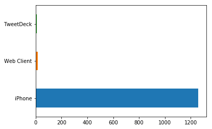

```python
# Histogram for value_counts of source column.

df_master_data['source'].value_counts().plot(kind='barh')
```

```python
# Percentage of usage each medium

per = df_master_data['source'].value_counts() / len(df_master_data) * 100

# Printing the percentages

print(per)
```

```
iPhone        98.052960
Web Client     1.246106
TweetDeck      0.700935
Name: source, dtype: float64
```

98.052 percent of tweets that are tweeted for rating dogs using iPhone.

From the above visualizations, most of tweets that are tweeted for rating dogs are done using iPhone. They prefer iPhone as a medium for rating dogs.

#### 2. Most common rating among all dogs?

```python
# Value_counts() for rating column.

df_master_data['rating'].value_counts()
```

```
1.0      297
1.2      286
1.1      248
1.3      157
0.9       96
0.8       63
0.7       34
0.6       22
0.5       18
1.4       18
0.3       13
0.4       11
0.2        5
0.1        3
14.4       1
6.0        1
2.7        1
7.5        1
16.5       1
4.5        1
20.4       1
42.0       1
2.4        1
8.8        1
177.6      1
4.4        1
14.3       1
Name: rating, dtype: int64
```

```
Text(0,0.5,'Rating of dog')
```

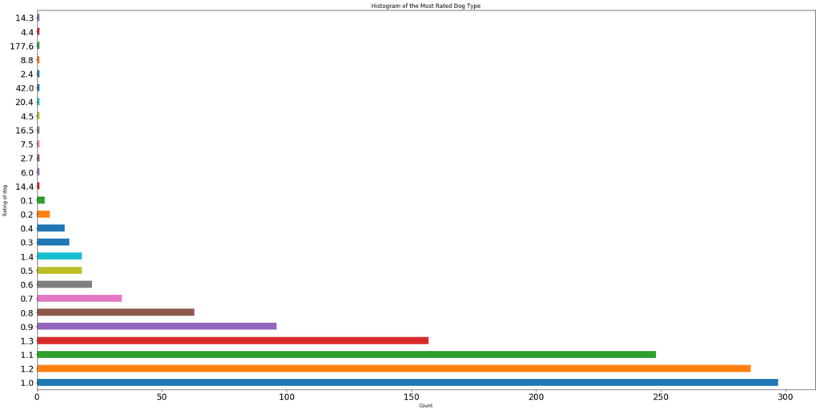

```python
# Bar graph for most common rated dog among all.

plt.figure(figsize=(30,15))
plt.rc('xtick', labelsize = 18)
plt.rc('ytick', labelsize = 18)
df_master_data['rating'].value_counts().plot(kind = 'barh')
plt.title('Histogram of the Most Rated Dog Type')
plt.xlabel('Count')
plt.ylabel('Rating of dog')
```

From the above, we observed that there are 297 dogs having most common rating of 1.0, then follows 1.2 rating for 286 dogs. Outlier is found in rating (177.6 and 42.0).

#### 3. Most common dog?

```python
# Value_counts() for name column.

df_master_data['dog'].value_counts()
```

```
golden retriever             94
pembroke                     65
labrador retriever           62
chihuahua                    44
pug                          39
pomeranian                   24
chow                         22
cocker spaniel               21
samoyed                      21
toy poodle                   20
french bulldog               18
malamute                     17
chesapeake bay retriever     15
seat belt                    13
eskimo dog                   12
shih-tzu                     12
beagle                       12
miniature pinscher           12
german shepherd              11
rottweiler                   11
teddy                        11
siberian husky               11
cardigan                     11
shetland sheepdog            11
staffordshire bullterrier    10
vizsla                        9
pekinese                      9
old english sheepdog          9
lakeland terrier              8
italian greyhound             8
                             ..
bee eater                     1
american black bear           1
koala                         1
skunk                         1
sundial                       1
padlock                       1
silky terrier                 1
dough                         1
lawn mower                    1
electric fan                  1
pitcher                       1
street sign                   1
wild boar                     1
quilt                         1
flamingo                      1
motor scooter                 1
african grey                  1
grey fox                      1
suit                          1
fire engine                   1
limousine                     1
desktop computer              1
axolotl                       1
african hunting dog           1
black-and-tan coonhound       1
african crocodile             1
long-horned beetle            1
hummingbird                   1
arabian camel                 1
trombone                      1
Name: dog, Length: 300, dtype: int64
```

The common dog count ranges from 1 to 94.

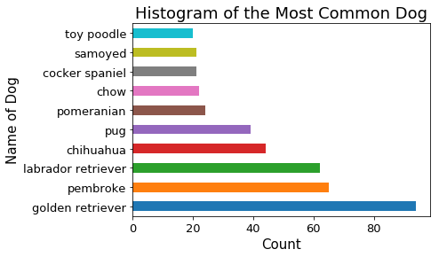

```python
# Histogram for most common dog.

plt.rc('xtick', labelsize = 13)
plt.rc('ytick', labelsize = 13)
plt.rc('axes', titlesize = 18)
plt.rc('axes', labelsize = 15)
common_dog = df_master_data.groupby('dog').filter(lambda x: len(x) >= 20)
common_dog['dog'].value_counts().plot(kind = 'barh')
plt.title('Histogram of the Most Common Dog')
plt.xlabel('Count')
plt.ylabel('Name of Dog')
plt.figure(figsize=(26,15))
```

From the above plots, the most common dog is golden retriever, then follows pembroke.

#### 4. Favorite_count vs Retweet_count?

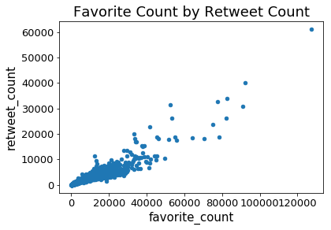

```python
# Scatterplot between favorite_count and retweet_count

df_master_data.plot(x = 'favorite_count', y = 'retweet_count', title = 'Favorite Count by Retweet Count', kind = 'scatter')
```

We can observe a positive linear relationship between favorite_count and retweet_count.

#### 5. Most popular dog based on favorite_count?

```python
# Creating a dataframe that contains top 10 popular dogs based on favorite_count.

df_fav_top10 = df_master_data.nlargest(10,'favorite_count')
```

```python
# Top 10 most popular dogs based on favorite_count.

df_fav_top10[['dog', 'favorite_count']]
```

|  | dog | favorite_count |
| --- | --- | --- |
| 232 | chihuahua | 127321 |
| 190 | standard poodle | 92117 |
| 85 | angora | 90891 |
| 897 | swing | 82473 |
| 61 | golden retriever | 82091 |
| 42 | chesapeake bay retriever | 78582 |
| 932 | bubble | 77594 |
| 78 | chow | 75003 |
| 154 | labrador retriever | 70688 |
| 4 | pomeranian | 64319 |

```
Text(0.5,1,'Top 10 Most Popular dogs based on favorite count')
```

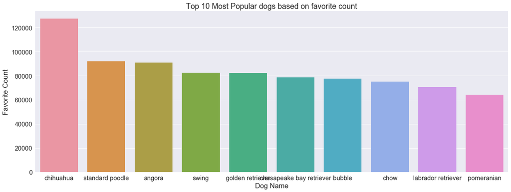

```python
# Bar plot for top 10 most popular dogs based on favorite_count.

sns.set(font_scale=1.5);
ax = plt.subplots(figsize=(20, 7))
ax = sns.barplot(x = 'dog', y = 'favorite_count', data = df_fav_top10)
plt.xlabel('Dog Name')
plt.ylabel('Favorite Count')
plt.title('Top 10 Most Popular dogs based on favorite count')
```

The most popular dog based on favorite count is chihuahua.

#### 6. Least popular dog based on favorite_count?

```python
# Creating a dataframe that contains least 10 popular dogs based on favorite_count.

df_fav_least10 = df_master_data.nsmallest(10,'favorite_count')
```

```python
# Least 10 popular dogs based on favorite_count.

df_fav_least10[['dog', 'favorite_count']]
```

|  | dog | favorite_count |
| --- | --- | --- |
| 1275 | english setter | 80 |
| 1273 | desktop computer | 101 |
| 1266 | black-and-tan coonhound | 107 |
| 1279 | miniature poodle | 111 |
| 1265 | toy terrier | 124 |
| 1283 | redbone | 127 |
| 1278 | gordon setter | 145 |
| 1276 | lhasa | 152 |
| 1262 | chesapeake bay retriever | 164 |
| 1263 | pembroke | 164 |

```
Text(0.5,1,'Least 10 Popular dogs based on favorite count')
```

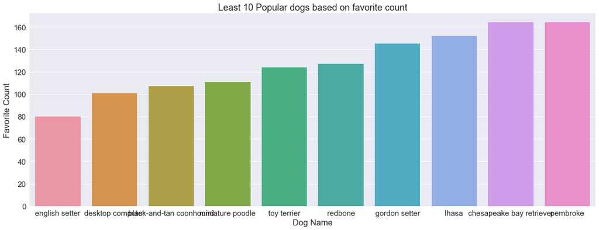

```python
# Bar plot for least 10 most popular dogs based on favorite_count.

sns.set(font_scale=1.5);
ax = plt.subplots(figsize=(20, 7))
ax = sns.barplot(x = 'dog', y = 'favorite_count', data = df_fav_least10)
plt.xlabel('Dog Name')
plt.ylabel('Favorite Count')
plt.title('Least 10 Popular dogs based on favorite count')
```

The least popular dog based on favorite_count is english setter.

#### 7. Most popular dog based on retweet_count?

```python
# Creating a dataframe that contains top 10 popular dogs based on retweet_count.

df_retweet_fav10 = df_master_data.nlargest(10,'retweet_count')
```

```python
# Top 10 most popular dogs based on retweet_count.

df_retweet_fav10[['dog', 'retweet_count']]
```

|  | dog | retweet_count |
| --- | --- | --- |
| 232 | chihuahua | 61115 |
| 190 | standard poodle | 40140 |
| 897 | swing | 33878 |
| 932 | bubble | 32735 |
| 384 | gondola | 31497 |
| 85 | angora | 30876 |
| 265 | golden retriever | 26260 |
| 61 | golden retriever | 26158 |
| 78 | chow | 23654 |
| 501 | labrador retriever | 22888 |

```
Text(0.5,1,'Top 10 Popular dogs based on retweet count')
```

[figure not shown]

```python
# Bar plot for top 10 most popular dogs based on retweet_count.

sns.set(font_scale=1.5);
ax = plt.subplots(figsize=(20, 7))
ax = sns.barplot(x = 'dog', y = 'favorite_count', data = df_retweet_fav10)
plt.xlabel('Dog Name')
plt.ylabel('Retweet Count')
plt.title('Top 10 Popular dogs based on retweet count')
```

The most popular dog based on retweet_count is chihuahua.

#### 8. Least popular dog based on retweet_count?

```python
# Creating a dataframe that contains least 10 popular dogs based on retweet_count.

df_retweet_least10 = df_master_data.nsmallest(10,'retweet_count')
```

```python
# Least 10 most popular dogs based on retweet_count.

df_retweet_least10[['dog', 'retweet_count']]
```

|  | dog | retweet_count |
| --- | --- | --- |
| 1275 | english setter | 12 |
| 1196 | web site | 32 |
| 1273 | desktop computer | 35 |
| 1266 | black-and-tan coonhound | 40 |
| 1111 | dandie dinmont | 44 |
| 1186 | crash helmet | 44 |
| 1265 | toy terrier | 45 |
| 1260 | german shepherd | 47 |
| 1283 | redbone | 47 |
| 1249 | jigsaw puzzle | 48 |

```
Text(0.5,1,'Least 10 Popular dogs based on retweet count')
```

[figure not shown]

```python
# Bar plot for least 10 popular dogs based on retweet_count.

sns.set(font_scale=1.5);
ax = plt.subplots(figsize=(20, 7))
ax = sns.barplot(x = 'dog', y = 'favorite_count', data = df_retweet_least10)
plt.xlabel('Dog Name')
plt.ylabel('Retweet Count')
plt.title('Least 10 Popular dogs based on retweet count')
```

The least popular dog based on retweet_count is english setter.

#### 9. Retweets and favorites over time?

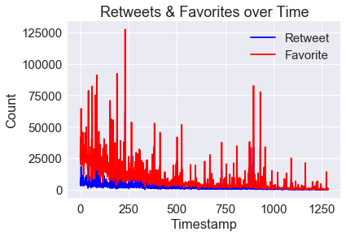

```python
# Plot between retweets and favorites over time.

df_master_data['retweet_count'].plot(color = 'blue', label='Retweet')
df_master_data['favorite_count'].plot(color = 'red', label='Favorite')
plt.xlabel('Timestamp')
plt.ylabel('Count')
plt.title('Retweets & Favorites over Time')
plt.legend(loc='upper right')
```

The above plot depicts that the favorite_count are greater than retweet_count over timestamp.

## References

1) https://stackoverflow.com/questions/12309269/how-do-i-write-json-data-to-a-file

2) https://stackoverflow.com/questions/19699367/unicodedecodeerror-utf-8-codec-cant-decode-byte